# acad_thesis_final

2023-04-18

```r
library(dplyr)
library(tidyverse)
library(epitab)
library(rstatix)
```

```r
library(ggplot2)
library(broom)
library(tableone)
library(oddsratio)
library(flextable)
library(gtsummary)
library(naniar)
```

## Importing and cleaning data

Raw CSV file used instead due to column misalignment in the first dataset.

```r
acad_data = read_csv(file = "./data/ACAD-202301-Columbia-Wei-20230331-raw.csv") %>%
  janitor::clean_names()
```

```r
acad_clean = acad_data %>%
  select(
    "acad_id", "age","degree", "gender", "country", "generation", "redcap_data_access_group", "arrival_year",

    "parta_a201", "parta_a202", "parta_a203", "parta_a204", "parta_a205", "parta_a206", "parta_a207", "parta_a208", "parta_a209", "parta_a210", "parta_a211", "parta_a212", "parta_a213", "parta_a214", "parta_a2score",

    "memory", "orient", "judgment", "commun", "homehobb", "perscare", "cdr_sum", "cdrglob",

    "bills", "taxes", "shopping", "games", "stove", "mealprep", "events", "payattn", "remdates", "travel", "fas",

    "ani_total", "veg_total",

    "clock1", "clock2", "clock3", "clock4", "clock5", "clock6", "clock7", "clock8", "clock9", "clock10", "clock11", "clock12", "clock13", "clock14", "clock15", "clock_t",

    "word1_t1", "word2_t1", "word3_t1", "word4_t1", "word5_t1", "word6_t1", "word7_t1", "word8_t1", "word9_t1", "word10_t1", "comt_t1","word1_t2", "word2_t2", "word3_t2", "word4_t2", "word5_t2", "word6_t2", "word7_t2", "word8_t2", "word9_t2", "word10_t2", "comt_t2", "word1_t3", "word2_t3", "word3_t3", "word4_t3", "word5_t3", "word6_t3", "word7_t3", "word8_t3", "word9_t3", "word10_t3", "comt_t3","word1_d", "word2_d", "word3_d", "word4_d", "word5_d", "word6_d", "word7_d", "word8_d", "word9_d", "word10_d", "comt_d", "item1", "item2", "item3", "item4", "item5", "item6", "item7", "item8", "item9", "item10", "word1_dr", "word2_dr", "word3_dr", "word4_dr", "word5_dr", "word6_dr", "word7_dr", "word8_dr","word9_dr", "word10_dr", "comt_dr",

    "casi_score", "casi2_score", "c14_overall", "c14_secg",

    "condition1", "condition2", "condition3", "condition4", "condition5", "condition6", "condition7", "condition8", "condition9", "condition10", "condition11", "condition12", "condition13", "condition14", "condition15"
  )
```

### Demographic Dataset

A dataset containing only demographic and covariate variables was created

```r
acad_dem = acad_clean %>%
  select("acad_id", "redcap_data_access_group", "age","degree", "gender", "country", "generation",  "arrival_year", "condition1", "condition2", "condition3", "condition4", "condition5", "condition6", "condition7", "condition8", "condition9", "condition10", "condition11", "condition12", "condition13", "condition14", "condition15")
```

Calculating immigration years; condition variables renamed

```r
acad_dem = acad_dem %>%
  mutate(
  immigration_years = 2023 - arrival_year,

  hypertension = condition1,
  diabetes = condition2,
  cholesterol = condition3,
  myo_infarc = condition4,
  cong_heart_f = condition5,
  stroke = condition6,
  head_injury = condition7,
  seizure = condition8,
  hiv = condition9,
  sleep_apnea = condition10,
  sleep_disorder = condition11,
  other_cog = condition12,
  covid = condition13,
  vac_covid = condition14,
  kidney = condition15,
  ) %>%

  select(-arrival_year, -condition1, -condition2, -condition3, -condition4, -condition5, -condition6, -condition7, -condition8, -condition9, -condition10, -condition11, -condition12, -condition13, -condition14, -condition15)
```

Picking comorbidities:

```r
acad_dem%>%
  group_by(hypertension) %>%
  summarise(n_obs = n())
```

```
## # A tibble: 4 × 2
##   hypertension n_obs
##          <dbl> <int>
## 1            0   158
## 2            1   145
## 3           55     1
## 4           NA    27
```

```r
acad_dem %>%
  group_by(diabetes) %>%
  summarise(n_obs = n())
```

```
## # A tibble: 4 × 2
##   diabetes n_obs
##      <dbl> <int>
## 1        0   223
## 2        1    78
## 3       55     3
## 4       NA    27
```

```r
acad_dem %>%
  group_by(cholesterol) %>%
  summarise(n_obs = n())
```

```
## # A tibble: 4 × 2
##   cholesterol n_obs
##         <dbl> <int>
## 1           0   148
## 2           1   152
## 3          55     4
## 4          NA    27
```

```r
acad_dem %>%
  group_by(myo_infarc) %>%
  summarise(n_obs = n())
```

```
## # A tibble: 4 × 2
##   myo_infarc n_obs
##        <dbl> <int>
## 1          0   282
## 2          1    21
## 3         55     1
## 4         NA    27
```

```r
acad_dem %>%
  group_by(cong_heart_f) %>%
  summarise(n_obs = n())
```

```
## # A tibble: 4 × 2
##   cong_heart_f n_obs
##          <dbl> <int>
## 1            0   293
## 2            1     8
## 3           55     3
## 4           NA    27
```

```r
acad_dem %>%
  group_by(stroke) %>%
  summarise(n_obs = n())
```

```
## # A tibble: 4 × 2
##   stroke n_obs
##    <dbl> <int>
## 1      0   286
## 2      1    16
## 3     55     2
## 4     NA    27
```

```r
acad_dem%>%
  group_by(head_injury) %>%
  summarise(n_obs = n())
```

```
## # A tibble: 4 × 2
##   head_injury n_obs
##         <dbl> <int>
## 1           0   282
## 2           1    20
## 3          55     2
## 4          NA    27
```

```r
acad_dem %>%
  group_by(seizure) %>%
  summarise(n_obs = n())
```

```
## # A tibble: 4 × 2
##   seizure n_obs
##     <dbl> <int>
## 1       0   296
## 2       1     7
## 3      55     1
## 4      NA    27
```

```r
acad_dem %>%
  group_by(hiv) %>%
  summarise(n_obs = n())
```

```
## # A tibble: 2 × 2
##     hiv n_obs
##   <dbl> <int>
## 1     0   304
## 2    NA    27
```

```r
acad_dem %>%
  group_by(sleep_apnea) %>%
  summarise(n_obs = n())
```

```
## # A tibble: 4 × 2
##   sleep_apnea n_obs
##         <dbl> <int>
## 1           0   267
## 2           1    34
## 3          55     3
## 4          NA    27
```

```r
acad_dem %>%
  group_by(sleep_disorder) %>%
  summarise(n_obs = n())
```

```
## # A tibble: 4 × 2
##   sleep_disorder n_obs
##            <dbl> <int>
## 1              0   301
## 2              1     2
## 3             55     1
## 4             NA    27
```

```r
acad_dem %>%
  group_by(other_cog) %>%
  summarise(n_obs = n())
```

```
## # A tibble: 4 × 2
##   other_cog n_obs
##       <dbl> <int>
## 1         0   252
## 2         1    51
## 3        55     1
## 4        NA    27
```

```r
acad_dem %>%
  group_by(covid) %>%
  summarise(n_obs = n())
```

```
## # A tibble: 4 × 2
##   covid n_obs
##   <dbl> <int>
## 1     0   276
## 2     1    27
## 3    55     1
## 4    NA    27
```

```r
acad_dem %>%
  group_by(vac_covid) %>%
  summarise(n_obs = n())
```

```
## # A tibble: 3 × 2
##   vac_covid n_obs
##       <dbl> <int>
## 1         0    12
## 2         1   292
## 3        NA    27
```

```r
acad_dem %>%
  group_by(kidney) %>%
  summarise(n_obs = n())
```

```
## # A tibble: 4 × 2
##   kidney n_obs
##    <dbl> <int>
## 1      0   157
## 2      1     2
## 3     55     1
## 4     NA   171
```

Selected the cardiovascular comorbidities (cholesterol, hypertension, diabetes, myo_infarc, cong_heart_f, stroke). Created cardiovascular risk score from comorbidities.

```r
acad_dem = acad_dem %>%
  select(-head_injury, -seizure, -hiv, -sleep_apnea, -sleep_disorder, -other_cog, -covid, -vac_covid, -kidney)

  acad_dem = acad_dem %>%
    replace_with_na(replace = list (
      cholesterol = c("55"),
      hypertension = c("55"),
      diabetes = c("55"),
      myo_infarc = c("55"),
      cong_heart_f = c("55"),
      stroke = c("55")
    )) %>%
  mutate(
    cardiovascular_risk = cholesterol + hypertension + diabetes + myo_infarc + cong_heart_f + stroke
  ) %>%
  mutate(
    cholesterol = factor(cholesterol, labels = c("No", "Yes")),
    hypertension = factor(hypertension, labels = c("No", "Yes")),
    diabetes = factor(diabetes, labels = c("No", "Yes")),
    myo_infarc = factor(myo_infarc, labels = c("No", "Yes")),
    cong_heart_f = factor(cong_heart_f, labels = c("No", "Yes")),
    stroke = factor(stroke, labels = c("No", "Yes")))
```

Remove participants with no information other than ACAD ID or recruitment site (n = 22)

```r
acad_dem <- acad_dem[!rowSums(is.na(acad_dem[, -c(1,2)])) == (ncol(acad_dem) -2),]
```

### Dietary Dataset

```r
acad_diet = acad_clean %>%
  select("acad_id","parta_a201", "parta_a202", "parta_a203", "parta_a204", "parta_a205", "parta_a206", "parta_a207", "parta_a208", "parta_a209", "parta_a210", "parta_a211", "parta_a212", "parta_a213", "parta_a214", "parta_a2score") %>%
  mutate(
  medi_score = as.factor(ifelse(parta_a2score < 5, "low",
                           ifelse(parta_a2score < 10, "middle",
                         "high"))),
  medi_score = factor(medi_score, levels = c("low", "middle", "high"))) %>%
  select("acad_id", "parta_a2score", "medi_score", everything())
```

Remove participants with no dietary information

```r
acad_diet = acad_diet %>%
  drop_na(parta_a2score)
```

*Removed participants with parta_a2score = 0 since those participants had NA for all parta_a2 questions

(n total = 27)

```r
acad_diet = acad_diet %>%
  filter(, parta_a2score != 0 )
```

#### Distribution of parta_a2score

Histogram of parta_a2score - since nicely distributed, no need to log transform

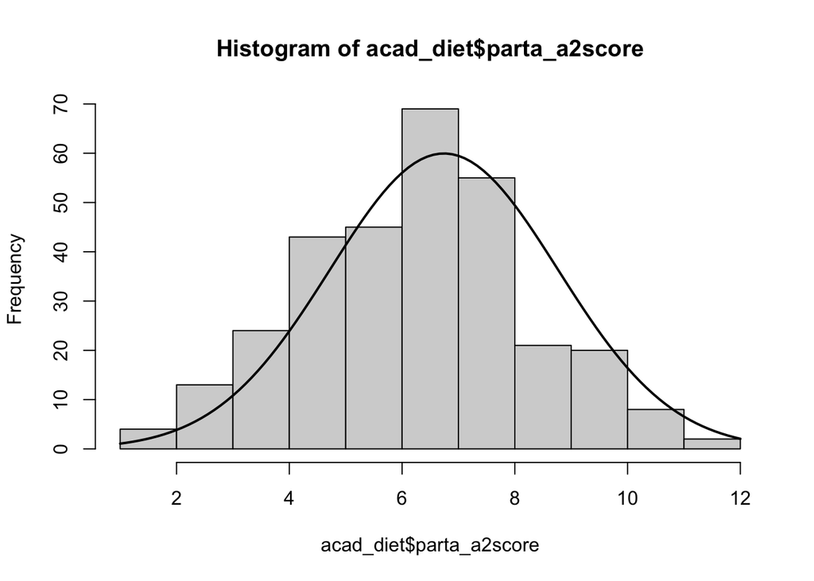

```r
hist_acad_diet_1 = hist(acad_diet$parta_a2score)
x_values = seq(min(acad_diet$parta_a2score), max(acad_diet$parta_a2score), length = 100)
y_values = dnorm(x_values, mean = mean(acad_diet$parta_a2score), sd = sd(acad_diet$parta_a2score))
y_values = y_values * diff(hist_acad_diet_1$mids[1:2]) * length(acad_diet$parta_a2score)

lines(x_values, y_values, lwd = 2)
```

Histogram of Medi Score

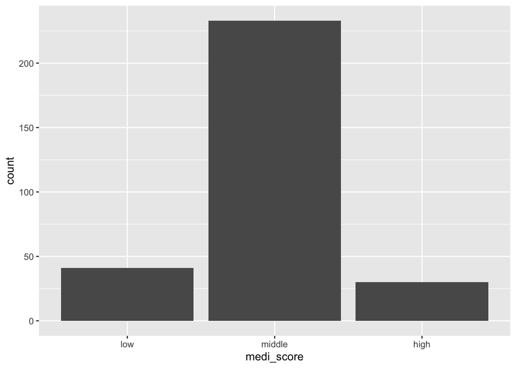

```r
acad_diet %>%
  ggplot(aes(x = medi_score)) +
  geom_bar()
```

### Cognitive Dataset

```r
acad_cog = acad_clean %>%
  select(
    "acad_id", "cdr_sum", "cdrglob", "fas", "ani_total", "veg_total","clock_t", "comt_t1","comt_t2", "comt_t3","comt_d", "comt_dr", "casi_score", "casi2_score", "c14_overall", "c14_secg"
  ) %>%

  mutate(
  cft = ani_total + veg_total,

  casi_score = ifelse(is.na(casi_score), 0, casi_score),
  casi2_score = ifelse(is.na(casi2_score), 0, casi2_score),
  casi_total = casi_score + casi2_score,
  casi_total = replace(casi_total, casi_total == 0, NA),

  comt_total = comt_t1 + comt_t2 + comt_t3 + comt_d,
  comt_total = ifelse(comt_total == 0, NA, comt_total
  ))%>%

  select(
"acad_id", "cdr_sum", "cdrglob", "fas","cft","clock_t", "comt_total", "comt_dr", "casi_total", "c14_overall", "c14_secg"
  )
```

Removing participants with zero entries for cognitive measures (only participants with at least one entry for a cognitive measure is included) (n = 22)

```r
acad_cog = acad_cog %>%
  mutate(
  cog_sum = rowSums(acad_cog[,c("cdr_sum", "cdrglob", "fas", "cft", "clock_t", "comt_total", "comt_dr", "casi_total", "c14_overall", "c14_secg")], na.rm = TRUE)
  )

acad_cog = acad_cog %>%
  filter(, cog_sum != 0) %>%
  select(-cog_sum)
```

#### CASI distribution

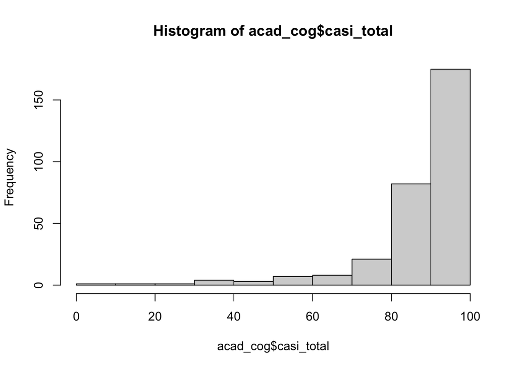

```r
hist_acad_cog_1 = hist(acad_cog$casi_total)
```

Heavy left skew distribution; must log transform to create tertiles

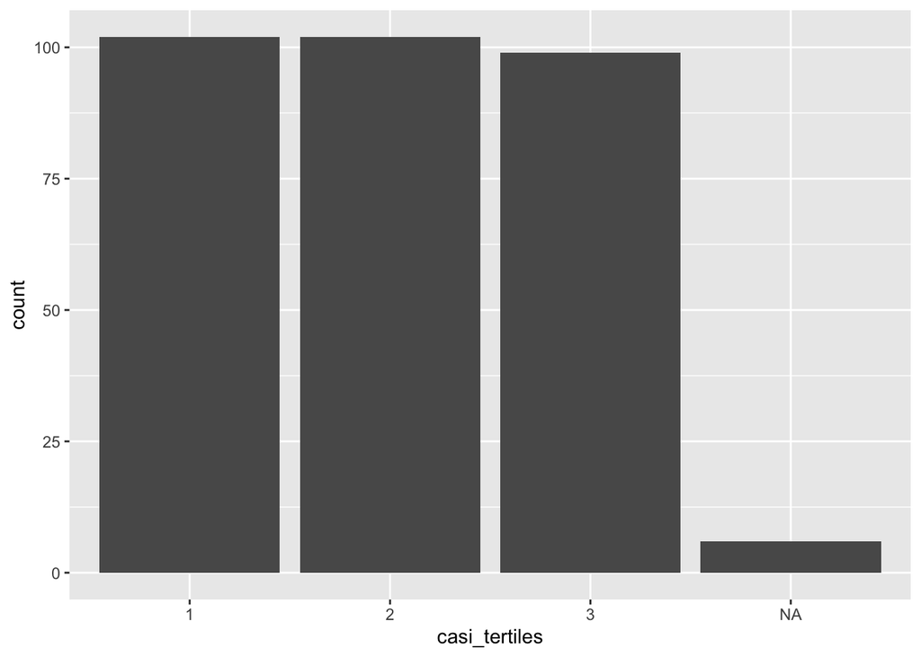

```r
acad_cog = acad_cog %>%
  mutate(
    casi_tertiles = cut(log(casi_total),
                        breaks = quantile(log(casi_total),
                                          probs = seq(0, 1, 1/3),
                                          na.rm = TRUE),
                        labels = c("1", "2", "3"),
                        include.lowest = TRUE,
                        include.highest = TRUE)
  )

acad_cog %>%
  ggplot(aes(x = casi_tertiles)) +
  geom_bar()
```

#### COMT distribution

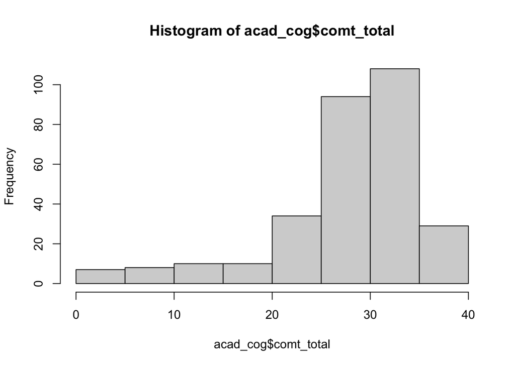

```r
hist_acad_cog_2 = hist(acad_cog$comt_total)
```

Heavy left skew distribution; must log transform to create tertiles

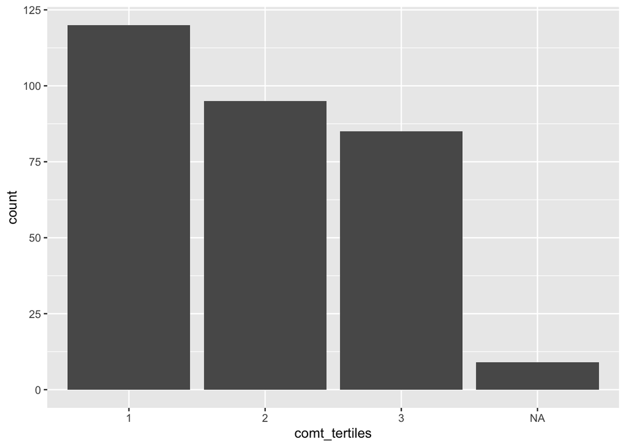

```r
acad_cog = acad_cog %>%
  mutate(
    comt_tertiles = cut(log(comt_total),
                        breaks = quantile(log(comt_total),
                                          probs = seq(0, 1, 1/3),
                                          na.rm = TRUE),
                        labels = c("1", "2", "3"),
                        include.lowest = TRUE,
                        include.highest = TRUE)
  )

acad_cog %>%
  ggplot(aes(x = comt_tertiles)) +
  geom_bar()
```

### Merging all datasets

```r
dem_diet = inner_join(acad_dem, acad_diet, by = "acad_id")
thesis_final = inner_join(dem_diet, acad_cog, by = "acad_id")
```

Adding labels to final dataset and relabelling c14_overall

```r
thesis_final = thesis_final %>%
  mutate(
    degree = factor(degree, labels = c("Grade school or less",
                                       "Some high school",
                                       "High school or G.E.D.",
                                       "Some college or technical school",
                                       "College graduate (Bachelor's degree)",
                                       "Graduate degree (Master's, Doctoral, or Professional degree)"))


,
    gender = factor(gender, labels = c("Male",
                                       "Female")),
    country = as.character(country),
    country = recode(country,
                       "156" = "China",
                       "410" = "Other",
                       "124" = "Other",
                       "344" = "Hong Kong",
                       "158" = "Other",
                       "360" = "Other",
                       "458" = "Other",
                       "888" = "Other",
                       "704" = "Other" ),

    casi_tertiles = factor(casi_tertiles, labels = c(
      "Low", "Medium", "High"
      )),
    casi_tertiles = factor(casi_tertiles, levels = c(
      "Low", "Medium", "High"
      )),
    comt_tertiles = factor(comt_tertiles, labels = c(
      "Low", "Medium", "High"
      )),
    comt_tertiles = factor(comt_tertiles, levels = c(
      "Low", "Medium", "High"
      )),
    c14_relabels = case_when(
      c14_overall == 1 ~ 0,
      c14_overall %in% c(5, 6) ~ 1,
      c14_overall %in% c(2, 3, 4) ~ 2
    ),
    c14_secg = factor(c14_secg, labels = c(
      "No Dementia (includes MCI and SCC)",
      "Dementia (NACC)"))
  ) %>%
  select(-c14_overall) %>%
  mutate(
    c14_overall = factor(c14_relabels, labels = c(
      "Normal",
      "MCI",
      "Dementia"
    ))
  ) %>%
  select(-c14_relabels)

skimr::skim(thesis_final)
```

Data summary

| Name | thesis_final |
| --- | --- |
| Number of rows | 303 |
| Number of columns | 43 |
| _______________________ |  |
| Column type frequency: |  |
| character | 3 |
| factor | 13 |
| numeric | 27 |
| ________________________ |  |
| Group variables | None |

**Variable type: character**

| skim_variable | n_missing | complete_rate | min | max | empty | n_unique | whitespace |
| --- | --- | --- | --- | --- | --- | --- | --- |
| acad_id | 0 | 1 | 8 | 8 | 0 | 303 | 0 |
| redcap_data_access_group | 0 | 1 | 3 | 7 | 0 | 2 | 0 |
| country | 0 | 1 | 5 | 9 | 0 | 3 | 0 |

**Variable type: factor**

| skim_variable | n_missing | complete_rate | ordered | n_unique | top_counts |
| --- | --- | --- | --- | --- | --- |
| degree | 0 | 1.00 | FALSE | 6 | Col: 91, Som: 69, Hig: 66, Som: 30 |
| gender | 0 | 1.00 | FALSE | 2 | Fem: 208, Mal: 95 |
| hypertension | 6 | 0.98 | FALSE | 2 | No: 157, Yes: 140 |
| diabetes | 8 | 0.97 | FALSE | 2 | No: 220, Yes: 75 |
| cholesterol | 9 | 0.97 | FALSE | 2 | No: 147, Yes: 147 |
| myo_infarc | 6 | 0.98 | FALSE | 2 | No: 277, Yes: 20 |
| cong_heart_f | 8 | 0.97 | FALSE | 2 | No: 287, Yes: 8 |
| stroke | 7 | 0.98 | FALSE | 2 | No: 281, Yes: 15 |
| medi_score | 0 | 1.00 | FALSE | 3 | mid: 232, low: 41, hig: 30 |
| c14_secg | 43 | 0.86 | FALSE | 2 | No : 232, Dem: 28 |
| casi_tertiles | 6 | 0.98 | FALSE | 3 | Med: 100, Low: 99, Hig: 98 |
| comt_tertiles | 8 | 0.97 | FALSE | 3 | Low: 117, Med: 93, Hig: 85 |
| c14_overall | 43 | 0.86 | FALSE | 3 | Nor: 147, MCI: 85, Dem: 28 |

**Variable type: numeric**

| skim_variable | n_missing | complete_rate | mean | sd | p0 | p25 | p50 | p75 | p100 | hist |
| --- | --- | --- | --- | --- | --- | --- | --- | --- | --- | --- |
| age | 0 | 1.00 | 73.69 | 8.11 | 60.0 | 67.0 | 73.0 | 79.0 | 101 | ▇▇▅▂▁ |
| generation | 0 | 1.00 | 1.01 | 0.18 | 1.0 | 1.0 | 1.0 | 1.0 | 4 | ▇▁▁▁▁ |
| immigration_years | 120 | 0.60 | 25.97 | 13.20 | 3.0 | 17.0 | 24.0 | 33.0 | 103 | ▇▇▂▁▁ |
| cardiovascular_risk | 19 | 0.94 | 1.35 | 1.15 | 0.0 | 0.0 | 1.0 | 2.0 | 5 | ▇▃▂▁▁ |
| parta_a2score | 0 | 1.00 | 6.74 | 2.03 | 1.0 | 5.0 | 7.0 | 8.0 | 12 | ▁▅▇▅▂ |
| parta_a201 | 1 | 1.00 | 0.27 | 0.45 | 0.0 | 0.0 | 0.0 | 1.0 | 1 | ▇▁▁▁▃ |
| parta_a202 | 0 | 1.00 | 0.09 | 0.28 | 0.0 | 0.0 | 0.0 | 0.0 | 1 | ▇▁▁▁▁ |
| parta_a203 | 0 | 1.00 | 0.75 | 0.43 | 0.0 | 1.0 | 1.0 | 1.0 | 1 | ▂▁▁▁▇ |
| parta_a204 | 0 | 1.00 | 0.53 | 0.50 | 0.0 | 0.0 | 1.0 | 1.0 | 1 | ▇▁▁▁▇ |
| parta_a205 | 0 | 1.00 | 0.80 | 0.40 | 0.0 | 1.0 | 1.0 | 1.0 | 1 | ▂▁▁▁▇ |
| parta_a206 | 0 | 1.00 | 0.28 | 0.45 | 0.0 | 0.0 | 0.0 | 1.0 | 1 | ▇▁▁▁▃ |
| parta_a207 | 0 | 1.00 | 0.75 | 0.44 | 0.0 | 0.0 | 1.0 | 1.0 | 1 | ▃▁▁▁▇ |
| parta_a208 | 0 | 1.00 | 0.02 | 0.13 | 0.0 | 0.0 | 0.0 | 0.0 | 1 | ▇▁▁▁▁ |
| parta_a209 | 0 | 1.00 | 0.50 | 0.50 | 0.0 | 0.0 | 1.0 | 1.0 | 1 | ▇▁▁▁▇ |
| parta_a210 | 0 | 1.00 | 0.40 | 0.49 | 0.0 | 0.0 | 0.0 | 1.0 | 1 | ▇▁▁▁▆ |
| parta_a211 | 0 | 1.00 | 0.45 | 0.50 | 0.0 | 0.0 | 0.0 | 1.0 | 1 | ▇▁▁▁▆ |
| parta_a212 | 0 | 1.00 | 0.60 | 0.49 | 0.0 | 0.0 | 1.0 | 1.0 | 1 | ▆▁▁▁▇ |
| parta_a213 | 0 | 1.00 | 0.41 | 0.49 | 0.0 | 0.0 | 0.0 | 1.0 | 1 | ▇▁▁▁▆ |
| parta_a214 | 0 | 1.00 | 0.89 | 0.31 | 0.0 | 1.0 | 1.0 | 1.0 | 1 | ▁▁▁▁▇ |
| cdr_sum | 0 | 1.00 | 1.16 | 3.19 | 0.0 | 0.0 | 0.0 | 0.5 | 18 | ▇▁▁▁▁ |
| cdrglob | 3 | 0.99 | 0.24 | 0.56 | 0.0 | 0.0 | 0.0 | 0.5 | 3 | ▇▁▁▁▁ |
| fas | 1 | 1.00 | 3.03 | 6.76 | 0.0 | 0.0 | 0.0 | 2.0 | 30 | ▇▁▁▁▁ |
| cft | 2 | 0.99 | 24.98 | 7.94 | 0.0 | 21.0 | 26.0 | 30.0 | 44 | ▁▂▇▇▁ |
| clock_t | 2 | 0.99 | 12.25 | 3.64 | 0.0 | 10.0 | 14.0 | 15.0 | 15 | ▁▁▂▂▇ |
| comt_total | 8 | 0.97 | 28.32 | 7.57 | 1.0 | 26.0 | 30.0 | 33.0 | 40 | ▁▁▁▇▅ |
| comt_dr | 3 | 0.99 | 19.15 | 3.13 | 0.0 | 20.0 | 20.0 | 20.0 | 20 | ▁▁▁▁▇ |
| casi_total | 6 | 0.98 | 87.42 | 13.66 | 9.9 | 86.5 | 91.4 | 95.0 | 100 | ▁▁▁▁▇ |

```r
write.csv(thesis_final, "thesis_final.csv", row.names = FALSE)
```

Final cleaned dataset is comprised of 303 observations and 43 variables - 3 character, 13 factor, and 27 numeric.

## Data Analysis

Exposure variables: * medi_score

Outcome variables: * casi_total * comt_total

Secondary outcome variables * c14_overall * c14_secg * cft * fas

Covariates: * age * recruitment site (redcap_data_access_group) * gender * immigration years * education level * cholesterol * hypertension * diabetes * cardiovascular_risk

### Summary Tables

#### Overall demographic and clinical characteristic table

```r
listVars1 = c("age", "redcap_data_access_group", "gender", "country", "immigration_years", "degree", "parta_a2score", "medi_score", "casi_total", "comt_total", "comt_dr", "fas","cft", "c14_overall", "c14_secg", "cholesterol", "hypertension", "diabetes", "cardiovascular_risk")

catVars = c("redcap_data_access_group", "gender", "country", "degree", "medi_score", "c14_overall", "c14_secg", "cholesterol", "hypertension", "diabetes")

table1 = CreateTableOne(vars = listVars1, data = thesis_final, factorVars = catVars)

print(table1, formatOption = list(big.mark = ","))
```

```
##
##                                                                   Overall
##   n                                                                 303
##   age (mean (SD))                                                 73.69 (8.11)
##   redcap_data_access_group = toronto (%)                            161 (53.1)
##   gender = Female (%)                                               208 (68.6)
##   country (%)
##      China                                                          256 (84.5)
##      Hong Kong                                                       27 ( 8.9)
##      Other                                                           20 ( 6.6)
##   immigration_years (mean (SD))                                   25.97 (13.20)
##   degree (%)
##      Grade school or less                                            27 ( 8.9)
##      Some high school                                                30 ( 9.9)
##      High school or G.E.D.                                           66 (21.8)
##      Some college or technical school                                69 (22.8)
##      College graduate (Bachelor's degree)                            91 (30.0)
##      Graduate degree (Master's, Doctoral, or Professional degree)    20 ( 6.6)
##   parta_a2score (mean (SD))                                        6.74 (2.03)
##   medi_score (%)
##      low                                                             41 (13.5)
##      middle                                                         232 (76.6)
##      high                                                            30 ( 9.9)
##   casi_total (mean (SD))                                          87.42 (13.66)
##   comt_total (mean (SD))                                          28.32 (7.57)
##   comt_dr (mean (SD))                                             19.15 (3.13)
##   fas (mean (SD))                                                  3.03 (6.76)
##   cft (mean (SD))                                                 24.98 (7.94)
##   c14_overall (%)
##      Normal                                                         147 (56.5)
##      MCI                                                             85 (32.7)
##      Dementia                                                        28 (10.8)
##   c14_secg = Dementia (NACC) (%)                                     28 (10.8)
##   cholesterol = Yes (%)                                             147 (50.0)
##   hypertension = Yes (%)                                            140 (47.1)
##   diabetes = Yes (%)                                                 75 (25.4)
##   cardiovascular_risk (mean (SD))                                  1.35 (1.15)
```

#### Demographic and clinical characteristics by Mediterranean diet score tertiles

- Did not include casi and comt tertiles

```r
listVars_2 = c("age", "redcap_data_access_group", "gender", "country", "immigration_years", "degree", "casi_total", "comt_total","comt_dr", "fas", "cft","c14_overall", "c14_secg",  "cholesterol", "hypertension", "diabetes", "cardiovascular_risk")

catVars = c("redcap_data_access_group", "gender", "country", "degree", "c14_overall", "c14_secg", "cholesterol", "hypertension", "diabetes")

table2 = CreateTableOne(vars = listVars_2, data = thesis_final, factorVars = catVars, strata = c("medi_score"))

print(table2, formatOptions = list(big.mark = ","))
```

```
##                                                                  Stratified by medi_score
##                                                                   low
##   n                                                                  41
##   age (mean (SD))                                                 72.98 (9.53)
##   redcap_data_access_group = toronto (%)                             24 (58.5)
##   gender = Female (%)                                                28 (68.3)
##   country (%)
##      China                                                           30 (73.2)
##      Hong Kong                                                        9 (22.0)
##      Other                                                            2 ( 4.9)
##   immigration_years (mean (SD))                                   25.76 (11.43)
##   degree (%)
##      Grade school or less                                             4 ( 9.8)
##      Some high school                                                 4 ( 9.8)
##      High school or G.E.D.                                            8 (19.5)
##      Some college or technical school                                11 (26.8)
##      College graduate (Bachelor's degree)                             8 (19.5)
##      Graduate degree (Master's, Doctoral, or Professional degree)     6 (14.6)
##   casi_total (mean (SD))                                          82.18 (21.94)
##   comt_total (mean (SD))                                          26.62 (9.62)
##   comt_dr (mean (SD))                                             18.27 (4.77)
##   fas (mean (SD))                                                  5.02 (9.57)
##   cft (mean (SD))                                                 24.38 (9.99)
##   c14_overall (%)
##      Normal                                                          19 (63.3)
##      MCI                                                              6 (20.0)
##      Dementia                                                         5 (16.7)
##   c14_secg = Dementia (NACC) (%)                                      6 (20.0)
##   cholesterol = Yes (%)                                              22 (57.9)
##   hypertension = Yes (%)                                             20 (51.3)
##   diabetes = Yes (%)                                                 13 (33.3)
##   cardiovascular_risk (mean (SD))                                  1.53 (1.08)
##                                                                  Stratified by medi_score
##                                                                   middle
##   n                                                                 232
##   age (mean (SD))                                                 73.88 (8.18)
##   redcap_data_access_group = toronto (%)                            121 (52.2)
##   gender = Female (%)                                               158 (68.1)
##   country (%)
##      China                                                          199 (85.8)
```

[output cut: 73 more lines]

```
##      Graduate degree (Master's, Doctoral, or Professional degree)
##   casi_total (mean (SD))                                           0.035
##   comt_total (mean (SD))                                           0.196
##   comt_dr (mean (SD))                                              0.140
##   fas (mean (SD))                                                  0.106
##   cft (mean (SD))                                                  0.804
##   c14_overall (%)                                                  0.480
##      Normal
##      MCI
##      Dementia
##   c14_secg = Dementia (NACC) (%)                                   0.141
##   cholesterol = Yes (%)                                            0.310
##   hypertension = Yes (%)                                           0.841
##   diabetes = Yes (%)                                               0.474
##   cardiovascular_risk (mean (SD))                                  0.405
```

#### Demographic, clinical, and dietary characteristics for subjects by casi tertiles

```r
listVars_3 = c("age", "redcap_data_access_group", "gender", "country", "immigration_years", "degree", "parta_a2score","medi_score", "comt_total", "comt_dr", "fas", "cft","c14_overall", "c14_secg", "cholesterol", "hypertension", "diabetes", "cardiovascular_risk")

catVars = c("redcap_data_access_group", "gender", "country", "degree", "medi_score", "c14_overall", "c14_secg", "cholesterol", "hypertension", "diabetes")

table3 = CreateTableOne(vars = listVars_3, data = thesis_final, factorVars = catVars, strata = c("casi_tertiles"))

print(table3, formatOptions = list(big.mark = ","))
```

```
##                                                                  Stratified by casi_tertiles
##                                                                   Low
##   n                                                                  99
##   age (mean (SD))                                                 77.18 (8.75)
##   redcap_data_access_group = toronto (%)                             51 (51.5)
##   gender = Female (%)                                                63 (63.6)
##   country (%)
##      China                                                           83 (83.8)
##      Hong Kong                                                        7 ( 7.1)
##      Other                                                            9 ( 9.1)
##   immigration_years (mean (SD))                                   27.02 (16.72)
##   degree (%)
##      Grade school or less                                            19 (19.2)
##      Some high school                                                12 (12.1)
##      High school or G.E.D.                                           26 (26.3)
##      Some college or technical school                                18 (18.2)
##      College graduate (Bachelor's degree)                            22 (22.2)
##      Graduate degree (Master's, Doctoral, or Professional degree)     2 ( 2.0)
##   parta_a2score (mean (SD))                                        6.75 (2.11)
##   medi_score (%)
##      low                                                             14 (14.1)
##      middle                                                          74 (74.7)
##      high                                                            11 (11.1)
##   comt_total (mean (SD))                                          22.56 (9.59)
##   comt_dr (mean (SD))                                             17.98 (4.44)
##   fas (mean (SD))                                                  6.77 (9.46)
##   cft (mean (SD))                                                 18.82 (7.43)
##   c14_overall (%)
##      Normal                                                          35 (38.5)
##      MCI                                                             31 (34.1)
##      Dementia                                                        25 (27.5)
##   c14_secg = Dementia (NACC) (%)                                     25 (27.5)
##   cholesterol = Yes (%)                                              54 (56.8)
##   hypertension = Yes (%)                                             54 (56.2)
##   diabetes = Yes (%)                                                 31 (32.3)
##   cardiovascular_risk (mean (SD))                                  1.58 (1.19)
##                                                                  Stratified by casi_tertiles
##                                                                   Medium
##   n                                                                 100
##   age (mean (SD))                                                 72.96 (7.52)
```

[output cut: 89 more lines]

```
##      middle
##      high
##   comt_total (mean (SD))                                          <0.001
##   comt_dr (mean (SD))                                             <0.001
##   fas (mean (SD))                                                 <0.001
##   cft (mean (SD))                                                 <0.001
##   c14_overall (%)                                                 <0.001
##      Normal
##      MCI
##      Dementia
##   c14_secg = Dementia (NACC) (%)                                  <0.001
##   cholesterol = Yes (%)                                            0.103
##   hypertension = Yes (%)                                           0.067
##   diabetes = Yes (%)                                               0.206
##   cardiovascular_risk (mean (SD))                                  0.029
```

#### Demographic, clinical, and dietary characteristics for subjects by comt tertiles

```r
listVars_4 = c("age", "redcap_data_access_group", "gender", "country", "immigration_years", "degree", "parta_a2score", "medi_score", "casi_total", "comt_dr", "fas", "cft", "c14_overall", "c14_secg", "cholesterol", "hypertension", "diabetes", "cardiovascular_risk")

catVars = c("redcap_data_access_group", "gender", "country", "degree", "medi_score", "c14_overall", "c14_secg", "cholesterol", "hypertension", "diabetes")

table4 = CreateTableOne(vars = listVars_4, data = thesis_final, factorVars = catVars, strata = c("comt_tertiles"))

print(table4, formatOptions = list(big.mark = ","))
```

```
##                                                                  Stratified by comt_tertiles
##                                                                   Low
##   n                                                                 117
##   age (mean (SD))                                                 76.73 (8.52)
##   redcap_data_access_group = toronto (%)                             70 (59.8)
##   gender = Female (%)                                                64 (54.7)
##   country (%)
##      China                                                           98 (83.8)
##      Hong Kong                                                       12 (10.3)
##      Other                                                            7 ( 6.0)
##   immigration_years (mean (SD))                                   26.99 (15.07)
##   degree (%)
##      Grade school or less                                            14 (12.0)
##      Some high school                                                11 ( 9.4)
##      High school or G.E.D.                                           25 (21.4)
##      Some college or technical school                                26 (22.2)
##      College graduate (Bachelor's degree)                            32 (27.4)
##      Graduate degree (Master's, Doctoral, or Professional degree)     9 ( 7.7)
##   parta_a2score (mean (SD))                                        6.50 (1.97)
##   medi_score (%)
##      low                                                             17 (14.5)
##      middle                                                          91 (77.8)
##      high                                                             9 ( 7.7)
##   casi_total (mean (SD))                                          81.65 (16.58)
##   comt_dr (mean (SD))                                             18.71 (3.27)
##   fas (mean (SD))                                                  5.12 (8.42)
##   cft (mean (SD))                                                 21.31 (8.23)
##   c14_overall (%)
##      Normal                                                          39 (36.4)
##      MCI                                                             45 (42.1)
##      Dementia                                                        23 (21.5)
##   c14_secg = Dementia (NACC) (%)                                     23 (21.5)
##   cholesterol = Yes (%)                                              65 (57.5)
##   hypertension = Yes (%)                                             68 (59.1)
##   diabetes = Yes (%)                                                 36 (31.3)
##   cardiovascular_risk (mean (SD))                                  1.65 (1.14)
##                                                                  Stratified by comt_tertiles
##                                                                   Medium
##   n                                                                  93
##   age (mean (SD))                                                 72.48 (7.42)
```

[output cut: 89 more lines]

```
##      middle
##      high
##   casi_total (mean (SD))                                          <0.001
##   comt_dr (mean (SD))                                             <0.001
##   fas (mean (SD))                                                 <0.001
##   cft (mean (SD))                                                 <0.001
##   c14_overall (%)                                                 <0.001
##      Normal
##      MCI
##      Dementia
##   c14_secg = Dementia (NACC) (%)                                  <0.001
##   cholesterol = Yes (%)                                            0.081
##   hypertension = Yes (%)                                           0.001
##   diabetes = Yes (%)                                               0.162
##   cardiovascular_risk (mean (SD))                                  0.001
```

### Graphs

#### Casi score by age

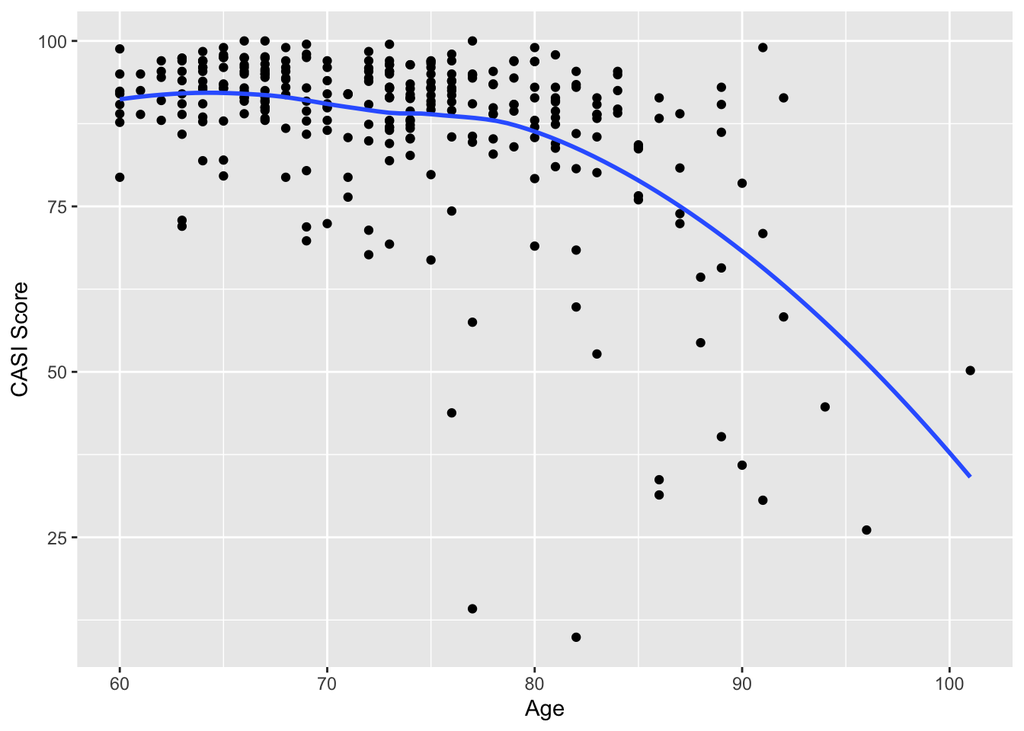

```r
thesis_final %>%
  ggplot(aes(x = age, y = casi_total)) +
  geom_point() +
  stat_smooth(method = "loess", se = FALSE) +
  labs (
    x = "Age",
    y = "CASI Score"
  )
```

#### Comt score by age

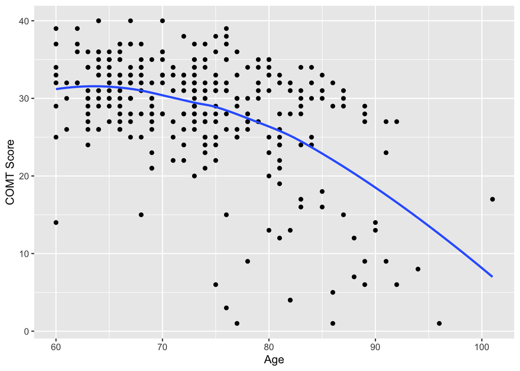

```r
thesis_final %>%
  ggplot(aes(x = age, y = comt_total)) +
  geom_point() +
  stat_smooth(method = "loess", se = FALSE) +
  labs (
    x = "Age",
    y = "COMT Score"
  )
```

### Cognitive score by MeDi tertiles

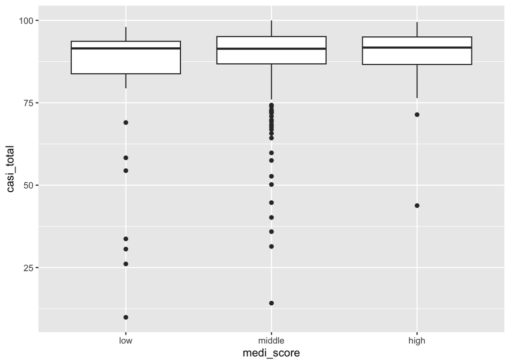

```r
thesis_final %>%
  ggplot(aes(x = medi_score, y = casi_total)) +
  geom_boxplot()
```

### Cross sectional analysis

Covariates: * age * recruitment site (redcap_data_access_group) * gender * immigration years * education level * cholesterol * hypertension * diabetes

#### Linear regression

Linear regression between casi_total and medi_score

```r
#crude
linear1 = lm(casi_total ~ medi_score, data = thesis_final)
summary(linear1)
```

```
##
## Call:
## lm(formula = casi_total ~ medi_score, data = thesis_final)
##
## Residuals:
##     Min      1Q  Median      3Q     Max
## -73.931  -1.631   3.369   7.569  15.815
##
## Coefficients:
##                  Estimate Std. Error t value Pr(>|t|)
## (Intercept)        82.185      2.170  37.875   <2e-16 ***
## medi_scoremiddle    5.946      2.348   2.532   0.0119 *
## medi_scorehigh      6.629      3.291   2.014   0.0449 *
## ---
## Signif. codes:  0 '***' 0.001 '**' 0.01 '*' 0.05 '.' 0.1 ' ' 1
##
## Residual standard error: 13.55 on 294 degrees of freedom
##   (6 observations deleted due to missingness)
## Multiple R-squared:  0.0225, Adjusted R-squared:  0.01585
## F-statistic: 3.383 on 2 and 294 DF,  p-value: 0.03528
```

```r
tbl_regression(linear1)
```

| **Characteristic** | **Beta** | **95% CI**<sup>1</sup> | **p-value** |
| --- | --- | --- | --- |
| medi_score |  |  |  |
| low | — | — |  |
| middle | 5.9 | 1.3, 11 | 0.012 |
| high | 6.6 | 0.15, 13 | 0.045 |

<sup>1</sup> CI = Confidence Interval

```r
#model 1: age, gender, degree
linear1_model_1 = lm(casi_total ~ medi_score + age + gender + degree, data = thesis_final)
summary(linear1_model_1)
```

```
##
## Call:
## lm(formula = casi_total ~ medi_score + age + gender + degree,
##     data = thesis_final)
##
## Residuals:
##     Min      1Q  Median      3Q     Max
## -67.733  -3.661   1.838   6.408  19.102
##
## Coefficients:
##                                                                     Estimate
## (Intercept)                                                        122.82883
## medi_scoremiddle                                                     6.02618
## medi_scorehigh                                                       6.24116
## age                                                                 -0.73196
## genderFemale                                                         1.97520
## degreeSome high school                                               7.46367
## degreeHigh school or G.E.D.                                         11.38021
## degreeSome college or technical school                              12.87367
## degreeCollege graduate (Bachelor's degree)                          15.67662
## degreeGraduate degree (Master's, Doctoral, or Professional degree)  13.63026
##                                                                    Std. Error
## (Intercept)                                                           7.06364
## medi_scoremiddle                                                      1.99448
## medi_scorehigh                                                        2.77989
## age                                                                   0.08389
## genderFemale                                                          1.47175
## degreeSome high school                                                3.10243
## degreeHigh school or G.E.D.                                           2.64569
## degreeSome college or technical school                                2.63019
## degreeCollege graduate (Bachelor's degree)                            2.54626
## degreeGraduate degree (Master's, Doctoral, or Professional degree)    3.45093
##                                                                    t value
## (Intercept)                                                         17.389
## medi_scoremiddle                                                     3.021
## medi_scorehigh                                                       2.245
## age                                                                 -8.725
## genderFemale                                                         1.342
## degreeSome high school                                               2.406
## degreeHigh school or G.E.D.                                          4.301
## degreeSome college or technical school                               4.895
## degreeCollege graduate (Bachelor's degree)                           6.157
## degreeGraduate degree (Master's, Doctoral, or Professional degree)   3.950
##                                                                    Pr(>|t|)
## (Intercept)                                                         < 2e-16 ***
## medi_scoremiddle                                                    0.00274 **
## medi_scorehigh                                                      0.02552 *
## age                                                                 < 2e-16 ***
## genderFemale                                                        0.18063
## degreeSome high school                                              0.01677 *
## degreeHigh school or G.E.D.                                        2.33e-05 ***
## degreeSome college or technical school                             1.65e-06 ***
## degreeCollege graduate (Bachelor's degree)                         2.50e-09 ***
## degreeGraduate degree (Master's, Doctoral, or Professional degree) 9.85e-05 ***
## ---
## Signif. codes:  0 '***' 0.001 '**' 0.01 '*' 0.05 '.' 0.1 ' ' 1
##
## Residual standard error: 11.37 on 287 degrees of freedom
##   (6 observations deleted due to missingness)
## Multiple R-squared:  0.3282, Adjusted R-squared:  0.3071
## F-statistic: 15.58 on 9 and 287 DF,  p-value: < 2.2e-16
```

```r
tbl_regression(linear1_model_1)
```

| **Characteristic** | **Beta** | **95% CI**<sup>1</sup> | **p-value** |
| --- | --- | --- | --- |
| medi_score |  |  |  |
| low | — | — |  |
| middle | 6.0 | 2.1, 10 | 0.003 |
| high | 6.2 | 0.77, 12 | 0.026 |
| age | -0.73 | -0.90, -0.57 | <0.001 |
| gender |  |  |  |
| Male | — | — |  |
| Female | 2.0 | -0.92, 4.9 | 0.2 |
| degree |  |  |  |
| Grade school or less | — | — |  |
| Some high school | 7.5 | 1.4, 14 | 0.017 |
| High school or G.E.D. | 11 | 6.2, 17 | <0.001 |
| Some college or technical school | 13 | 7.7, 18 | <0.001 |
| College graduate (Bachelor's degree) | 16 | 11, 21 | <0.001 |
| Graduate degree (Master's, Doctoral, or Professional degree) | 14 | 6.8, 20 | <0.001 |

<sup>1</sup> CI = Confidence Interval

```r
#model 2: age, gender, degree, redcap_data_access_group, immigration_years, cholesterol, diabetes, hypertension
linear1_model_2 = lm(casi_total ~ medi_score + age + redcap_data_access_group + gender + immigration_years + degree + cholesterol + hypertension + diabetes, data = thesis_final)
summary(linear1_model_2)
```

```
##
## Call:
## lm(formula = casi_total ~ medi_score + age + redcap_data_access_group +
##     gender + immigration_years + degree + cholesterol + hypertension +
##     diabetes, data = thesis_final)
##
## Residuals:
##     Min      1Q  Median      3Q     Max
## -58.080  -4.075   1.953   7.100  25.120
##
## Coefficients:
##                                                                    Estimate
## (Intercept)                                                        143.5314
## medi_scoremiddle                                                     9.5516
## medi_scorehigh                                                       8.3543
## age                                                                 -0.9511
## redcap_data_access_grouptoronto                                     -3.8699
## genderFemale                                                         1.3487
## immigration_years                                                   -0.2441
## degreeSome high school                                               9.8014
## degreeHigh school or G.E.D.                                         12.8783
## degreeSome college or technical school                              16.3537
## degreeCollege graduate (Bachelor's degree)                          18.9853
## degreeGraduate degree (Master's, Doctoral, or Professional degree)  16.8284
## cholesterolYes                                                       1.6430
## hypertensionYes                                                      0.6316
## diabetesYes                                                         -2.0544
##                                                                    Std. Error
## (Intercept)                                                           11.3155
## medi_scoremiddle                                                       2.9895
## medi_scorehigh                                                         4.4273
## age                                                                    0.1300
## redcap_data_access_grouptoronto                                        3.1451
## genderFemale                                                           2.2877
## immigration_years                                                      0.0808
## degreeSome high school                                                 4.6852
## degreeHigh school or G.E.D.                                            4.3880
## degreeSome college or technical school                                 4.1499
## degreeCollege graduate (Bachelor's degree)                             3.9665
## degreeGraduate degree (Master's, Doctoral, or Professional degree)     5.1371
```

[output cut: 27 more lines]

```
## degreeSome high school                                             0.038082 *
## degreeHigh school or G.E.D.                                        0.003847 **
## degreeSome college or technical school                             0.000123 ***
## degreeCollege graduate (Bachelor's degree)                         3.95e-06 ***
## degreeGraduate degree (Master's, Doctoral, or Professional degree) 0.001301 **
## cholesterolYes                                                     0.472361
## hypertensionYes                                                    0.776964
## diabetesYes                                                        0.412603
## ---
## Signif. codes:  0 '***' 0.001 '**' 0.01 '*' 0.05 '.' 0.1 ' ' 1
##
## Residual standard error: 12.99 on 154 degrees of freedom
##   (134 observations deleted due to missingness)
## Multiple R-squared:  0.4543, Adjusted R-squared:  0.4047
## F-statistic: 9.158 on 14 and 154 DF,  p-value: 2.028e-14
```

```r
tbl_regression(linear1_model_2)
```

| **Characteristic** | **Beta** | **95% CI**<sup>1</sup> | **p-value** |
| --- | --- | --- | --- |
| medi_score |  |  |  |
| low | — | — |  |
| middle | 9.6 | 3.6, 15 | 0.002 |
| high | 8.4 | -0.39, 17 | 0.061 |
| age | -0.95 | -1.2, -0.69 | <0.001 |
| redcap_data_access_group |  |  |  |
| nyc | — | — |  |
| toronto | -3.9 | -10, 2.3 | 0.2 |
| gender |  |  |  |
| Male | — | — |  |
| Female | 1.3 | -3.2, 5.9 | 0.6 |
| immigration_years | -0.24 | -0.40, -0.08 | 0.003 |
| degree |  |  |  |
| Grade school or less | — | — |  |
| Some high school | 9.8 | 0.55, 19 | 0.038 |
| High school or G.E.D. | 13 | 4.2, 22 | 0.004 |
| Some college or technical school | 16 | 8.2, 25 | <0.001 |
| College graduate (Bachelor's degree) | 19 | 11, 27 | <0.001 |
| Graduate degree (Master's, Doctoral, or Professional degree) | 17 | 6.7, 27 | 0.001 |
| cholesterol |  |  |  |
| No | — | — |  |
| Yes | 1.6 | -2.9, 6.1 | 0.5 |
| hypertension |  |  |  |
| No | — | — |  |
| Yes | 0.63 | -3.8, 5.0 | 0.8 |
| diabetes |  |  |  |
| No | — | — |  |
| Yes | -2.1 | -7.0, 2.9 | 0.4 |

<sup>1</sup> CI = Confidence Interval

Linear regression between casi_total and parta_a2score

```r
#crude
linear2 = lm(casi_total ~ parta_a2score, data = thesis_final)
summary(linear2)
```

```
##
## Call:
## lm(formula = casi_total ~ parta_a2score, data = thesis_final)
##
## Residuals:
##     Min      1Q  Median      3Q     Max
## -74.381  -1.710   3.705   7.691  14.020
##
## Coefficients:
##               Estimate Std. Error t value Pr(>|t|)
## (Intercept)    81.0372     2.7497  29.471   <2e-16 ***
## parta_a2score   0.9430     0.3893   2.422    0.016 *
## ---
## Signif. codes:  0 '***' 0.001 '**' 0.01 '*' 0.05 '.' 0.1 ' ' 1
##
## Residual standard error: 13.55 on 295 degrees of freedom
##   (6 observations deleted due to missingness)
## Multiple R-squared:  0.0195, Adjusted R-squared:  0.01617
## F-statistic: 5.866 on 1 and 295 DF,  p-value: 0.01604
```

```r
tbl_regression(linear2)
```

| **Characteristic** | **Beta** | **95% CI**<sup>1</sup> | **p-value** |
| --- | --- | --- | --- |
| parta_a2score | 0.94 | 0.18, 1.7 | 0.016 |

<sup>1</sup> CI = Confidence Interval

```r
#model 1: age, gender, degree
linear2_model_1 = lm(casi_total ~ parta_a2score + age + gender + degree, data = thesis_final)
summary(linear2_model_1)
```

```
##
## Call:
## lm(formula = casi_total ~ parta_a2score + age + gender + degree,
##     data = thesis_final)
##
## Residuals:
##     Min      1Q  Median      3Q     Max
## -67.917  -3.746   1.993   6.460  20.230
##
## Coefficients:
##                                                                     Estimate
## (Intercept)                                                        122.34821
## parta_a2score                                                        0.81102
## age                                                                 -0.72564
## genderFemale                                                         1.79426
## degreeSome high school                                               7.36048
## degreeHigh school or G.E.D.                                         11.17766
## degreeSome college or technical school                              12.69863
## degreeCollege graduate (Bachelor's degree)                          15.79519
## degreeGraduate degree (Master's, Doctoral, or Professional degree)  13.13581
##                                                                    Std. Error
## (Intercept)                                                           7.25576
## parta_a2score                                                         0.33144
## age                                                                   0.08425
## genderFemale                                                          1.47788
## degreeSome high school                                                3.11040
## degreeHigh school or G.E.D.                                           2.66227
## degreeSome college or technical school                                2.64211
## degreeCollege graduate (Bachelor's degree)                            2.55532
## degreeGraduate degree (Master's, Doctoral, or Professional degree)    3.45633
##                                                                    t value
## (Intercept)                                                         16.862
## parta_a2score                                                        2.447
## age                                                                 -8.613
## genderFemale                                                         1.214
## degreeSome high school                                               2.366
## degreeHigh school or G.E.D.                                          4.199
## degreeSome college or technical school                               4.806
## degreeCollege graduate (Bachelor's degree)                           6.181
## degreeGraduate degree (Master's, Doctoral, or Professional degree)   3.801
##                                                                    Pr(>|t|)
## (Intercept)                                                         < 2e-16 ***
## parta_a2score                                                      0.015004 *
## age                                                                4.74e-16 ***
## genderFemale                                                       0.225714
## degreeSome high school                                             0.018623 *
## degreeHigh school or G.E.D.                                        3.58e-05 ***
## degreeSome college or technical school                             2.48e-06 ***
## degreeCollege graduate (Bachelor's degree)                         2.17e-09 ***
## degreeGraduate degree (Master's, Doctoral, or Professional degree) 0.000176 ***
## ---
## Signif. codes:  0 '***' 0.001 '**' 0.01 '*' 0.05 '.' 0.1 ' ' 1
##
## Residual standard error: 11.42 on 288 degrees of freedom
##   (6 observations deleted due to missingness)
## Multiple R-squared:  0.3203, Adjusted R-squared:  0.3015
## F-statistic: 16.97 on 8 and 288 DF,  p-value: < 2.2e-16
```

```r
tbl_regression(linear2_model_1)
```

| **Characteristic** | **Beta** | **95% CI**<sup>1</sup> | **p-value** |
| --- | --- | --- | --- |
| parta_a2score | 0.81 | 0.16, 1.5 | 0.015 |
| age | -0.73 | -0.89, -0.56 | <0.001 |
| gender |  |  |  |
| Male | — | — |  |
| Female | 1.8 | -1.1, 4.7 | 0.2 |
| degree |  |  |  |
| Grade school or less | — | — |  |
| Some high school | 7.4 | 1.2, 13 | 0.019 |
| High school or G.E.D. | 11 | 5.9, 16 | <0.001 |
| Some college or technical school | 13 | 7.5, 18 | <0.001 |
| College graduate (Bachelor's degree) | 16 | 11, 21 | <0.001 |
| Graduate degree (Master's, Doctoral, or Professional degree) | 13 | 6.3, 20 | <0.001 |

<sup>1</sup> CI = Confidence Interval

```r
#model 2: age, gender, degree, redcap_data_access_group, immigration_years, cholesterol, diabetes, hypertension
linear2_model_2 = lm(casi_total ~ parta_a2score + age + redcap_data_access_group + gender + immigration_years + degree + cholesterol + hypertension + diabetes, data = thesis_final)
summary(linear2_model_2)
```

```
##
## Call:
## lm(formula = casi_total ~ parta_a2score + age + redcap_data_access_group +
##     gender + immigration_years + degree + cholesterol + hypertension +
##     diabetes, data = thesis_final)
##
## Residuals:
##     Min      1Q  Median      3Q     Max
## -58.393  -3.495   2.209   6.879  22.690
##
## Coefficients:
##                                                                     Estimate
## (Intercept)                                                        143.38487
## parta_a2score                                                        1.11537
## age                                                                 -0.93486
## redcap_data_access_grouptoronto                                     -3.78882
## genderFemale                                                         1.20666
## immigration_years                                                   -0.23006
## degreeSome high school                                               9.36438
## degreeHigh school or G.E.D.                                         12.13107
## degreeSome college or technical school                              14.86447
## degreeCollege graduate (Bachelor's degree)                          19.11356
## degreeGraduate degree (Master's, Doctoral, or Professional degree)  15.36296
## cholesterolYes                                                       1.78231
## hypertensionYes                                                      0.64758
## diabetesYes                                                         -2.50738
##                                                                    Std. Error
## (Intercept)                                                          11.67492
## parta_a2score                                                         0.52000
## age                                                                   0.13191
## redcap_data_access_grouptoronto                                       3.17511
## genderFemale                                                          2.32385
## immigration_years                                                     0.08181
## degreeSome high school                                                4.75873
## degreeHigh school or G.E.D.                                           4.47492
## degreeSome college or technical school                                4.21664
## degreeCollege graduate (Bachelor's degree)                            4.03176
## degreeGraduate degree (Master's, Doctoral, or Professional degree)    5.18568
## cholesterolYes                                                        2.31063
## hypertensionYes                                                       2.25769
```

[output cut: 23 more lines]

```
## degreeSome high school                                             0.050872 .
## degreeHigh school or G.E.D.                                        0.007467 **
## degreeSome college or technical school                             0.000557 ***
## degreeCollege graduate (Bachelor's degree)                         4.79e-06 ***
## degreeGraduate degree (Master's, Doctoral, or Professional degree) 0.003532 **
## cholesterolYes                                                     0.441673
## hypertensionYes                                                    0.774624
## diabetesYes                                                        0.324127
## ---
## Signif. codes:  0 '***' 0.001 '**' 0.01 '*' 0.05 '.' 0.1 ' ' 1
##
## Residual standard error: 13.17 on 155 degrees of freedom
##   (134 observations deleted due to missingness)
## Multiple R-squared:  0.4349, Adjusted R-squared:  0.3875
## F-statistic: 9.176 on 13 and 155 DF,  p-value: 7.431e-14
```

```r
tbl_regression(linear2_model_2)
```

| **Characteristic** | **Beta** | **95% CI**<sup>1</sup> | **p-value** |
| --- | --- | --- | --- |
| parta_a2score | 1.1 | 0.09, 2.1 | 0.034 |
| age | -0.93 | -1.2, -0.67 | <0.001 |
| redcap_data_access_group |  |  |  |
| nyc | — | — |  |
| toronto | -3.8 | -10, 2.5 | 0.2 |
| gender |  |  |  |
| Male | — | — |  |
| Female | 1.2 | -3.4, 5.8 | 0.6 |
| immigration_years | -0.23 | -0.39, -0.07 | 0.006 |
| degree |  |  |  |
| Grade school or less | — | — |  |
| Some high school | 9.4 | -0.04, 19 | 0.051 |
| High school or G.E.D. | 12 | 3.3, 21 | 0.007 |
| Some college or technical school | 15 | 6.5, 23 | <0.001 |
| College graduate (Bachelor's degree) | 19 | 11, 27 | <0.001 |
| Graduate degree (Master's, Doctoral, or Professional degree) | 15 | 5.1, 26 | 0.004 |
| cholesterol |  |  |  |
| No | — | — |  |
| Yes | 1.8 | -2.8, 6.3 | 0.4 |
| hypertension |  |  |  |
| No | — | — |  |
| Yes | 0.65 | -3.8, 5.1 | 0.8 |
| diabetes |  |  |  |
| No | — | — |  |
| Yes | -2.5 | -7.5, 2.5 | 0.3 |

<sup>1</sup> CI = Confidence Interval

Linear regression between comt_total and medi_score

```r
#crude
linear3 = lm(comt_total ~ medi_score, data = thesis_final)
summary(linear3)
```

```
##
## Call:
## lm(formula = comt_total ~ medi_score, data = thesis_final)
##
## Residuals:
##     Min      1Q  Median      3Q     Max
## -27.412  -2.139   1.589   4.588  11.588
##
## Coefficients:
##                  Estimate Std. Error t value Pr(>|t|)
## (Intercept)        26.615      1.210  21.992   <2e-16 ***
## medi_scoremiddle    1.796      1.310   1.371   0.1716
## medi_scorehigh      3.251      1.835   1.771   0.0775 .
## ---
## Signif. codes:  0 '***' 0.001 '**' 0.01 '*' 0.05 '.' 0.1 ' ' 1
##
## Residual standard error: 7.558 on 292 degrees of freedom
##   (8 observations deleted due to missingness)
## Multiple R-squared:  0.01109,    Adjusted R-squared:  0.004313
## F-statistic: 1.637 on 2 and 292 DF,  p-value: 0.1964
```

```r
tbl_regression(linear3)
```

| **Characteristic** | **Beta** | **95% CI**<sup>1</sup> | **p-value** |
| --- | --- | --- | --- |
| medi_score |  |  |  |
| low | — | — |  |
| middle | 1.8 | -0.78, 4.4 | 0.2 |
| high | 3.3 | -0.36, 6.9 | 0.078 |

<sup>1</sup> CI = Confidence Interval

```r
#model 1: age, gender, degree
linear3_model_1 = lm(comt_total ~ medi_score + age + gender + degree, data = thesis_final)
summary(linear3_model_1)
```

```
##
## Call:
## lm(formula = comt_total ~ medi_score + age + gender + degree,
##     data = thesis_final)
##
## Residuals:
##      Min       1Q   Median       3Q      Max
## -26.7359  -2.8922   0.7286   4.1886  11.9986
##
## Coefficients:
##                                                                    Estimate
## (Intercept)                                                        53.76092
## medi_scoremiddle                                                    1.95893
## medi_scorehigh                                                      3.20830
## age                                                                -0.44239
## genderFemale                                                        3.52520
## degreeSome high school                                              3.31792
## degreeHigh school or G.E.D.                                         2.02135
## degreeSome college or technical school                              2.86312
## degreeCollege graduate (Bachelor's degree)                          4.30195
## degreeGraduate degree (Master's, Doctoral, or Professional degree)  1.52643
##                                                                    Std. Error
## (Intercept)                                                           3.97674
## medi_scoremiddle                                                      1.11943
## medi_scorehigh                                                        1.55985
## age                                                                   0.04727
## genderFemale                                                          0.82830
## degreeSome high school                                                1.77474
## degreeHigh school or G.E.D.                                           1.50138
## degreeSome college or technical school                                1.49649
## degreeCollege graduate (Bachelor's degree)                            1.45070
## degreeGraduate degree (Master's, Doctoral, or Professional degree)    1.95377
##                                                                    t value
## (Intercept)                                                         13.519
## medi_scoremiddle                                                     1.750
## medi_scorehigh                                                       2.057
## age                                                                 -9.359
## genderFemale                                                         4.256
## degreeSome high school                                               1.870
## degreeHigh school or G.E.D.                                          1.346
## degreeSome college or technical school                               1.913
## degreeCollege graduate (Bachelor's degree)                           2.965
## degreeGraduate degree (Master's, Doctoral, or Professional degree)   0.781
##                                                                    Pr(>|t|)
## (Intercept)                                                         < 2e-16 ***
## medi_scoremiddle                                                    0.08121 .
## medi_scorehigh                                                      0.04062 *
## age                                                                 < 2e-16 ***
## genderFemale                                                       2.83e-05 ***
## degreeSome high school                                              0.06258 .
## degreeHigh school or G.E.D.                                         0.17927
## degreeSome college or technical school                              0.05672 .
## degreeCollege graduate (Bachelor's degree)                          0.00328 **
## degreeGraduate degree (Master's, Doctoral, or Professional degree)  0.43529
## ---
## Signif. codes:  0 '***' 0.001 '**' 0.01 '*' 0.05 '.' 0.1 ' ' 1
##
## Residual standard error: 6.382 on 285 degrees of freedom
##   (8 observations deleted due to missingness)
## Multiple R-squared:  0.3119, Adjusted R-squared:  0.2901
## F-statistic: 14.35 on 9 and 285 DF,  p-value: < 2.2e-16
```

```r
tbl_regression(linear3_model_1)
```

| **Characteristic** | **Beta** | **95% CI**<sup>1</sup> | **p-value** |
| --- | --- | --- | --- |
| medi_score |  |  |  |
| low | — | — |  |
| middle | 2.0 | -0.24, 4.2 | 0.081 |
| high | 3.2 | 0.14, 6.3 | 0.041 |
| age | -0.44 | -0.54, -0.35 | <0.001 |
| gender |  |  |  |
| Male | — | — |  |
| Female | 3.5 | 1.9, 5.2 | <0.001 |
| degree |  |  |  |
| Grade school or less | — | — |  |
| Some high school | 3.3 | -0.18, 6.8 | 0.063 |
| High school or G.E.D. | 2.0 | -0.93, 5.0 | 0.2 |
| Some college or technical school | 2.9 | -0.08, 5.8 | 0.057 |
| College graduate (Bachelor's degree) | 4.3 | 1.4, 7.2 | 0.003 |
| Graduate degree (Master's, Doctoral, or Professional degree) | 1.5 | -2.3, 5.4 | 0.4 |

<sup>1</sup> CI = Confidence Interval

```r
#model 2: age, gender, degree, redcap_data_access_group, immigration_years, cholesterol, diabetes, hypertension
linear3_model_2 = lm(comt_total ~ medi_score + age + redcap_data_access_group + gender + immigration_years + degree + cholesterol + hypertension + diabetes, data = thesis_final)
summary(linear3_model_2)
```

```
##
## Call:
## lm(formula = comt_total ~ medi_score + age + redcap_data_access_group +
##     gender + immigration_years + degree + cholesterol + hypertension +
##     diabetes, data = thesis_final)
##
## Residuals:
##     Min      1Q  Median      3Q     Max
## -24.718  -3.595   0.731   4.582  12.499
##
## Coefficients:
##                                                                    Estimate
## (Intercept)                                                        58.39628
## medi_scoremiddle                                                    2.92821
## medi_scorehigh                                                      5.26867
## age                                                                -0.46082
## redcap_data_access_grouptoronto                                    -2.34330
## genderFemale                                                        2.74920
## immigration_years                                                  -0.09699
## degreeSome high school                                              2.44827
## degreeHigh school or G.E.D.                                         1.09092
## degreeSome college or technical school                              3.46500
## degreeCollege graduate (Bachelor's degree)                          4.97162
## degreeGraduate degree (Master's, Doctoral, or Professional degree)  2.48366
## cholesterolYes                                                      0.64300
## hypertensionYes                                                     0.05358
## diabetesYes                                                        -0.05522
##                                                                    Std. Error
## (Intercept)                                                           5.74417
## medi_scoremiddle                                                      1.54116
## medi_scorehigh                                                        2.25555
## age                                                                   0.06577
## redcap_data_access_grouptoronto                                       1.59675
## genderFemale                                                          1.16225
## immigration_years                                                     0.04137
## degreeSome high school                                                2.44716
## degreeHigh school or G.E.D.                                           2.25826
## degreeSome college or technical school                                2.16058
## degreeCollege graduate (Bachelor's degree)                            2.05332
## degreeGraduate degree (Master's, Doctoral, or Professional degree)    2.65149
```

[output cut: 27 more lines]

```
## degreeSome high school                                               0.3187
## degreeHigh school or G.E.D.                                          0.6297
## degreeSome college or technical school                               0.1109
## degreeCollege graduate (Bachelor's degree)                           0.0167 *
## degreeGraduate degree (Master's, Doctoral, or Professional degree)   0.3504
## cholesterolYes                                                       0.5832
## hypertensionYes                                                      0.9624
## diabetesYes                                                          0.9657
## ---
## Signif. codes:  0 '***' 0.001 '**' 0.01 '*' 0.05 '.' 0.1 ' ' 1
##
## Residual standard error: 6.556 on 151 degrees of freedom
##   (137 observations deleted due to missingness)
## Multiple R-squared:  0.3831, Adjusted R-squared:  0.3259
## F-statistic: 6.699 on 14 and 151 DF,  p-value: 1.755e-10
```

```r
tbl_regression(linear3_model_2)
```

| **Characteristic** | **Beta** | **95% CI**<sup>1</sup> | **p-value** |
| --- | --- | --- | --- |
| medi_score |  |  |  |
| low | — | — |  |
| middle | 2.9 | -0.12, 6.0 | 0.059 |
| high | 5.3 | 0.81, 9.7 | 0.021 |
| age | -0.46 | -0.59, -0.33 | <0.001 |
| redcap_data_access_group |  |  |  |
| nyc | — | — |  |
| toronto | -2.3 | -5.5, 0.81 | 0.14 |
| gender |  |  |  |
| Male | — | — |  |
| Female | 2.7 | 0.45, 5.0 | 0.019 |
| immigration_years | -0.10 | -0.18, -0.02 | 0.020 |
| degree |  |  |  |
| Grade school or less | — | — |  |
| Some high school | 2.4 | -2.4, 7.3 | 0.3 |
| High school or G.E.D. | 1.1 | -3.4, 5.6 | 0.6 |
| Some college or technical school | 3.5 | -0.80, 7.7 | 0.11 |
| College graduate (Bachelor's degree) | 5.0 | 0.91, 9.0 | 0.017 |
| Graduate degree (Master's, Doctoral, or Professional degree) | 2.5 | -2.8, 7.7 | 0.4 |
| cholesterol |  |  |  |
| No | — | — |  |
| Yes | 0.64 | -1.7, 3.0 | 0.6 |
| hypertension |  |  |  |
| No | — | — |  |
| Yes | 0.05 | -2.2, 2.3 | >0.9 |
| diabetes |  |  |  |
| No | — | — |  |
| Yes | -0.06 | -2.6, 2.5 | >0.9 |

<sup>1</sup> CI = Confidence Interval

Linear regression between comt_total and parta_a2score

```r
#crude
linear4 = lm(comt_total ~ parta_a2score, data = thesis_final)
summary(linear4)
```

```
##
## Call:
## lm(formula = comt_total ~ parta_a2score, data = thesis_final)
##
## Residuals:
##     Min      1Q  Median      3Q     Max
## -28.583  -2.083   1.548   4.809  12.113
##
## Coefficients:
##               Estimate Std. Error t value Pr(>|t|)
## (Intercept)    24.4955     1.5256  16.056  < 2e-16 ***
## parta_a2score   0.5653     0.2159   2.618  0.00931 **
## ---
## Signif. codes:  0 '***' 0.001 '**' 0.01 '*' 0.05 '.' 0.1 ' ' 1
##
## Residual standard error: 7.5 on 293 degrees of freedom
##   (8 observations deleted due to missingness)
## Multiple R-squared:  0.02285,    Adjusted R-squared:  0.01952
## F-statistic: 6.853 on 1 and 293 DF,  p-value: 0.009311
```

```r
tbl_regression(linear4)
```

| **Characteristic** | **Beta** | **95% CI**<sup>1</sup> | **p-value** |
| --- | --- | --- | --- |
| parta_a2score | 0.57 | 0.14, 0.99 | 0.009 |

<sup>1</sup> CI = Confidence Interval

```r
#model 1: age, gender, degree
linear4_model_1 = lm(comt_total ~ parta_a2score + age + gender + degree, data = thesis_final)
summary(linear4_model_1)
```

```
##
## Call:
## lm(formula = comt_total ~ parta_a2score + age + gender + degree,
##     data = thesis_final)
##
## Residuals:
##      Min       1Q   Median       3Q      Max
## -26.9053  -3.1890   0.7844   4.3117  12.8073
##
## Coefficients:
##                                                                    Estimate
## (Intercept)                                                        52.22729
## parta_a2score                                                       0.49138
## age                                                                -0.43966
## genderFemale                                                        3.44785
## degreeSome high school                                              3.16039
## degreeHigh school or G.E.D.                                         1.82381
## degreeSome college or technical school                              2.73021
## degreeCollege graduate (Bachelor's degree)                          4.23739
## degreeGraduate degree (Master's, Doctoral, or Professional degree)  1.45661
##                                                                    Std. Error
## (Intercept)                                                           4.03902
## parta_a2score                                                         0.18423
## age                                                                   0.04698
## genderFemale                                                          0.82348
## degreeSome high school                                                1.76112
## degreeHigh school or G.E.D.                                           1.49423
## degreeSome college or technical school                                1.48733
## degreeCollege graduate (Bachelor's degree)                            1.44197
## degreeGraduate degree (Master's, Doctoral, or Professional degree)    1.93525
##                                                                    t value
## (Intercept)                                                         12.931
## parta_a2score                                                        2.667
## age                                                                 -9.357
## genderFemale                                                         4.187
## degreeSome high school                                               1.795
## degreeHigh school or G.E.D.                                          1.221
## degreeSome college or technical school                               1.836
## degreeCollege graduate (Bachelor's degree)                           2.939
## degreeGraduate degree (Master's, Doctoral, or Professional degree)   0.753
##                                                                    Pr(>|t|)
## (Intercept)                                                         < 2e-16 ***
## parta_a2score                                                       0.00809 **
## age                                                                 < 2e-16 ***
## genderFemale                                                       3.77e-05 ***
## degreeSome high school                                              0.07378 .
## degreeHigh school or G.E.D.                                         0.22325
## degreeSome college or technical school                              0.06745 .
## degreeCollege graduate (Bachelor's degree)                          0.00357 **
## degreeGraduate degree (Master's, Doctoral, or Professional degree)  0.45227
## ---
## Signif. codes:  0 '***' 0.001 '**' 0.01 '*' 0.05 '.' 0.1 ' ' 1
##
## Residual standard error: 6.343 on 286 degrees of freedom
##   (8 observations deleted due to missingness)
## Multiple R-squared:  0.3177, Adjusted R-squared:  0.2986
## F-statistic: 16.65 on 8 and 286 DF,  p-value: < 2.2e-16
```

```r
tbl_regression(linear4_model_1)
```

| **Characteristic** | **Beta** | **95% CI**<sup>1</sup> | **p-value** |
| --- | --- | --- | --- |
| parta_a2score | 0.49 | 0.13, 0.85 | 0.008 |
| age | -0.44 | -0.53, -0.35 | <0.001 |
| gender |  |  |  |
| Male | — | — |  |
| Female | 3.4 | 1.8, 5.1 | <0.001 |
| degree |  |  |  |
| Grade school or less | — | — |  |
| Some high school | 3.2 | -0.31, 6.6 | 0.074 |
| High school or G.E.D. | 1.8 | -1.1, 4.8 | 0.2 |
| Some college or technical school | 2.7 | -0.20, 5.7 | 0.067 |
| College graduate (Bachelor's degree) | 4.2 | 1.4, 7.1 | 0.004 |
| Graduate degree (Master's, Doctoral, or Professional degree) | 1.5 | -2.4, 5.3 | 0.5 |

<sup>1</sup> CI = Confidence Interval

```r
#model 2: age, gender, degree, redcap_data_access_group, immigration_years, cholesterol, diabetes, hypertension
linear4_model_2 = lm(comt_total ~ parta_a2score + age + redcap_data_access_group + gender + immigration_years + degree + cholesterol + hypertension + diabetes, data = thesis_final)
summary(linear4_model_2)
```

```
##
## Call:
## lm(formula = comt_total ~ parta_a2score + age + redcap_data_access_group +
##     gender + immigration_years + degree + cholesterol + hypertension +
##     diabetes, data = thesis_final)
##
## Residuals:
##      Min       1Q   Median       3Q      Max
## -24.3348  -3.4480   0.5152   4.3385  13.6077
##
## Coefficients:
##                                                                    Estimate
## (Intercept)                                                        56.46376
## parta_a2score                                                       0.66562
## age                                                                -0.45455
## redcap_data_access_grouptoronto                                    -2.22022
## genderFemale                                                        2.65297
## immigration_years                                                  -0.09362
## degreeSome high school                                              2.15213
## degreeHigh school or G.E.D.                                         0.67509
## degreeSome college or technical school                              2.97968
## degreeCollege graduate (Bachelor's degree)                          4.78622
## degreeGraduate degree (Master's, Doctoral, or Professional degree)  2.09787
## cholesterolYes                                                      0.81591
## hypertensionYes                                                     0.02918
## diabetesYes                                                        -0.32778
##                                                                    Std. Error
## (Intercept)                                                           5.80839
## parta_a2score                                                         0.26045
## age                                                                   0.06542
## redcap_data_access_grouptoronto                                       1.57990
## genderFemale                                                          1.15803
## immigration_years                                                     0.04111
## degreeSome high school                                                2.43308
## degreeHigh school or G.E.D.                                           2.25424
## degreeSome college or technical school                                2.14242
## degreeCollege graduate (Bachelor's degree)                            2.04847
## degreeGraduate degree (Master's, Doctoral, or Professional degree)    2.61477
## cholesterolYes                                                        1.16103
## hypertensionYes                                                       1.12940
```

[output cut: 23 more lines]

```
## degreeSome high school                                               0.3778
## degreeHigh school or G.E.D.                                          0.7650
## degreeSome college or technical school                               0.1663
## degreeCollege graduate (Bachelor's degree)                           0.0208 *
## degreeGraduate degree (Master's, Doctoral, or Professional degree)   0.4236
## cholesterolYes                                                       0.4833
## hypertensionYes                                                      0.9794
## diabetesYes                                                          0.7970
## ---
## Signif. codes:  0 '***' 0.001 '**' 0.01 '*' 0.05 '.' 0.1 ' ' 1
##
## Residual standard error: 6.522 on 152 degrees of freedom
##   (137 observations deleted due to missingness)
## Multiple R-squared:  0.3855, Adjusted R-squared:  0.3329
## F-statistic: 7.335 on 13 and 152 DF,  p-value: 4.867e-11
```

```r
tbl_regression(linear4_model_2)
```

| **Characteristic** | **Beta** | **95% CI**<sup>1</sup> | **p-value** |
| --- | --- | --- | --- |
| parta_a2score | 0.67 | 0.15, 1.2 | 0.012 |
| age | -0.45 | -0.58, -0.33 | <0.001 |
| redcap_data_access_group |  |  |  |
| nyc | — | — |  |
| toronto | -2.2 | -5.3, 0.90 | 0.2 |
| gender |  |  |  |
| Male | — | — |  |
| Female | 2.7 | 0.37, 4.9 | 0.023 |
| immigration_years | -0.09 | -0.17, -0.01 | 0.024 |
| degree |  |  |  |
| Grade school or less | — | — |  |
| Some high school | 2.2 | -2.7, 7.0 | 0.4 |
| High school or G.E.D. | 0.68 | -3.8, 5.1 | 0.8 |
| Some college or technical school | 3.0 | -1.3, 7.2 | 0.2 |
| College graduate (Bachelor's degree) | 4.8 | 0.74, 8.8 | 0.021 |
| Graduate degree (Master's, Doctoral, or Professional degree) | 2.1 | -3.1, 7.3 | 0.4 |
| cholesterol |  |  |  |
| No | — | — |  |
| Yes | 0.82 | -1.5, 3.1 | 0.5 |
| hypertension |  |  |  |
| No | — | — |  |
| Yes | 0.03 | -2.2, 2.3 | >0.9 |
| diabetes |  |  |  |
| No | — | — |  |
| Yes | -0.33 | -2.8, 2.2 | 0.8 |

<sup>1</sup> CI = Confidence Interval

### Exploratory analysis

Logistic regression between clinical diagnosis (c14_secg) and medi_score

```r
#crude
thesis_final = thesis_final %>%
  mutate(
    c14_secg = relevel(c14_secg, "Dementia (NACC)")
  )

logit1 = glm(c14_secg ~ medi_score, data = thesis_final, family = "binomial")
summary(logit1)
```

```
##
## Call:
## glm(formula = c14_secg ~ medi_score, family = "binomial", data = thesis_final)
##
## Deviance Residuals:
##     Min       1Q   Median       3Q      Max
## -2.5373   0.4649   0.4649   0.4649   0.6681
##
## Coefficients:
##                  Estimate Std. Error z value Pr(>|z|)
## (Intercept)        1.3863     0.4564   3.037  0.00239 **
## medi_scoremiddle   0.7841     0.5113   1.534  0.12510
## medi_scorehigh     1.7918     1.1178   1.603  0.10895
## ---
## Signif. codes:  0 '***' 0.001 '**' 0.01 '*' 0.05 '.' 0.1 ' ' 1
##
## (Dispersion parameter for binomial family taken to be 1)
##
##     Null deviance: 177.66  on 259  degrees of freedom
## Residual deviance: 173.89  on 257  degrees of freedom
##   (43 observations deleted due to missingness)
## AIC: 179.89
##
## Number of Fisher Scoring iterations: 5
```

```r
tbl_regression(logit1, exponentiate = TRUE)
```

| **Characteristic** | **OR**<sup>1</sup> | **95% CI**<sup>1</sup> | **p-value** |
| --- | --- | --- | --- |
| medi_score |  |  |  |
| low | — | — |  |
| middle | 2.19 | 0.75, 5.71 | 0.13 |
| high | 6.00 | 0.93, 118 | 0.11 |

<sup>1</sup> OR = Odds Ratio, CI = Confidence Interval

Linear regression between other cognitive tests and medi_score

FAS:

```r
#crude
linear5 = lm(fas ~ medi_score, data = thesis_final)
summary(linear5)
```

```
##
## Call:
## lm(formula = fas ~ medi_score, data = thesis_final)
##
## Residuals:
##     Min      1Q  Median      3Q     Max
## -5.0244 -2.8009 -2.8009 -0.8009 27.1991
##
## Coefficients:
##                  Estimate Std. Error t value Pr(>|t|)
## (Intercept)         5.024      1.052   4.777 2.79e-06 ***
## medi_scoremiddle   -2.224      1.141  -1.948   0.0523 .
## medi_scorehigh     -2.991      1.618  -1.849   0.0655 .
## ---
## Signif. codes:  0 '***' 0.001 '**' 0.01 '*' 0.05 '.' 0.1 ' ' 1
##
## Residual standard error: 6.735 on 299 degrees of freedom
##   (1 observation deleted due to missingness)
## Multiple R-squared:  0.01489,    Adjusted R-squared:  0.008303
## F-statistic:  2.26 on 2 and 299 DF,  p-value: 0.1061
```

```r
tbl_regression(linear5)
```

| **Characteristic** | **Beta** | **95% CI**<sup>1</sup> | **p-value** |
| --- | --- | --- | --- |
| medi_score |  |  |  |
| low | — | — |  |
| middle | -2.2 | -4.5, 0.02 | 0.052 |
| high | -3.0 | -6.2, 0.19 | 0.066 |

<sup>1</sup> CI = Confidence Interval

CFT:

```r
#crude
linear6 = lm(cft ~ medi_score, data = thesis_final)
summary(linear6)
```

```
##
## Call:
## lm(formula = cft ~ medi_score, data = thesis_final)
##
## Residuals:
##      Min       1Q   Median       3Q      Max
## -25.0043  -4.0043   0.9957   4.9957  19.6250
##
## Coefficients:
##                  Estimate Std. Error t value Pr(>|t|)
## (Intercept)       24.3750     1.2581  19.374   <2e-16 ***
## medi_scoremiddle   0.6293     1.3627   0.462    0.645
## medi_scorehigh     1.2583     1.9218   0.655    0.513
## ---
## Signif. codes:  0 '***' 0.001 '**' 0.01 '*' 0.05 '.' 0.1 ' ' 1
##
## Residual standard error: 7.957 on 298 degrees of freedom
##   (2 observations deleted due to missingness)
## Multiple R-squared:  0.00146,    Adjusted R-squared:  -0.005242
## F-statistic: 0.2178 on 2 and 298 DF,  p-value: 0.8044
```

```r
tbl_regression(linear6)
```

| **Characteristic** | **Beta** | **95% CI**<sup>1</sup> | **p-value** |
| --- | --- | --- | --- |
| medi_score |  |  |  |
| low | — | — |  |
| middle | 0.63 | -2.1, 3.3 | 0.6 |
| high | 1.3 | -2.5, 5.0 | 0.5 |

<sup>1</sup> CI = Confidence Interval

#### Exclude dementia subjects from analysis and repeat association between medi_score and casi_toatl/comt_total

```r
no_dementia = thesis_final

no_dementia = no_dementia %>%
  filter(, c14_overall != "Dementia")
```

Linear regression between casi_total and medi_score

```r
#crude
linear7 = lm(casi_total ~ medi_score, data = no_dementia)
summary(linear7)
```

```
##
## Call:
## lm(formula = casi_total ~ medi_score, data = no_dementia)
##
## Residuals:
##      Min       1Q   Median       3Q      Max
## -21.2467  -2.6467   0.9533   4.4533   9.4533
##
## Coefficients:
##                  Estimate Std. Error t value Pr(>|t|)
## (Intercept)       90.3840     1.2349  73.192   <2e-16 ***
## medi_scoremiddle   0.1627     1.3161   0.124    0.902
## medi_scorehigh    -0.1101     1.7840  -0.062    0.951
## ---
## Signif. codes:  0 '***' 0.001 '**' 0.01 '*' 0.05 '.' 0.1 ' ' 1
##
## Residual standard error: 6.174 on 229 degrees of freedom
## Multiple R-squared:  0.0002191,  Adjusted R-squared:  -0.008513
## F-statistic: 0.02509 on 2 and 229 DF,  p-value: 0.9752
```

```r
tbl_regression(linear7)
```

| **Characteristic** | **Beta** | **95% CI**<sup>1</sup> | **p-value** |
| --- | --- | --- | --- |
| medi_score |  |  |  |
| low | — | — |  |
| middle | 0.16 | -2.4, 2.8 | >0.9 |
| high | -0.11 | -3.6, 3.4 | >0.9 |

<sup>1</sup> CI = Confidence Interval

```r
#model 1: age, gender, degree
linear7_model_1 = lm(casi_total ~ medi_score + age + gender + degree, data = no_dementia)
summary(linear7_model_1)
```

```
##
## Call:
## lm(formula = casi_total ~ medi_score + age + gender + degree,
##     data = no_dementia)
##
## Residuals:
##     Min      1Q  Median      3Q     Max
## -19.446  -3.013   1.171   3.794  10.412
##
## Coefficients:
##                                                                    Estimate
## (Intercept)                                                        94.23647
## medi_scoremiddle                                                    0.91751
## medi_scorehigh                                                      0.49715
## age                                                                -0.16510
## genderFemale                                                        1.27480
## degreeSome high school                                              4.20927
## degreeHigh school or G.E.D.                                         5.87222
## degreeSome college or technical school                              7.22258
## degreeCollege graduate (Bachelor's degree)                          8.86791
## degreeGraduate degree (Master's, Doctoral, or Professional degree)  9.25020
##                                                                    Std. Error
## (Intercept)                                                           4.32087
## medi_scoremiddle                                                      1.20900
## medi_scorehigh                                                        1.63887
## age                                                                   0.05636
## genderFemale                                                          0.83477
## degreeSome high school                                                1.70464
## degreeHigh school or G.E.D.                                           1.43621
## degreeSome college or technical school                                1.47881
## degreeCollege graduate (Bachelor's degree)                            1.41127
## degreeGraduate degree (Master's, Doctoral, or Professional degree)    2.09621
##                                                                    t value
## (Intercept)                                                         21.810
## medi_scoremiddle                                                     0.759
## medi_scorehigh                                                       0.303
## age                                                                 -2.929
## genderFemale                                                         1.527
## degreeSome high school                                               2.469
## degreeHigh school or G.E.D.                                          4.089
## degreeSome college or technical school                               4.884
## degreeCollege graduate (Bachelor's degree)                           6.284
## degreeGraduate degree (Master's, Doctoral, or Professional degree)   4.413
##                                                                    Pr(>|t|)
## (Intercept)                                                         < 2e-16 ***
## medi_scoremiddle                                                    0.44872
## medi_scorehigh                                                      0.76191
## age                                                                 0.00375 **
## genderFemale                                                        0.12815
## degreeSome high school                                              0.01429 *
## degreeHigh school or G.E.D.                                        6.07e-05 ***
## degreeSome college or technical school                             1.99e-06 ***
## degreeCollege graduate (Bachelor's degree)                         1.73e-09 ***
## degreeGraduate degree (Master's, Doctoral, or Professional degree) 1.59e-05 ***
## ---
## Signif. codes:  0 '***' 0.001 '**' 0.01 '*' 0.05 '.' 0.1 ' ' 1
##
## Residual standard error: 5.62 on 222 degrees of freedom
## Multiple R-squared:  0.1969, Adjusted R-squared:  0.1644
## F-statistic: 6.048 on 9 and 222 DF,  p-value: 1.376e-07
```

```r
tbl_regression(linear7_model_1)
```

| **Characteristic** | **Beta** | **95% CI**<sup>1</sup> | **p-value** |
| --- | --- | --- | --- |
| medi_score |  |  |  |
| low | — | — |  |
| middle | 0.92 | -1.5, 3.3 | 0.4 |
| high | 0.50 | -2.7, 3.7 | 0.8 |
| age | -0.17 | -0.28, -0.05 | 0.004 |
| gender |  |  |  |
| Male | — | — |  |
| Female | 1.3 | -0.37, 2.9 | 0.13 |
| degree |  |  |  |
| Grade school or less | — | — |  |
| Some high school | 4.2 | 0.85, 7.6 | 0.014 |
| High school or G.E.D. | 5.9 | 3.0, 8.7 | <0.001 |
| Some college or technical school | 7.2 | 4.3, 10 | <0.001 |
| College graduate (Bachelor's degree) | 8.9 | 6.1, 12 | <0.001 |
| Graduate degree (Master's, Doctoral, or Professional degree) | 9.3 | 5.1, 13 | <0.001 |

<sup>1</sup> CI = Confidence Interval

```r
#model 2: age, gender, degree, redcap_data_access_group, immigration_years, cholesterol, diabetes, hypertension
linear7_model_2 = lm(casi_total ~ medi_score + age + redcap_data_access_group + gender + immigration_years + degree + cholesterol + hypertension + diabetes, data = no_dementia)
summary(linear7_model_2)
```

```
##
## Call:
## lm(formula = casi_total ~ medi_score + age + redcap_data_access_group +
##     gender + immigration_years + degree + cholesterol + hypertension +
##     diabetes, data = no_dementia)
##
## Residuals:
##      Min       1Q   Median       3Q      Max
## -14.9499  -2.3004   0.5675   3.2497   8.4313
##
## Coefficients:
##                                                                    Estimate
## (Intercept)                                                        97.79578
## medi_scoremiddle                                                    2.23314
## medi_scorehigh                                                      1.55812
## age                                                                -0.18919
## redcap_data_access_grouptoronto                                    -0.82839
## genderFemale                                                        2.36096
## immigration_years                                                  -0.05784
## degreeSome high school                                              5.47390
## degreeHigh school or G.E.D.                                         7.00003
## degreeSome college or technical school                              6.13863
## degreeCollege graduate (Bachelor's degree)                          9.23814
## degreeGraduate degree (Master's, Doctoral, or Professional degree)  9.31855
## cholesterolYes                                                      0.72180
## hypertensionYes                                                    -1.95071
## diabetesYes                                                        -0.53846
##                                                                    Std. Error
## (Intercept)                                                           6.03458
## medi_scoremiddle                                                      1.63880
## medi_scorehigh                                                        2.38524
## age                                                                   0.07556
## redcap_data_access_grouptoronto                                       1.31490
## genderFemale                                                          1.09505
## immigration_years                                                     0.03894
## degreeSome high school                                                2.17799
## degreeHigh school or G.E.D.                                           2.01994
## degreeSome college or technical school                                1.96402
## degreeCollege graduate (Bachelor's degree)                            1.81565
## degreeGraduate degree (Master's, Doctoral, or Professional degree)    2.69199
```

[output cut: 27 more lines]

```
## degreeSome high school                                             0.013645 *
## degreeHigh school or G.E.D.                                        0.000796 ***
## degreeSome college or technical school                             0.002355 **
## degreeCollege graduate (Bachelor's degree)                         1.82e-06 ***
## degreeGraduate degree (Master's, Doctoral, or Professional degree) 0.000806 ***
## cholesterolYes                                                     0.512504
## hypertensionYes                                                    0.083142 .
## diabetesYes                                                        0.647266
## ---
## Signif. codes:  0 '***' 0.001 '**' 0.01 '*' 0.05 '.' 0.1 ' ' 1
##
## Residual standard error: 4.886 on 95 degrees of freedom
##   (122 observations deleted due to missingness)
## Multiple R-squared:  0.3233, Adjusted R-squared:  0.2236
## F-statistic: 3.243 on 14 and 95 DF,  p-value: 0.0003227
```

```r
tbl_regression(linear7_model_2)
```

| **Characteristic** | **Beta** | **95% CI**<sup>1</sup> | **p-value** |
| --- | --- | --- | --- |
| medi_score |  |  |  |
| low | — | — |  |
| middle | 2.2 | -1.0, 5.5 | 0.2 |
| high | 1.6 | -3.2, 6.3 | 0.5 |
| age | -0.19 | -0.34, -0.04 | 0.014 |
| redcap_data_access_group |  |  |  |
| nyc | — | — |  |
| toronto | -0.83 | -3.4, 1.8 | 0.5 |
| gender |  |  |  |
| Male | — | — |  |
| Female | 2.4 | 0.19, 4.5 | 0.034 |
| immigration_years | -0.06 | -0.14, 0.02 | 0.14 |
| degree |  |  |  |
| Grade school or less | — | — |  |
| Some high school | 5.5 | 1.2, 9.8 | 0.014 |
| High school or G.E.D. | 7.0 | 3.0, 11 | <0.001 |
| Some college or technical school | 6.1 | 2.2, 10 | 0.002 |
| College graduate (Bachelor's degree) | 9.2 | 5.6, 13 | <0.001 |
| Graduate degree (Master's, Doctoral, or Professional degree) | 9.3 | 4.0, 15 | <0.001 |
| cholesterol |  |  |  |
| No | — | — |  |
| Yes | 0.72 | -1.5, 2.9 | 0.5 |
| hypertension |  |  |  |
| No | — | — |  |
| Yes | -2.0 | -4.2, 0.26 | 0.083 |
| diabetes |  |  |  |
| No | — | — |  |
| Yes | -0.54 | -2.9, 1.8 | 0.6 |

<sup>1</sup> CI = Confidence Interval

Linear regression between casi_total and parta_a2score

```r
#crude
linear8 = lm(casi_total ~ parta_a2score, data = no_dementia)
summary(linear8)
```

```
##
## Call:
## lm(formula = casi_total ~ parta_a2score, data = no_dementia)
##
## Residuals:
##      Min       1Q   Median       3Q      Max
## -21.2586  -2.5786   0.9433   4.4901   9.5287
##
## Coefficients:
##               Estimate Std. Error t value Pr(>|t|)
## (Intercept)    90.7041     1.5204  59.658   <2e-16 ***
## parta_a2score  -0.0291     0.2112  -0.138    0.891
## ---
## Signif. codes:  0 '***' 0.001 '**' 0.01 '*' 0.05 '.' 0.1 ' ' 1
##
## Residual standard error: 6.161 on 230 degrees of freedom
## Multiple R-squared:  8.255e-05,  Adjusted R-squared:  -0.004265
## F-statistic: 0.01899 on 1 and 230 DF,  p-value: 0.8905
```

```r
tbl_regression(linear8)
```

| **Characteristic** | **Beta** | **95% CI**<sup>1</sup> | **p-value** |
| --- | --- | --- | --- |
| parta_a2score | -0.03 | -0.45, 0.39 | 0.9 |

<sup>1</sup> CI = Confidence Interval

```r
#model 1: age, gender, degree
linear8_model_1 = lm(casi_total ~ parta_a2score + age + gender + degree, data = no_dementia)
summary(linear8_model_1)
```

```
##
## Call:
## lm(formula = casi_total ~ parta_a2score + age + gender + degree,
##     data = no_dementia)
##
## Residuals:
##     Min      1Q  Median      3Q     Max
## -19.325  -3.149   1.167   3.756  10.529
##
## Coefficients:
##                                                                    Estimate
## (Intercept)                                                        94.53374
## parta_a2score                                                       0.03500
## age                                                                -0.16095
## genderFemale                                                        1.24288
## degreeSome high school                                              4.17413
## degreeHigh school or G.E.D.                                         5.80738
## degreeSome college or technical school                              7.21716
## degreeCollege graduate (Bachelor's degree)                          8.81291
## degreeGraduate degree (Master's, Doctoral, or Professional degree)  9.18249
##                                                                    Std. Error
## (Intercept)                                                           4.37904
## parta_a2score                                                         0.19393
## age                                                                   0.05612
## genderFemale                                                          0.83348
## degreeSome high school                                                1.69640
## degreeHigh school or G.E.D.                                           1.43218
## degreeSome college or technical school                                1.47173
## degreeCollege graduate (Bachelor's degree)                            1.40733
## degreeGraduate degree (Master's, Doctoral, or Professional degree)    2.09370
##                                                                    t value
## (Intercept)                                                         21.588
## parta_a2score                                                        0.180
## age                                                                 -2.868
## genderFemale                                                         1.491
## degreeSome high school                                               2.461
## degreeHigh school or G.E.D.                                          4.055
## degreeSome college or technical school                               4.904
## degreeCollege graduate (Bachelor's degree)                           6.262
## degreeGraduate degree (Master's, Doctoral, or Professional degree)   4.386
##                                                                    Pr(>|t|)
## (Intercept)                                                         < 2e-16 ***
## parta_a2score                                                       0.85694
## age                                                                 0.00452 **
## genderFemale                                                        0.13733
## degreeSome high school                                              0.01463 *
## degreeHigh school or G.E.D.                                        6.93e-05 ***
## degreeSome college or technical school                             1.81e-06 ***
## degreeCollege graduate (Bachelor's degree)                         1.93e-09 ***
## degreeGraduate degree (Master's, Doctoral, or Professional degree) 1.78e-05 ***
## ---
## Signif. codes:  0 '***' 0.001 '**' 0.01 '*' 0.05 '.' 0.1 ' ' 1
##
## Residual standard error: 5.615 on 223 degrees of freedom
## Multiple R-squared:  0.1947, Adjusted R-squared:  0.1658
## F-statistic: 6.741 on 8 and 223 DF,  p-value: 6.551e-08
```

```r
tbl_regression(linear8_model_1)
```

| **Characteristic** | **Beta** | **95% CI**<sup>1</sup> | **p-value** |
| --- | --- | --- | --- |
| parta_a2score | 0.04 | -0.35, 0.42 | 0.9 |
| age | -0.16 | -0.27, -0.05 | 0.005 |
| gender |  |  |  |
| Male | — | — |  |
| Female | 1.2 | -0.40, 2.9 | 0.14 |
| degree |  |  |  |
| Grade school or less | — | — |  |
| Some high school | 4.2 | 0.83, 7.5 | 0.015 |
| High school or G.E.D. | 5.8 | 3.0, 8.6 | <0.001 |
| Some college or technical school | 7.2 | 4.3, 10 | <0.001 |
| College graduate (Bachelor's degree) | 8.8 | 6.0, 12 | <0.001 |
| Graduate degree (Master's, Doctoral, or Professional degree) | 9.2 | 5.1, 13 | <0.001 |

<sup>1</sup> CI = Confidence Interval

```r
#model 2: age, gender, degree, redcap_data_access_group, immigration_years, cholesterol, diabetes, hypertension
linear8_model_2 = lm(casi_total ~ parta_a2score + age + redcap_data_access_group + gender + immigration_years + degree + cholesterol + hypertension + diabetes, data = no_dementia)
summary(linear8_model_2)
```

```
##
## Call:
## lm(formula = casi_total ~ parta_a2score + age + redcap_data_access_group +
##     gender + immigration_years + degree + cholesterol + hypertension +
##     diabetes, data = no_dementia)
##
## Residuals:
##      Min       1Q   Median       3Q      Max
## -14.8663  -2.1539   0.3608   3.4049   8.4658
##
## Coefficients:
##                                                                    Estimate
## (Intercept)                                                        98.04237
## parta_a2score                                                       0.21838
## age                                                                -0.18026
## redcap_data_access_grouptoronto                                    -0.76815
## genderFemale                                                        2.30086
## immigration_years                                                  -0.05686
## degreeSome high school                                              5.03891
## degreeHigh school or G.E.D.                                         6.39678
## degreeSome college or technical school                              5.62648
## degreeCollege graduate (Bachelor's degree)                          8.82997
## degreeGraduate degree (Master's, Doctoral, or Professional degree)  8.84536
## cholesterolYes                                                      0.59461
## hypertensionYes                                                    -1.77672
## diabetesYes                                                        -0.68369
##                                                                    Std. Error
## (Intercept)                                                           6.05936
## parta_a2score                                                         0.26079
## age                                                                   0.07513
## redcap_data_access_grouptoronto                                       1.31288
## genderFemale                                                          1.09152
## immigration_years                                                     0.03893
## degreeSome high school                                                2.15725
## degreeHigh school or G.E.D.                                           1.99568
## degreeSome college or technical school                                1.94348
## degreeCollege graduate (Bachelor's degree)                            1.79789
## degreeGraduate degree (Master's, Doctoral, or Professional degree)    2.69204
## cholesterolYes                                                        1.09301
## hypertensionYes                                                       1.11080
```

[output cut: 23 more lines]

```
## degreeSome high school                                              0.02158 *
## degreeHigh school or G.E.D.                                         0.00183 **
## degreeSome college or technical school                              0.00469 **
## degreeCollege graduate (Bachelor's degree)                         3.71e-06 ***
## degreeGraduate degree (Master's, Doctoral, or Professional degree)  0.00142 **
## cholesterolYes                                                      0.58769
## hypertensionYes                                                     0.11299
## diabetesYes                                                         0.56039
## ---
## Signif. codes:  0 '***' 0.001 '**' 0.01 '*' 0.05 '.' 0.1 ' ' 1
##
## Residual standard error: 4.891 on 96 degrees of freedom
##   (122 observations deleted due to missingness)
## Multiple R-squared:  0.3147, Adjusted R-squared:  0.2219
## F-statistic: 3.391 on 13 and 96 DF,  p-value: 0.0002615
```

```r
tbl_regression(linear8_model_2)
```

| **Characteristic** | **Beta** | **95% CI**<sup>1</sup> | **p-value** |
| --- | --- | --- | --- |
| parta_a2score | 0.22 | -0.30, 0.74 | 0.4 |
| age | -0.18 | -0.33, -0.03 | 0.018 |
| redcap_data_access_group |  |  |  |
| nyc | — | — |  |
| toronto | -0.77 | -3.4, 1.8 | 0.6 |
| gender |  |  |  |
| Male | — | — |  |
| Female | 2.3 | 0.13, 4.5 | 0.038 |
| immigration_years | -0.06 | -0.13, 0.02 | 0.15 |
| degree |  |  |  |
| Grade school or less | — | — |  |
| Some high school | 5.0 | 0.76, 9.3 | 0.022 |
| High school or G.E.D. | 6.4 | 2.4, 10 | 0.002 |
| Some college or technical school | 5.6 | 1.8, 9.5 | 0.005 |
| College graduate (Bachelor's degree) | 8.8 | 5.3, 12 | <0.001 |
| Graduate degree (Master's, Doctoral, or Professional degree) | 8.8 | 3.5, 14 | 0.001 |
| cholesterol |  |  |  |
| No | — | — |  |
| Yes | 0.59 | -1.6, 2.8 | 0.6 |
| hypertension |  |  |  |
| No | — | — |  |
| Yes | -1.8 | -4.0, 0.43 | 0.11 |
| diabetes |  |  |  |
| No | — | — |  |
| Yes | -0.68 | -3.0, 1.6 | 0.6 |

<sup>1</sup> CI = Confidence Interval

Linear regression between comt_total and medi_score

```r
#crude
linear9 = lm(comt_total ~ medi_score, data = no_dementia)
summary(linear9)
```

```
##
## Call:
## lm(formula = comt_total ~ medi_score, data = no_dementia)
##
## Residuals:
##      Min       1Q   Median       3Q      Max
## -17.8743  -2.8743   0.2174   3.1257  10.1257
##
## Coefficients:
##                  Estimate Std. Error t value Pr(>|t|)
## (Intercept)       30.3200     0.9814  30.896   <2e-16 ***
## medi_scoremiddle  -0.4457     1.0462  -0.426    0.671
## medi_scorehigh     0.4626     1.4177   0.326    0.744
## ---
## Signif. codes:  0 '***' 0.001 '**' 0.01 '*' 0.05 '.' 0.1 ' ' 1
##
## Residual standard error: 4.907 on 228 degrees of freedom
##   (1 observation deleted due to missingness)
## Multiple R-squared:  0.003539,   Adjusted R-squared:  -0.005201
## F-statistic: 0.4049 on 2 and 228 DF,  p-value: 0.6675
```

```r
tbl_regression(linear9)
```

| **Characteristic** | **Beta** | **95% CI**<sup>1</sup> | **p-value** |
| --- | --- | --- | --- |
| medi_score |  |  |  |
| low | — | — |  |
| middle | -0.45 | -2.5, 1.6 | 0.7 |
| high | 0.46 | -2.3, 3.3 | 0.7 |

<sup>1</sup> CI = Confidence Interval

```r
#model 1: age, gender, degree
linear9_model_1 = lm(comt_total ~ medi_score + age + gender + degree, data = no_dementia)
summary(linear9_model_1)
```

```
##
## Call:
## lm(formula = comt_total ~ medi_score + age + gender + degree,
##     data = no_dementia)
##
## Residuals:
##      Min       1Q   Median       3Q      Max
## -15.9781  -3.0409   0.4903   3.2073  10.1564
##
## Coefficients:
##                                                                    Estimate
## (Intercept)                                                        42.85657
## medi_scoremiddle                                                    0.35920
## medi_scorehigh                                                      1.06862
## age                                                                -0.23461
## genderFemale                                                        2.49446
## degreeSome high school                                              2.38523
## degreeHigh school or G.E.D.                                         1.27131
## degreeSome college or technical school                              1.64293
## degreeCollege graduate (Bachelor's degree)                          3.37868
## degreeGraduate degree (Master's, Doctoral, or Professional degree)  0.80610
##                                                                    Std. Error
## (Intercept)                                                           3.47663
## medi_scoremiddle                                                      0.96943
## medi_scorehigh                                                        1.31389
## age                                                                   0.04532
## genderFemale                                                          0.67031
## degreeSome high school                                                1.36659
## degreeHigh school or G.E.D.                                           1.15139
## degreeSome college or technical school                                1.18554
## degreeCollege graduate (Bachelor's degree)                            1.13287
## degreeGraduate degree (Master's, Doctoral, or Professional degree)    1.68051
##                                                                    t value
## (Intercept)                                                         12.327
## medi_scoremiddle                                                     0.371
## medi_scorehigh                                                       0.813
## age                                                                 -5.177
## genderFemale                                                         3.721
## degreeSome high school                                               1.745
## degreeHigh school or G.E.D.                                          1.104
## degreeSome college or technical school                               1.386
## degreeCollege graduate (Bachelor's degree)                           2.982
## degreeGraduate degree (Master's, Doctoral, or Professional degree)   0.480
##                                                                    Pr(>|t|)
## (Intercept)                                                         < 2e-16 ***
## medi_scoremiddle                                                   0.711347
## medi_scorehigh                                                     0.416909
## age                                                                5.07e-07 ***
## genderFemale                                                       0.000251 ***
## degreeSome high school                                             0.082306 .
## degreeHigh school or G.E.D.                                        0.270727
## degreeSome college or technical school                             0.167202
## degreeCollege graduate (Bachelor's degree)                         0.003181 **
## degreeGraduate degree (Master's, Doctoral, or Professional degree) 0.631933
## ---
## Signif. codes:  0 '***' 0.001 '**' 0.01 '*' 0.05 '.' 0.1 ' ' 1
##
## Residual standard error: 4.506 on 221 degrees of freedom
##   (1 observation deleted due to missingness)
## Multiple R-squared:  0.1856, Adjusted R-squared:  0.1524
## F-statistic: 5.595 on 9 and 221 DF,  p-value: 5.86e-07
```

```r
tbl_regression(linear9_model_1)
```

| **Characteristic** | **Beta** | **95% CI**<sup>1</sup> | **p-value** |
| --- | --- | --- | --- |
| medi_score |  |  |  |
| low | — | — |  |
| middle | 0.36 | -1.6, 2.3 | 0.7 |
| high | 1.1 | -1.5, 3.7 | 0.4 |
| age | -0.23 | -0.32, -0.15 | <0.001 |
| gender |  |  |  |
| Male | — | — |  |
| Female | 2.5 | 1.2, 3.8 | <0.001 |
| degree |  |  |  |
| Grade school or less | — | — |  |
| Some high school | 2.4 | -0.31, 5.1 | 0.082 |
| High school or G.E.D. | 1.3 | -1.0, 3.5 | 0.3 |
| Some college or technical school | 1.6 | -0.69, 4.0 | 0.2 |
| College graduate (Bachelor's degree) | 3.4 | 1.1, 5.6 | 0.003 |
| Graduate degree (Master's, Doctoral, or Professional degree) | 0.81 | -2.5, 4.1 | 0.6 |

<sup>1</sup> CI = Confidence Interval

```r
#model 2: age, gender, degree, redcap_data_access_group, immigration_years, cholesterol, diabetes, hypertension
linear9_model_2 = lm(comt_total ~ medi_score + age + redcap_data_access_group + gender + immigration_years + degree + cholesterol + hypertension + diabetes, data = no_dementia)
summary(linear9_model_2)
```

```
##
## Call:
## lm(formula = comt_total ~ medi_score + age + redcap_data_access_group +
##     gender + immigration_years + degree + cholesterol + hypertension +
##     diabetes, data = no_dementia)
##
## Residuals:
##      Min       1Q   Median       3Q      Max
## -15.5378  -2.1956  -0.0759   2.9600   8.9170
##
## Coefficients:
##                                                                    Estimate
## (Intercept)                                                        36.27451
## medi_scoremiddle                                                    0.38267
## medi_scorehigh                                                      3.54936
## age                                                                -0.10497
## redcap_data_access_grouptoronto                                    -1.68715
## genderFemale                                                        2.05570
## immigration_years                                                  -0.02106
## degreeSome high school                                              1.19227
## degreeHigh school or G.E.D.                                         1.51774
## degreeSome college or technical school                              0.05106
## degreeCollege graduate (Bachelor's degree)                          2.49092
## degreeGraduate degree (Master's, Doctoral, or Professional degree)  1.26522
## cholesterolYes                                                      1.30006
## hypertensionYes                                                    -2.41243
## diabetesYes                                                        -0.96985
##                                                                    Std. Error
## (Intercept)                                                           4.90357
## medi_scoremiddle                                                      1.33091
## medi_scorehigh                                                        1.93773
## age                                                                   0.06142
## redcap_data_access_grouptoronto                                       1.06796
## genderFemale                                                          0.89437
## immigration_years                                                     0.03177
## degreeSome high school                                                1.76879
## degreeHigh school or G.E.D.                                           1.64119
## degreeSome college or technical school                                1.59541
## degreeCollege graduate (Bachelor's degree)                            1.47542
## degreeGraduate degree (Master's, Doctoral, or Professional degree)    2.18630
```

[output cut: 27 more lines]

```
## degreeSome high school                                              0.50193
## degreeHigh school or G.E.D.                                         0.35745
## degreeSome college or technical school                              0.97454
## degreeCollege graduate (Bachelor's degree)                          0.09467 .
## degreeGraduate degree (Master's, Doctoral, or Professional degree)  0.56417
## cholesterolYes                                                      0.14972
## hypertensionYes                                                     0.00962 **
## diabetesYes                                                         0.31153
## ---
## Signif. codes:  0 '***' 0.001 '**' 0.01 '*' 0.05 '.' 0.1 ' ' 1
##
## Residual standard error: 3.968 on 94 degrees of freedom
##   (123 observations deleted due to missingness)
## Multiple R-squared:  0.2812, Adjusted R-squared:  0.1741
## F-statistic: 2.626 on 14 and 94 DF,  p-value: 0.002947
```

```r
tbl_regression(linear9_model_2)
```

| **Characteristic** | **Beta** | **95% CI**<sup>1</sup> | **p-value** |
| --- | --- | --- | --- |
| medi_score |  |  |  |
| low | — | — |  |
| middle | 0.38 | -2.3, 3.0 | 0.8 |
| high | 3.5 | -0.30, 7.4 | 0.070 |
| age | -0.10 | -0.23, 0.02 | 0.091 |
| redcap_data_access_group |  |  |  |
| nyc | — | — |  |
| toronto | -1.7 | -3.8, 0.43 | 0.12 |
| gender |  |  |  |
| Male | — | — |  |
| Female | 2.1 | 0.28, 3.8 | 0.024 |
| immigration_years | -0.02 | -0.08, 0.04 | 0.5 |
| degree |  |  |  |
| Grade school or less | — | — |  |
| Some high school | 1.2 | -2.3, 4.7 | 0.5 |
| High school or G.E.D. | 1.5 | -1.7, 4.8 | 0.4 |
| Some college or technical school | 0.05 | -3.1, 3.2 | >0.9 |
| College graduate (Bachelor's degree) | 2.5 | -0.44, 5.4 | 0.095 |
| Graduate degree (Master's, Doctoral, or Professional degree) | 1.3 | -3.1, 5.6 | 0.6 |
| cholesterol |  |  |  |
| No | — | — |  |
| Yes | 1.3 | -0.48, 3.1 | 0.15 |
| hypertension |  |  |  |
| No | — | — |  |
| Yes | -2.4 | -4.2, -0.60 | 0.010 |
| diabetes |  |  |  |
| No | — | — |  |
| Yes | -0.97 | -2.9, 0.92 | 0.3 |

<sup>1</sup> CI = Confidence Interval

Linear regression between comt_total and parta_a2score

```r
#crude
linear10= lm(comt_total ~ parta_a2score, data = no_dementia)
summary(linear10)
```

```
##
## Call:
## lm(formula = comt_total ~ parta_a2score, data = no_dementia)
##
## Residuals:
##      Min       1Q   Median       3Q      Max
## -18.1237  -2.9658   0.5607   3.1920  10.0868
##
## Coefficients:
##               Estimate Std. Error t value Pr(>|t|)
## (Intercept)    29.2820     1.2133  24.134   <2e-16 ***
## parta_a2score   0.1052     0.1683   0.625    0.533
## ---
## Signif. codes:  0 '***' 0.001 '**' 0.01 '*' 0.05 '.' 0.1 ' ' 1
##
## Residual standard error: 4.901 on 229 degrees of freedom
##   (1 observation deleted due to missingness)
## Multiple R-squared:  0.001703,   Adjusted R-squared:  -0.002657
## F-statistic: 0.3906 on 1 and 229 DF,  p-value: 0.5326
```

```r
tbl_regression(linear10)
```

| **Characteristic** | **Beta** | **95% CI**<sup>1</sup> | **p-value** |
| --- | --- | --- | --- |
| parta_a2score | 0.11 | -0.23, 0.44 | 0.5 |

<sup>1</sup> CI = Confidence Interval

```r
#model 1: age, gender, degree
linear10_model_1 = lm(comt_total ~ parta_a2score + age + gender + degree, data = no_dementia)
summary(linear10_model_1)
```

```
##
## Call:
## lm(formula = comt_total ~ parta_a2score + age + gender + degree,
##     data = no_dementia)
##
## Residuals:
##      Min       1Q   Median       3Q      Max
## -16.1387  -3.0312   0.4378   3.3615  10.2770
##
## Coefficients:
##                                                                    Estimate
## (Intercept)                                                        42.27827
## parta_a2score                                                       0.17243
## age                                                                -0.23705
## genderFemale                                                        2.47982
## degreeSome high school                                              2.30995
## degreeHigh school or G.E.D.                                         1.20244
## degreeSome college or technical school                              1.58153
## degreeCollege graduate (Bachelor's degree)                          3.37186
## degreeGraduate degree (Master's, Doctoral, or Professional degree)  0.76818
##                                                                    Std. Error
## (Intercept)                                                           3.50928
## parta_a2score                                                         0.15546
## age                                                                   0.04504
## genderFemale                                                          0.66762
## degreeSome high school                                                1.35653
## degreeHigh school or G.E.D.                                           1.14524
## degreeSome college or technical school                                1.17686
## degreeCollege graduate (Bachelor's degree)                            1.12667
## degreeGraduate degree (Master's, Doctoral, or Professional degree)    1.67424
##                                                                    t value
## (Intercept)                                                         12.048
## parta_a2score                                                        1.109
## age                                                                 -5.263
## genderFemale                                                         3.714
## degreeSome high school                                               1.703
## degreeHigh school or G.E.D.                                          1.050
## degreeSome college or technical school                               1.344
## degreeCollege graduate (Bachelor's degree)                           2.993
## degreeGraduate degree (Master's, Doctoral, or Professional degree)   0.459
##                                                                    Pr(>|t|)
## (Intercept)                                                         < 2e-16 ***
## parta_a2score                                                      0.268565
## age                                                                3.34e-07 ***
## genderFemale                                                       0.000258 ***
## degreeSome high school                                             0.089998 .
## degreeHigh school or G.E.D.                                        0.294886
## degreeSome college or technical school                             0.180366
## degreeCollege graduate (Bachelor's degree)                         0.003077 **
## degreeGraduate degree (Master's, Doctoral, or Professional degree) 0.646811
## ---
## Signif. codes:  0 '***' 0.001 '**' 0.01 '*' 0.05 '.' 0.1 ' ' 1
##
## Residual standard error: 4.49 on 222 degrees of freedom
##   (1 observation deleted due to missingness)
## Multiple R-squared:  0.1875, Adjusted R-squared:  0.1582
## F-statistic: 6.402 on 8 and 222 DF,  p-value: 1.752e-07
```

```r
tbl_regression(linear10_model_1)
```

| **Characteristic** | **Beta** | **95% CI**<sup>1</sup> | **p-value** |
| --- | --- | --- | --- |
| parta_a2score | 0.17 | -0.13, 0.48 | 0.3 |
| age | -0.24 | -0.33, -0.15 | <0.001 |
| gender |  |  |  |
| Male | — | — |  |
| Female | 2.5 | 1.2, 3.8 | <0.001 |
| degree |  |  |  |
| Grade school or less | — | — |  |
| Some high school | 2.3 | -0.36, 5.0 | 0.090 |
| High school or G.E.D. | 1.2 | -1.1, 3.5 | 0.3 |
| Some college or technical school | 1.6 | -0.74, 3.9 | 0.2 |
| College graduate (Bachelor's degree) | 3.4 | 1.2, 5.6 | 0.003 |
| Graduate degree (Master's, Doctoral, or Professional degree) | 0.77 | -2.5, 4.1 | 0.6 |

<sup>1</sup> CI = Confidence Interval

```r
#model 2: age, gender, degree, redcap_data_access_group, immigration_years, cholesterol, diabetes, hypertension
linear10_model_2 = lm(comt_total ~ parta_a2score + age + redcap_data_access_group + gender + immigration_years + degree + cholesterol + hypertension + diabetes, data = no_dementia)
summary(linear10_model_2)
```

```
##
## Call:
## lm(formula = comt_total ~ parta_a2score + age + redcap_data_access_group +
##     gender + immigration_years + degree + cholesterol + hypertension +
##     diabetes, data = no_dementia)
##
## Residuals:
##      Min       1Q   Median       3Q      Max
## -16.0723  -2.4490  -0.1195   2.7309   9.1450
##
## Coefficients:
##                                                                    Estimate
## (Intercept)                                                        35.17133
## parta_a2score                                                       0.24809
## age                                                                -0.10706
## redcap_data_access_grouptoronto                                    -1.63814
## genderFemale                                                        2.19765
## immigration_years                                                  -0.02570
## degreeSome high school                                              1.16585
## degreeHigh school or G.E.D.                                         1.53496
## degreeSome college or technical school                              0.12672
## degreeCollege graduate (Bachelor's degree)                          2.67947
## degreeGraduate degree (Master's, Doctoral, or Professional degree)  1.51906
## cholesterolYes                                                      1.44922
## hypertensionYes                                                    -2.54524
## diabetesYes                                                        -0.89615
##                                                                    Std. Error
## (Intercept)                                                           4.97182
## parta_a2score                                                         0.21499
## age                                                                   0.06171
## redcap_data_access_grouptoronto                                       1.07735
## genderFemale                                                          0.90103
## immigration_years                                                     0.03207
## degreeSome high school                                                1.76974
## degreeHigh school or G.E.D.                                           1.63770
## degreeSome college or technical school                                1.59494
## degreeCollege graduate (Bachelor's degree)                            1.47601
## degreeGraduate degree (Master's, Doctoral, or Professional degree)    2.20882
## cholesterolYes                                                        0.90013
## hypertensionYes                                                       0.91878
```

[output cut: 23 more lines]

```
## degreeSome high school                                              0.51164
## degreeHigh school or G.E.D.                                         0.35100
## degreeSome college or technical school                              0.93684
## degreeCollege graduate (Bachelor's degree)                          0.07263 .
## degreeGraduate degree (Master's, Doctoral, or Professional degree)  0.49330
## cholesterolYes                                                      0.11071
## hypertensionYes                                                     0.00674 **
## diabetesYes                                                         0.35314
## ---
## Signif. codes:  0 '***' 0.001 '**' 0.01 '*' 0.05 '.' 0.1 ' ' 1
##
## Residual standard error: 4.013 on 95 degrees of freedom
##   (123 observations deleted due to missingness)
## Multiple R-squared:  0.257,  Adjusted R-squared:  0.1554
## F-statistic: 2.528 on 13 and 95 DF,  p-value: 0.005034
```

```r
tbl_regression(linear10_model_2)
```

| **Characteristic** | **Beta** | **95% CI**<sup>1</sup> | **p-value** |
| --- | --- | --- | --- |
| parta_a2score | 0.25 | -0.18, 0.67 | 0.3 |
| age | -0.11 | -0.23, 0.02 | 0.086 |
| redcap_data_access_group |  |  |  |
| nyc | — | — |  |
| toronto | -1.6 | -3.8, 0.50 | 0.13 |
| gender |  |  |  |
| Male | — | — |  |
| Female | 2.2 | 0.41, 4.0 | 0.017 |
| immigration_years | -0.03 | -0.09, 0.04 | 0.4 |
| degree |  |  |  |
| Grade school or less | — | — |  |
| Some high school | 1.2 | -2.3, 4.7 | 0.5 |
| High school or G.E.D. | 1.5 | -1.7, 4.8 | 0.4 |
| Some college or technical school | 0.13 | -3.0, 3.3 | >0.9 |
| College graduate (Bachelor's degree) | 2.7 | -0.25, 5.6 | 0.073 |
| Graduate degree (Master's, Doctoral, or Professional degree) | 1.5 | -2.9, 5.9 | 0.5 |
| cholesterol |  |  |  |
| No | — | — |  |
| Yes | 1.4 | -0.34, 3.2 | 0.11 |
| hypertension |  |  |  |
| No | — | — |  |
| Yes | -2.5 | -4.4, -0.72 | 0.007 |
| diabetes |  |  |  |
| No | — | — |  |
| Yes | -0.90 | -2.8, 1.0 | 0.4 |

<sup>1</sup> CI = Confidence Interval

#### Individual food components and cognition association

```r
#parta_a201: Olive oil as main cooking fat?
parta_a201_fit_casi = lm(casi_total ~ parta_a201, data = thesis_final)
summary(parta_a201_fit_casi)
```

```
##
## Call:
## lm(formula = casi_total ~ parta_a201, data = thesis_final)
##
## Residuals:
##     Min      1Q  Median      3Q     Max
## -77.214  -1.289   3.736   7.286  12.886
##
## Coefficients:
##             Estimate Std. Error t value Pr(>|t|)
## (Intercept)  87.1144     0.9004  96.747   <2e-16 ***
## parta_a201    1.8695     1.7213   1.086    0.278
## ---
## Signif. codes:  0 '***' 0.001 '**' 0.01 '*' 0.05 '.' 0.1 ' ' 1
##
## Residual standard error: 13.2 on 294 degrees of freedom
##   (7 observations deleted due to missingness)
## Multiple R-squared:  0.003996,   Adjusted R-squared:  0.0006086
## F-statistic:  1.18 on 1 and 294 DF,  p-value: 0.2783
```

```r
tbl_regression(parta_a201_fit_casi)
```

| **Characteristic** | **Beta** | **95% CI**<sup>1</sup> | **p-value** |
| --- | --- | --- | --- |
| parta_a201 | 1.9 | -1.5, 5.3 | 0.3 |

<sup>1</sup> CI = Confidence Interval

```r
parta_a201_fit_comt = lm(comt_total ~ parta_a201, data = thesis_final)
summary(parta_a201_fit_comt)
```

```
##
## Call:
## lm(formula = comt_total ~ parta_a201, data = thesis_final)
##
## Residuals:
##     Min      1Q  Median      3Q     Max
## -27.561  -2.561   1.439   4.439  11.963
##
## Coefficients:
##             Estimate Std. Error t value Pr(>|t|)
## (Intercept)  28.5613     0.5100  56.003   <2e-16 ***
## parta_a201   -0.5247     0.9657  -0.543    0.587
## ---
## Signif. codes:  0 '***' 0.001 '**' 0.01 '*' 0.05 '.' 0.1 ' ' 1
##
## Residual standard error: 7.426 on 292 degrees of freedom
##   (9 observations deleted due to missingness)
## Multiple R-squared:  0.00101,    Adjusted R-squared:  -0.002411
## F-statistic: 0.2953 on 1 and 292 DF,  p-value: 0.5873
```

```r
tbl_regression(parta_a201_fit_comt)
```

| **Characteristic** | **Beta** | **95% CI**<sup>1</sup> | **p-value** |
| --- | --- | --- | --- |
| parta_a201 | -0.52 | -2.4, 1.4 | 0.6 |

<sup>1</sup> CI = Confidence Interval

```r
#parta_a202: More than 4 tablespoons of olive oil?
parta_a202_fit_casi = lm(casi_total ~ parta_a202, data = thesis_final)
summary(parta_a202_fit_casi)
```

```
##
## Call:
## lm(formula = casi_total ~ parta_a202, data = thesis_final)
##
## Residuals:
##     Min      1Q  Median      3Q     Max
## -77.318  -1.615   3.782   7.782  12.782
##
## Coefficients:
##             Estimate Std. Error t value Pr(>|t|)
## (Intercept)  87.2177     0.8302 105.054   <2e-16 ***
## parta_a202    2.2977     2.8060   0.819    0.414
## ---
## Signif. codes:  0 '***' 0.001 '**' 0.01 '*' 0.05 '.' 0.1 ' ' 1
##
## Residual standard error: 13.67 on 295 degrees of freedom
##   (6 observations deleted due to missingness)
## Multiple R-squared:  0.002268,   Adjusted R-squared:  -0.001114
## F-statistic: 0.6705 on 1 and 295 DF,  p-value: 0.4135
```

```r
tbl_regression(parta_a202_fit_casi)
```

| **Characteristic** | **Beta** | **95% CI**<sup>1</sup> | **p-value** |
| --- | --- | --- | --- |
| parta_a202 | 2.3 | -3.2, 7.8 | 0.4 |

<sup>1</sup> CI = Confidence Interval

```r
parta_a202_fit_comt = lm(comt_total ~ parta_a202, data = thesis_final)
summary(parta_a202_fit_comt)
```

```
##
## Call:
## lm(formula = comt_total ~ parta_a202, data = thesis_final)
##
## Residuals:
##     Min      1Q  Median      3Q     Max
## -27.197  -2.197   1.803   4.803  11.803
##
## Coefficients:
##             Estimate Std. Error t value Pr(>|t|)
## (Intercept)  28.1970     0.4619  61.040   <2e-16 ***
## parta_a202    1.4184     1.5560   0.912    0.363
## ---
## Signif. codes:  0 '***' 0.001 '**' 0.01 '*' 0.05 '.' 0.1 ' ' 1
##
## Residual standard error: 7.576 on 293 degrees of freedom
##   (8 observations deleted due to missingness)
## Multiple R-squared:  0.002828,   Adjusted R-squared:  -0.0005755
## F-statistic: 0.8309 on 1 and 293 DF,  p-value: 0.3628
```

```r
tbl_regression(parta_a202_fit_comt)
```

| **Characteristic** | **Beta** | **95% CI**<sup>1</sup> | **p-value** |
| --- | --- | --- | --- |
| parta_a202 | 1.4 | -1.6, 4.5 | 0.4 |

<sup>1</sup> CI = Confidence Interval

```r
#parta_a203: 2 or more servings of vegetable in a day?
parta_a203_fit_casi = lm(casi_total ~ parta_a203, data = thesis_final)
summary(parta_a203_fit_casi)
```

```
##
## Call:
## lm(formula = casi_total ~ parta_a203, data = thesis_final)
##
## Residuals:
##     Min      1Q  Median      3Q     Max
## -74.540  -1.740   3.160   7.287  16.787
##
## Coefficients:
##             Estimate Std. Error t value Pr(>|t|)
## (Intercept)   83.213      1.599  52.028  < 2e-16 ***
## parta_a203     5.528      1.833   3.015  0.00279 **
## ---
## Signif. codes:  0 '***' 0.001 '**' 0.01 '*' 0.05 '.' 0.1 ' ' 1
##
## Residual standard error: 13.48 on 295 degrees of freedom
##   (6 observations deleted due to missingness)
## Multiple R-squared:  0.02989,    Adjusted R-squared:  0.0266
## F-statistic: 9.089 on 1 and 295 DF,  p-value: 0.002795
```

```r
tbl_regression(parta_a203_fit_casi)
```

| **Characteristic** | **Beta** | **95% CI**<sup>1</sup> | **p-value** |
| --- | --- | --- | --- |
| parta_a203 | 5.5 | 1.9, 9.1 | 0.003 |

<sup>1</sup> CI = Confidence Interval

```r
parta_a203_fit_comt = lm(comt_total ~ parta_a203, data = thesis_final)
summary(parta_a203_fit_comt)
```

```
##
## Call:
## lm(formula = comt_total ~ parta_a203, data = thesis_final)
##
## Residuals:
##     Min      1Q  Median      3Q     Max
## -28.375  -2.375   1.625   4.625  13.000
##
## Coefficients:
##             Estimate Std. Error t value Pr(>|t|)
## (Intercept)  25.0000     0.8724   28.66  < 2e-16 ***
## parta_a203    4.3750     1.0012    4.37 1.73e-05 ***
## ---
## Signif. codes:  0 '***' 0.001 '**' 0.01 '*' 0.05 '.' 0.1 ' ' 1
##
## Residual standard error: 7.351 on 293 degrees of freedom
##   (8 observations deleted due to missingness)
## Multiple R-squared:  0.06118,    Adjusted R-squared:  0.05798
## F-statistic: 19.09 on 1 and 293 DF,  p-value: 1.729e-05
```

```r
tbl_regression(parta_a203_fit_comt)
```

| **Characteristic** | **Beta** | **95% CI**<sup>1</sup> | **p-value** |
| --- | --- | --- | --- |
| parta_a203 | 4.4 | 2.4, 6.3 | <0.001 |

<sup>1</sup> CI = Confidence Interval

```r
#parta_a204: 3 or more servings of fruit per day?
parta_a204_fit_casi = lm(casi_total ~ parta_a204, data = thesis_final)
summary(parta_a204_fit_casi)
```

```
##
## Call:
## lm(formula = casi_total ~ parta_a204, data = thesis_final)
##
## Residuals:
##     Min      1Q  Median      3Q     Max
## -75.435  -1.328   3.665   7.465  14.165
##
## Coefficients:
##             Estimate Std. Error t value Pr(>|t|)
## (Intercept)   85.335      1.153  74.019   <2e-16 ***
## parta_a204     3.893      1.576   2.471   0.0141 *
## ---
## Signif. codes:  0 '***' 0.001 '**' 0.01 '*' 0.05 '.' 0.1 ' ' 1
##
## Residual standard error: 13.54 on 295 degrees of freedom
##   (6 observations deleted due to missingness)
## Multiple R-squared:  0.02027,    Adjusted R-squared:  0.01695
## F-statistic: 6.104 on 1 and 295 DF,  p-value: 0.01405
```

```r
tbl_regression(parta_a204_fit_casi)
```

| **Characteristic** | **Beta** | **95% CI**<sup>1</sup> | **p-value** |
| --- | --- | --- | --- |
| parta_a204 | 3.9 | 0.79, 7.0 | 0.014 |

<sup>1</sup> CI = Confidence Interval

```r
parta_a204_fit_comt = lm(comt_total ~ parta_a204, data = thesis_final)
summary(parta_a204_fit_comt)
```

```
##
## Call:
## lm(formula = comt_total ~ parta_a204, data = thesis_final)
##
## Residuals:
##     Min      1Q  Median      3Q     Max
## -28.076  -2.075   1.925   4.559  12.559
##
## Coefficients:
##             Estimate Std. Error t value Pr(>|t|)
## (Intercept)  27.4412     0.6468  42.426   <2e-16 ***
## parta_a204    1.6343     0.8810   1.855   0.0646 .
## ---
## Signif. codes:  0 '***' 0.001 '**' 0.01 '*' 0.05 '.' 0.1 ' ' 1
##
## Residual standard error: 7.543 on 293 degrees of freedom
##   (8 observations deleted due to missingness)
## Multiple R-squared:  0.01161,    Adjusted R-squared:  0.008235
## F-statistic: 3.441 on 1 and 293 DF,  p-value: 0.0646
```

```r
tbl_regression(parta_a204_fit_comt)
```

| **Characteristic** | **Beta** | **95% CI**<sup>1</sup> | **p-value** |
| --- | --- | --- | --- |
| parta_a204 | 1.6 | -0.10, 3.4 | 0.065 |

<sup>1</sup> CI = Confidence Interval

```r
#parta_a205: Butter, margarine, or cream less than once daily?
parta_a205_fit_casi = lm(casi_total ~ parta_a205, data = thesis_final)
summary(parta_a205_fit_casi)
```

```
##
## Call:
## lm(formula = casi_total ~ parta_a205, data = thesis_final)
##
## Residuals:
##     Min      1Q  Median      3Q     Max
## -77.104  -1.104   3.796   7.907  12.996
##
## Coefficients:
##             Estimate Std. Error t value Pr(>|t|)
## (Intercept)   89.093      1.778  50.109   <2e-16 ***
## parta_a205    -2.089      1.986  -1.052    0.294
## ---
## Signif. codes:  0 '***' 0.001 '**' 0.01 '*' 0.05 '.' 0.1 ' ' 1
##
## Residual standard error: 13.66 on 295 degrees of freedom
##   (6 observations deleted due to missingness)
## Multiple R-squared:  0.003737,   Adjusted R-squared:  0.0003603
## F-statistic: 1.107 on 1 and 295 DF,  p-value: 0.2937
```

```r
tbl_regression(parta_a205_fit_casi)
```

| **Characteristic** | **Beta** | **95% CI**<sup>1</sup> | **p-value** |
| --- | --- | --- | --- |
| parta_a205 | -2.1 | -6.0, 1.8 | 0.3 |

<sup>1</sup> CI = Confidence Interval

```r
parta_a205_fit_comt = lm(comt_total ~ parta_a205, data = thesis_final)
summary(parta_a205_fit_comt)
```

```
##
## Call:
## lm(formula = comt_total ~ parta_a205, data = thesis_final)
##
## Residuals:
##     Min      1Q  Median      3Q     Max
## -27.123  -2.123   1.877   4.877  11.877
##
## Coefficients:
##             Estimate Std. Error t value Pr(>|t|)
## (Intercept)  29.1186     0.9864  29.520   <2e-16 ***
## parta_a205   -0.9958     1.1028  -0.903    0.367
## ---
## Signif. codes:  0 '***' 0.001 '**' 0.01 '*' 0.05 '.' 0.1 ' ' 1
##
## Residual standard error: 7.577 on 293 degrees of freedom
##   (8 observations deleted due to missingness)
## Multiple R-squared:  0.002775,   Adjusted R-squared:  -0.0006287
## F-statistic: 0.8153 on 1 and 293 DF,  p-value: 0.3673
```

```r
tbl_regression(parta_a205_fit_comt)
```

| **Characteristic** | **Beta** | **95% CI**<sup>1</sup> | **p-value** |
| --- | --- | --- | --- |
| parta_a205 | -1.0 | -3.2, 1.2 | 0.4 |

<sup>1</sup> CI = Confidence Interval

```r
#parta_a206: Beef, pork, or other meat less than daily?
parta_a206_fit_casi = lm(casi_total ~ parta_a206, data = thesis_final)
summary(parta_a206_fit_casi)
```

```
##
## Call:
## lm(formula = casi_total ~ parta_a206, data = thesis_final)
##
## Residuals:
##     Min      1Q  Median      3Q     Max
## -77.094  -1.096   3.806   7.806  13.006
##
## Coefficients:
##             Estimate Std. Error t value Pr(>|t|)
## (Intercept)  86.9939     0.9364  92.906   <2e-16 ***
## parta_a206    1.5025     1.7607   0.853    0.394
## ---
## Signif. codes:  0 '***' 0.001 '**' 0.01 '*' 0.05 '.' 0.1 ' ' 1
##
## Residual standard error: 13.67 on 295 degrees of freedom
##   (6 observations deleted due to missingness)
## Multiple R-squared:  0.002463,   Adjusted R-squared:  -0.0009189
## F-statistic: 0.7283 on 1 and 295 DF,  p-value: 0.3941
```

```r
tbl_regression(parta_a206_fit_casi)
```

| **Characteristic** | **Beta** | **95% CI**<sup>1</sup> | **p-value** |
| --- | --- | --- | --- |
| parta_a206 | 1.5 | -2.0, 5.0 | 0.4 |

<sup>1</sup> CI = Confidence Interval

```r
parta_a206_fit_comt = lm(comt_total ~ parta_a206, data = thesis_final)
summary(parta_a206_fit_comt)
```

```
##
## Call:
## lm(formula = comt_total ~ parta_a206, data = thesis_final)
##
## Residuals:
##     Min      1Q  Median      3Q     Max
## -26.962  -2.094   2.038   4.774  12.038
##
## Coefficients:
##             Estimate Std. Error t value Pr(>|t|)
## (Intercept)  27.9621     0.5208  53.687   <2e-16 ***
## parta_a206    1.2641     0.9760   1.295    0.196
## ---
## Signif. codes:  0 '***' 0.001 '**' 0.01 '*' 0.05 '.' 0.1 ' ' 1
##
## Residual standard error: 7.566 on 293 degrees of freedom
##   (8 observations deleted due to missingness)
## Multiple R-squared:  0.005692,   Adjusted R-squared:  0.002299
## F-statistic: 1.677 on 1 and 293 DF,  p-value: 0.1963
```

```r
tbl_regression(parta_a206_fit_comt)
```

| **Characteristic** | **Beta** | **95% CI**<sup>1</sup> | **p-value** |
| --- | --- | --- | --- |
| parta_a206 | 1.3 | -0.66, 3.2 | 0.2 |

<sup>1</sup> CI = Confidence Interval

```r
#parta_a207: Sweetened/carbonated beverages less often than daily?
parta_a207_fit_casi = lm(casi_total ~ parta_a207, data = thesis_final)
summary(parta_a207_fit_casi)
```

```
##
## Call:
## lm(formula = casi_total ~ parta_a207, data = thesis_final)
##
## Residuals:
##     Min      1Q  Median      3Q     Max
## -78.019  -1.119   3.934   7.481  14.034
##
## Coefficients:
##             Estimate Std. Error t value Pr(>|t|)
## (Intercept)   85.966      1.566  54.880   <2e-16 ***
## parta_a207     1.953      1.816   1.075    0.283
## ---
## Signif. codes:  0 '***' 0.001 '**' 0.01 '*' 0.05 '.' 0.1 ' ' 1
##
## Residual standard error: 13.66 on 295 degrees of freedom
##   (6 observations deleted due to missingness)
## Multiple R-squared:  0.003905,   Adjusted R-squared:  0.0005281
## F-statistic: 1.156 on 1 and 295 DF,  p-value: 0.2831
```

```r
tbl_regression(parta_a207_fit_casi)
```

| **Characteristic** | **Beta** | **95% CI**<sup>1</sup> | **p-value** |
| --- | --- | --- | --- |
| parta_a207 | 2.0 | -1.6, 5.5 | 0.3 |

<sup>1</sup> CI = Confidence Interval

```r
parta_a207_fit_comt = lm(comt_total ~ parta_a207, data = thesis_final)
summary(parta_a207_fit_comt)
```

```
##
## Call:
## lm(formula = comt_total ~ parta_a207, data = thesis_final)
##
## Residuals:
##     Min      1Q  Median      3Q     Max
## -27.781  -2.000   1.219   5.000  13.000
##
## Coefficients:
##             Estimate Std. Error t value Pr(>|t|)
## (Intercept)  27.0000     0.8657  31.190   <2e-16 ***
## parta_a207    1.7808     1.0047   1.772   0.0774 .
## ---
## Signif. codes:  0 '***' 0.001 '**' 0.01 '*' 0.05 '.' 0.1 ' ' 1
##
## Residual standard error: 7.547 on 293 degrees of freedom
##   (8 observations deleted due to missingness)
## Multiple R-squared:  0.01061,    Adjusted R-squared:  0.007232
## F-statistic: 3.142 on 1 and 293 DF,  p-value: 0.07736
```

```r
tbl_regression(parta_a207_fit_comt)
```

| **Characteristic** | **Beta** | **95% CI**<sup>1</sup> | **p-value** |
| --- | --- | --- | --- |
| parta_a207 | 1.8 | -0.20, 3.8 | 0.077 |

<sup>1</sup> CI = Confidence Interval

```r
#parta_a208: At least 7 glasses of wine per week?
parta_a208_fit_casi = lm(casi_total ~ parta_a208, data = thesis_final)
summary(parta_a208_fit_casi)
```

```
##
## Call:
## lm(formula = casi_total ~ parta_a208, data = thesis_final)
##
## Residuals:
##     Min      1Q  Median      3Q     Max
## -77.557  -0.957   3.943   7.543  12.543
##
## Coefficients:
##             Estimate Std. Error t value Pr(>|t|)
## (Intercept)  87.4565     0.8005 109.248   <2e-16 ***
## parta_a208   -2.2365     6.1698  -0.362    0.717
## ---
## Signif. codes:  0 '***' 0.001 '**' 0.01 '*' 0.05 '.' 0.1 ' ' 1
##
## Residual standard error: 13.68 on 295 degrees of freedom
##   (6 observations deleted due to missingness)
## Multiple R-squared:  0.0004452,  Adjusted R-squared:  -0.002943
## F-statistic: 0.1314 on 1 and 295 DF,  p-value: 0.7172
```

```r
tbl_regression(parta_a208_fit_casi)
```

| **Characteristic** | **Beta** | **95% CI**<sup>1</sup> | **p-value** |
| --- | --- | --- | --- |
| parta_a208 | -2.2 | -14, 9.9 | 0.7 |

<sup>1</sup> CI = Confidence Interval

```r
parta_a208_fit_comt = lm(comt_total ~ parta_a208, data = thesis_final)
summary(parta_a208_fit_comt)
```

```
##
## Call:
## lm(formula = comt_total ~ parta_a208, data = thesis_final)
##
## Residuals:
##     Min      1Q  Median      3Q     Max
## -27.341  -2.341   1.659   4.659  11.659
##
## Coefficients:
##             Estimate Std. Error t value Pr(>|t|)
## (Intercept)  28.3414     0.4454  63.625   <2e-16 ***
## parta_a208   -1.1414     3.4215  -0.334    0.739
## ---
## Signif. codes:  0 '***' 0.001 '**' 0.01 '*' 0.05 '.' 0.1 ' ' 1
##
## Residual standard error: 7.586 on 293 degrees of freedom
##   (8 observations deleted due to missingness)
## Multiple R-squared:  0.0003797,  Adjusted R-squared:  -0.003032
## F-statistic: 0.1113 on 1 and 293 DF,  p-value: 0.7389
```

```r
tbl_regression(parta_a208_fit_comt)
```

| **Characteristic** | **Beta** | **95% CI**<sup>1</sup> | **p-value** |
| --- | --- | --- | --- |
| parta_a208 | -1.1 | -7.9, 5.6 | 0.7 |

<sup>1</sup> CI = Confidence Interval

```r
#parta_a209: 3 or more servings of lentils, peas, beans, soybeans, or tofu/week?
parta_a209_fit_casi = lm(casi_total ~ parta_a209, data = thesis_final)
summary(parta_a209_fit_casi)
```

```
##
## Call:
## lm(formula = casi_total ~ parta_a209, data = thesis_final)
##
## Residuals:
##     Min      1Q  Median      3Q     Max
## -76.493  -0.893   3.607   7.576  13.607
##
## Coefficients:
##             Estimate Std. Error t value Pr(>|t|)
## (Intercept)   86.393      1.125  76.767   <2e-16 ***
## parta_a209     2.031      1.584   1.282    0.201
## ---
## Signif. codes:  0 '***' 0.001 '**' 0.01 '*' 0.05 '.' 0.1 ' ' 1
##
## Residual standard error: 13.64 on 295 degrees of freedom
##   (6 observations deleted due to missingness)
## Multiple R-squared:  0.005544,   Adjusted R-squared:  0.002173
## F-statistic: 1.645 on 1 and 295 DF,  p-value: 0.2007
```

```r
tbl_regression(parta_a209_fit_casi)
```

| **Characteristic** | **Beta** | **95% CI**<sup>1</sup> | **p-value** |
| --- | --- | --- | --- |
| parta_a209 | 2.0 | -1.1, 5.1 | 0.2 |

<sup>1</sup> CI = Confidence Interval

```r
parta_a209_fit_comt = lm(comt_total ~ parta_a209, data = thesis_final)
summary(parta_a209_fit_comt)
```

```
##
## Call:
## lm(formula = comt_total ~ parta_a209, data = thesis_final)
##
## Residuals:
##     Min      1Q  Median      3Q     Max
## -26.993  -1.993   2.007   5.007  12.007
##
## Coefficients:
##             Estimate Std. Error t value Pr(>|t|)
## (Intercept)  27.9932     0.6273  44.622   <2e-16 ***
## parta_a209    0.6511     0.8827   0.738    0.461
## ---
## Signif. codes:  0 '***' 0.001 '**' 0.01 '*' 0.05 '.' 0.1 ' ' 1
##
## Residual standard error: 7.58 on 293 degrees of freedom
##   (8 observations deleted due to missingness)
## Multiple R-squared:  0.001854,   Adjusted R-squared:  -0.001553
## F-statistic: 0.5442 on 1 and 293 DF,  p-value: 0.4613
```

```r
tbl_regression(parta_a209_fit_comt)
```

| **Characteristic** | **Beta** | **95% CI**<sup>1</sup> | **p-value** |
| --- | --- | --- | --- |
| parta_a209 | 0.65 | -1.1, 2.4 | 0.5 |

<sup>1</sup> CI = Confidence Interval

```r
#parta_a210: 3 or more servings of fish/shellfish per week?
parta_a210_fit_casi = lm(casi_total ~ parta_a210, data = thesis_final)
summary(parta_a210_fit_casi)
```

```
##
## Call:
## lm(formula = casi_total ~ parta_a210, data = thesis_final)
##
## Residuals:
##     Min      1Q  Median      3Q     Max
## -77.627  -0.760   3.873   7.473  12.740
##
## Coefficients:
##             Estimate Std. Error t value Pr(>|t|)
## (Intercept)  87.5266     1.0284  85.110   <2e-16 ***
## parta_a210   -0.2666     1.6179  -0.165    0.869
## ---
## Signif. codes:  0 '***' 0.001 '**' 0.01 '*' 0.05 '.' 0.1 ' ' 1
##
## Residual standard error: 13.68 on 295 degrees of freedom
##   (6 observations deleted due to missingness)
## Multiple R-squared:  9.2e-05,    Adjusted R-squared:  -0.003298
## F-statistic: 0.02714 on 1 and 295 DF,  p-value: 0.8693
```

```r
tbl_regression(parta_a210_fit_casi)
```

| **Characteristic** | **Beta** | **95% CI**<sup>1</sup> | **p-value** |
| --- | --- | --- | --- |
| parta_a210 | -0.27 | -3.5, 2.9 | 0.9 |

<sup>1</sup> CI = Confidence Interval

```r
parta_a210_fit_comt = lm(comt_total ~ parta_a210, data = thesis_final)
summary(parta_a210_fit_comt)
```

```
##
## Call:
## lm(formula = comt_total ~ parta_a210, data = thesis_final)
##
## Residuals:
##     Min      1Q  Median      3Q     Max
## -27.933  -1.921   2.067   4.579  12.091
##
## Coefficients:
##             Estimate Std. Error t value Pr(>|t|)
## (Intercept)  27.9091     0.5706  48.909   <2e-16 ***
## parta_a210    1.0237     0.8985   1.139    0.255
## ---
## Signif. codes:  0 '***' 0.001 '**' 0.01 '*' 0.05 '.' 0.1 ' ' 1
##
## Residual standard error: 7.57 on 293 degrees of freedom
##   (8 observations deleted due to missingness)
## Multiple R-squared:  0.004411,   Adjusted R-squared:  0.001013
## F-statistic: 1.298 on 1 and 293 DF,  p-value: 0.2555
```

```r
tbl_regression(parta_a210_fit_comt)
```

| **Characteristic** | **Beta** | **95% CI**<sup>1</sup> | **p-value** |
| --- | --- | --- | --- |
| parta_a210 | 1.0 | -0.74, 2.8 | 0.3 |

<sup>1</sup> CI = Confidence Interval

```r
#parta_a211: Fewer than 2 servings per week of sweets/pastries?
parta_a211_fit_casi = lm(casi_total ~ parta_a211, data = thesis_final)
summary(parta_a211_fit_casi)
```

```
##
## Call:
## lm(formula = casi_total ~ parta_a211, data = thesis_final)
##
## Residuals:
##     Min      1Q  Median      3Q     Max
## -78.176  -1.208   3.792   7.324  13.392
##
## Coefficients:
##             Estimate Std. Error t value Pr(>|t|)
## (Intercept)   88.076      1.067  82.554   <2e-16 ***
## parta_a211    -1.468      1.594  -0.921    0.358
## ---
## Signif. codes:  0 '***' 0.001 '**' 0.01 '*' 0.05 '.' 0.1 ' ' 1
##
## Residual standard error: 13.66 on 295 degrees of freedom
##   (6 observations deleted due to missingness)
## Multiple R-squared:  0.002866,   Adjusted R-squared:  -0.0005146
## F-statistic: 0.8478 on 1 and 295 DF,  p-value: 0.3579
```

```r
tbl_regression(parta_a211_fit_casi)
```

| **Characteristic** | **Beta** | **95% CI**<sup>1</sup> | **p-value** |
| --- | --- | --- | --- |
| parta_a211 | -1.5 | -4.6, 1.7 | 0.4 |

<sup>1</sup> CI = Confidence Interval

```r
parta_a211_fit_comt = lm(comt_total ~ parta_a211, data = thesis_final)
summary(parta_a211_fit_comt)
```

```
##
## Call:
## lm(formula = comt_total ~ parta_a211, data = thesis_final)
##
## Residuals:
##     Min      1Q  Median      3Q     Max
## -28.203  -2.235   1.798   4.798  11.765
##
## Coefficients:
##             Estimate Std. Error t value Pr(>|t|)
## (Intercept)  29.2025     0.5893  49.557   <2e-16 ***
## parta_a211   -1.9676     0.8809  -2.234   0.0263 *
## ---
## Signif. codes:  0 '***' 0.001 '**' 0.01 '*' 0.05 '.' 0.1 ' ' 1
##
## Residual standard error: 7.523 on 293 degrees of freedom
##   (8 observations deleted due to missingness)
## Multiple R-squared:  0.01674,    Adjusted R-squared:  0.01339
## F-statistic: 4.989 on 1 and 293 DF,  p-value: 0.02627
```

```r
tbl_regression(parta_a211_fit_comt)
```

| **Characteristic** | **Beta** | **95% CI**<sup>1</sup> | **p-value** |
| --- | --- | --- | --- |
| parta_a211 | -2.0 | -3.7, -0.23 | 0.026 |

<sup>1</sup> CI = Confidence Interval

```r
#parta_a212: 3 or more servings of tree nuts per week?
parta_a212_fit_casi = lm(casi_total ~ parta_a212, data = thesis_final)
summary(parta_a212_fit_casi)
```

```
##
## Call:
## lm(formula = casi_total ~ parta_a212, data = thesis_final)
##
## Residuals:
##     Min      1Q  Median      3Q     Max
## -75.490  -1.756   3.610   7.510  14.610
##
## Coefficients:
##             Estimate Std. Error t value Pr(>|t|)
## (Intercept)   85.390      1.250   68.29   <2e-16 ***
## parta_a212     3.367      1.611    2.09   0.0374 *
## ---
## Signif. codes:  0 '***' 0.001 '**' 0.01 '*' 0.05 '.' 0.1 ' ' 1
##
## Residual standard error: 13.58 on 295 degrees of freedom
##   (6 observations deleted due to missingness)
## Multiple R-squared:  0.01459,    Adjusted R-squared:  0.01125
## F-statistic: 4.369 on 1 and 295 DF,  p-value: 0.03745
```

```r
tbl_regression(parta_a212_fit_casi)
```

| **Characteristic** | **Beta** | **95% CI**<sup>1</sup> | **p-value** |
| --- | --- | --- | --- |
| parta_a212 | 3.4 | 0.20, 6.5 | 0.037 |

<sup>1</sup> CI = Confidence Interval

```r
parta_a212_fit_comt = lm(comt_total ~ parta_a212, data = thesis_final)
summary(parta_a212_fit_comt)
```

```
##
## Call:
## lm(formula = comt_total ~ parta_a212, data = thesis_final)
##
## Residuals:
##     Min      1Q  Median      3Q     Max
## -28.367  -2.367   1.246   4.633  10.633
##
## Coefficients:
##             Estimate Std. Error t value Pr(>|t|)
## (Intercept)  26.7542     0.6884   38.87  < 2e-16 ***
## parta_a212    2.6130     0.8887    2.94  0.00354 **
## ---
## Signif. codes:  0 '***' 0.001 '**' 0.01 '*' 0.05 '.' 0.1 ' ' 1
##
## Residual standard error: 7.478 on 293 degrees of freedom
##   (8 observations deleted due to missingness)
## Multiple R-squared:  0.02866,    Adjusted R-squared:  0.02535
## F-statistic: 8.645 on 1 and 293 DF,  p-value: 0.00354
```

```r
tbl_regression(parta_a212_fit_comt)
```

| **Characteristic** | **Beta** | **95% CI**<sup>1</sup> | **p-value** |
| --- | --- | --- | --- |
| parta_a212 | 2.6 | 0.86, 4.4 | 0.004 |

<sup>1</sup> CI = Confidence Interval

```r
#parta_a213: Generally eat more chicken/turkey/rabbit compared to veal/pork/hamburger/sausage?
parta_a213_fit_casi = lm(casi_total ~ parta_a213, data = thesis_final)
summary(parta_a213_fit_casi)
```

```
##
## Call:
## lm(formula = casi_total ~ parta_a213, data = thesis_final)
##
## Residuals:
##     Min      1Q  Median      3Q     Max
## -77.683  -0.783   3.817   7.613  12.417
##
## Coefficients:
##             Estimate Std. Error t value Pr(>|t|)
## (Intercept)  87.5828     1.0372  84.444   <2e-16 ***
## parta_a213   -0.3958     1.6117  -0.246    0.806
## ---
## Signif. codes:  0 '***' 0.001 '**' 0.01 '*' 0.05 '.' 0.1 ' ' 1
##
## Residual standard error: 13.68 on 295 degrees of freedom
##   (6 observations deleted due to missingness)
## Multiple R-squared:  0.0002044,  Adjusted R-squared:  -0.003185
## F-statistic: 0.0603 on 1 and 295 DF,  p-value: 0.8062
```

```r
tbl_regression(parta_a213_fit_casi)
```

| **Characteristic** | **Beta** | **95% CI**<sup>1</sup> | **p-value** |
| --- | --- | --- | --- |
| parta_a213 | -0.40 | -3.6, 2.8 | 0.8 |

<sup>1</sup> CI = Confidence Interval

```r
parta_a213_fit_comt = lm(comt_total ~ parta_a213, data = thesis_final)
summary(parta_a213_fit_comt)
```

```
##
## Call:
## lm(formula = comt_total ~ parta_a213, data = thesis_final)
##
## Residuals:
##     Min      1Q  Median      3Q     Max
## -27.477  -2.291   1.894   4.523  11.894
##
## Coefficients:
##             Estimate Std. Error t value Pr(>|t|)
## (Intercept)  28.4767     0.5783  49.238   <2e-16 ***
## parta_a213   -0.3711     0.8957  -0.414    0.679
## ---
## Signif. codes:  0 '***' 0.001 '**' 0.01 '*' 0.05 '.' 0.1 ' ' 1
##
## Residual standard error: 7.585 on 293 degrees of freedom
##   (8 observations deleted due to missingness)
## Multiple R-squared:  0.0005854,  Adjusted R-squared:  -0.002826
## F-statistic: 0.1716 on 1 and 293 DF,  p-value: 0.679
```

```r
tbl_regression(parta_a213_fit_comt)
```

| **Characteristic** | **Beta** | **95% CI**<sup>1</sup> | **p-value** |
| --- | --- | --- | --- |
| parta_a213 | -0.37 | -2.1, 1.4 | 0.7 |

<sup>1</sup> CI = Confidence Interval

```r
#parta_a214: Season vegetables, pasta, rice iwth tomato, onion, leek, or garlic sauce 2 or more times per week?
parta_a214_fit_casi = lm(casi_total ~ parta_a214, data = thesis_final)
summary(parta_a214_fit_casi)
```

```
##
## Call:
## lm(formula = casi_total ~ parta_a214, data = thesis_final)
##
## Residuals:
##     Min      1Q  Median      3Q     Max
## -77.702  -1.102   3.798   7.398  12.398
##
## Coefficients:
##             Estimate Std. Error t value Pr(>|t|)
## (Intercept)   85.906      2.417  35.543   <2e-16 ***
## parta_a214     1.695      2.559   0.663    0.508
## ---
## Signif. codes:  0 '***' 0.001 '**' 0.01 '*' 0.05 '.' 0.1 ' ' 1
##
## Residual standard error: 13.67 on 295 degrees of freedom
##   (6 observations deleted due to missingness)
## Multiple R-squared:  0.001486,   Adjusted R-squared:  -0.001899
## F-statistic: 0.439 on 1 and 295 DF,  p-value: 0.5081
```

```r
tbl_regression(parta_a214_fit_casi)
```

| **Characteristic** | **Beta** | **95% CI**<sup>1</sup> | **p-value** |
| --- | --- | --- | --- |
| parta_a214 | 1.7 | -3.3, 6.7 | 0.5 |

<sup>1</sup> CI = Confidence Interval

```r
parta_a214_fit_comt = lm(comt_total ~ parta_a214, data = thesis_final)
summary(parta_a214_fit_comt)
```

```
##
## Call:
## lm(formula = comt_total ~ parta_a214, data = thesis_final)
##
## Residuals:
##     Min      1Q  Median      3Q     Max
## -27.538  -2.538   1.462   4.462  11.462
##
## Coefficients:
##             Estimate Std. Error t value Pr(>|t|)
## (Intercept)   26.606      1.316  20.210   <2e-16 ***
## parta_a214     1.932      1.397   1.383    0.168
## ---
## Signif. codes:  0 '***' 0.001 '**' 0.01 '*' 0.05 '.' 0.1 ' ' 1
##
## Residual standard error: 7.562 on 293 degrees of freedom
##   (8 observations deleted due to missingness)
## Multiple R-squared:  0.006487,   Adjusted R-squared:  0.003096
## F-statistic: 1.913 on 1 and 293 DF,  p-value: 0.1677
```

```r
tbl_regression(parta_a214_fit_comt)
```

| **Characteristic** | **Beta** | **95% CI**<sup>1</sup> | **p-value** |
| --- | --- | --- | --- |
| parta_a214 | 1.9 | -0.82, 4.7 | 0.2 |

<sup>1</sup> CI = Confidence Interval

#### Excluding dementia - Individual food components and cognitive assocation

```r
parta_a201_fit_casi = lm(casi_total ~ parta_a201, data = no_dementia)
summary(parta_a201_fit_casi)
```

```
##
## Call:
## lm(formula = casi_total ~ parta_a201, data = no_dementia)
##
## Residuals:
##     Min      1Q  Median      3Q     Max
## -21.114  -2.639   1.036   4.436   9.586
##
## Coefficients:
##             Estimate Std. Error t value Pr(>|t|)
## (Intercept)  90.4139     0.4796 188.533   <2e-16 ***
## parta_a201    0.3055     0.8924   0.342    0.732
## ---
## Signif. codes:  0 '***' 0.001 '**' 0.01 '*' 0.05 '.' 0.1 ' ' 1
##
## Residual standard error: 6.16 on 230 degrees of freedom
## Multiple R-squared:  0.0005092,  Adjusted R-squared:  -0.003836
## F-statistic: 0.1172 on 1 and 230 DF,  p-value: 0.7324
```

```r
tbl_regression(parta_a201_fit_casi)
```

| **Characteristic** | **Beta** | **95% CI**<sup>1</sup> | **p-value** |
| --- | --- | --- | --- |
| parta_a201 | 0.31 | -1.5, 2.1 | 0.7 |

<sup>1</sup> CI = Confidence Interval

```r
parta_a201_fit_comt = lm(comt_total ~ parta_a201, data = no_dementia)
summary(parta_a201_fit_comt)
```

```
##
## Call:
## lm(formula = comt_total ~ parta_a201, data = no_dementia)
##
## Residuals:
##      Min       1Q   Median       3Q      Max
## -17.7015  -3.1402   0.8598   3.2985  10.2985
##
## Coefficients:
##             Estimate Std. Error t value Pr(>|t|)
## (Intercept)  30.1402     0.3827  78.761   <2e-16 ***
## parta_a201   -0.4388     0.7106  -0.617    0.538
## ---
## Signif. codes:  0 '***' 0.001 '**' 0.01 '*' 0.05 '.' 0.1 ' ' 1
##
## Residual standard error: 4.901 on 229 degrees of freedom
##   (1 observation deleted due to missingness)
## Multiple R-squared:  0.001662,   Adjusted R-squared:  -0.002697
## F-statistic: 0.3813 on 1 and 229 DF,  p-value: 0.5375
```

```r
tbl_regression(parta_a201_fit_comt)
```

| **Characteristic** | **Beta** | **95% CI**<sup>1</sup> | **p-value** |
| --- | --- | --- | --- |
| parta_a201 | -0.44 | -1.8, 0.96 | 0.5 |

<sup>1</sup> CI = Confidence Interval

```r
#parta_a202: More than 4 tablespoons of olive oil?
parta_a202_fit_casi = lm(casi_total ~ parta_a202, data = no_dementia)
summary(parta_a202_fit_casi)
```

```
##
## Call:
## lm(formula = casi_total ~ parta_a202, data = no_dementia)
##
## Residuals:
##     Min      1Q  Median      3Q     Max
## -21.358  -2.658   1.263   4.343   9.342
##
## Coefficients:
##             Estimate Std. Error t value Pr(>|t|)
## (Intercept)  90.6575     0.4271 212.249   <2e-16 ***
## parta_a202   -1.4415     1.3012  -1.108    0.269
## ---
## Signif. codes:  0 '***' 0.001 '**' 0.01 '*' 0.05 '.' 0.1 ' ' 1
##
## Residual standard error: 6.145 on 230 degrees of freedom
## Multiple R-squared:  0.005308,   Adjusted R-squared:  0.0009831
## F-statistic: 1.227 on 1 and 230 DF,  p-value: 0.2691
```

```r
tbl_regression(parta_a202_fit_casi)
```

| **Characteristic** | **Beta** | **95% CI**<sup>1</sup> | **p-value** |
| --- | --- | --- | --- |
| parta_a202 | -1.4 | -4.0, 1.1 | 0.3 |

<sup>1</sup> CI = Confidence Interval

```r
parta_a202_fit_comt = lm(comt_total ~ parta_a202, data = no_dementia)
summary(parta_a202_fit_comt)
```

```
##
## Call:
## lm(formula = comt_total ~ parta_a202, data = no_dementia)
##
## Residuals:
##      Min       1Q   Median       3Q      Max
## -18.0825  -3.0825   0.9175   2.9175   9.9175
##
## Coefficients:
##             Estimate Std. Error t value Pr(>|t|)
## (Intercept)  30.0825     0.3414  88.104   <2e-16 ***
## parta_a202   -0.6425     1.0379  -0.619    0.536
## ---
## Signif. codes:  0 '***' 0.001 '**' 0.01 '*' 0.05 '.' 0.1 ' ' 1
##
## Residual standard error: 4.901 on 229 degrees of freedom
##   (1 observation deleted due to missingness)
## Multiple R-squared:  0.001671,   Adjusted R-squared:  -0.002689
## F-statistic: 0.3832 on 1 and 229 DF,  p-value: 0.5365
```

```r
tbl_regression(parta_a202_fit_comt)
```

| **Characteristic** | **Beta** | **95% CI**<sup>1</sup> | **p-value** |
| --- | --- | --- | --- |
| parta_a202 | -0.64 | -2.7, 1.4 | 0.5 |

<sup>1</sup> CI = Confidence Interval

```r
#parta_a203: 2 or more servings of vegetable in a day?
parta_a203_fit_casi = lm(casi_total ~ parta_a203, data = no_dementia)
summary(parta_a203_fit_casi)
```

```
##
## Call:
## lm(formula = casi_total ~ parta_a203, data = no_dementia)
##
## Residuals:
##     Min      1Q  Median      3Q     Max
## -20.885  -2.785   0.982   4.315  10.349
##
## Coefficients:
##             Estimate Std. Error t value Pr(>|t|)
## (Intercept)  89.6512     0.9603  93.357   <2e-16 ***
## parta_a203    1.0336     1.0584   0.977     0.33
## ---
## Signif. codes:  0 '***' 0.001 '**' 0.01 '*' 0.05 '.' 0.1 ' ' 1
##
## Residual standard error: 6.149 on 230 degrees of freedom
## Multiple R-squared:  0.00413,    Adjusted R-squared:  -0.0002003
## F-statistic: 0.9537 on 1 and 230 DF,  p-value: 0.3298
```

```r
tbl_regression(parta_a203_fit_casi)
```

| **Characteristic** | **Beta** | **95% CI**<sup>1</sup> | **p-value** |
| --- | --- | --- | --- |
| parta_a203 | 1.0 | -1.1, 3.1 | 0.3 |

<sup>1</sup> CI = Confidence Interval

```r
parta_a203_fit_comt = lm(comt_total ~ parta_a203, data = no_dementia)
summary(parta_a203_fit_comt)
```

```
##
## Call:
## lm(formula = comt_total ~ parta_a203, data = no_dementia)
##
## Residuals:
##      Min       1Q   Median       3Q      Max
## -16.5854  -3.3211   0.6789   3.6789   9.6789
##
## Coefficients:
##             Estimate Std. Error t value Pr(>|t|)
## (Intercept)  28.5854     0.7589  37.667   <2e-16 ***
## parta_a203    1.7357     0.8368   2.074   0.0392 *
## ---
## Signif. codes:  0 '***' 0.001 '**' 0.01 '*' 0.05 '.' 0.1 ' ' 1
##
## Residual standard error: 4.859 on 229 degrees of freedom
##   (1 observation deleted due to missingness)
## Multiple R-squared:  0.01844,    Adjusted R-squared:  0.01416
## F-statistic: 4.302 on 1 and 229 DF,  p-value: 0.03917
```

```r
tbl_regression(parta_a203_fit_comt)
```

| **Characteristic** | **Beta** | **95% CI**<sup>1</sup> | **p-value** |
| --- | --- | --- | --- |
| parta_a203 | 1.7 | 0.09, 3.4 | 0.039 |

<sup>1</sup> CI = Confidence Interval

```r
#parta_a204: 3 or more servings of fruit per day?
parta_a204_fit_casi = lm(casi_total ~ parta_a204, data = no_dementia)
summary(parta_a204_fit_casi)
```

```
##
## Call:
## lm(formula = casi_total ~ parta_a204, data = no_dementia)
##
## Residuals:
##     Min      1Q  Median      3Q     Max
## -20.934  -2.734   1.166   4.291   9.291
##
## Coefficients:
##             Estimate Std. Error t value Pr(>|t|)
## (Intercept)  90.2337     0.6127 147.282   <2e-16 ***
## parta_a204    0.4755     0.8153   0.583     0.56
## ---
## Signif. codes:  0 '***' 0.001 '**' 0.01 '*' 0.05 '.' 0.1 ' ' 1
##
## Residual standard error: 6.157 on 230 degrees of freedom
## Multiple R-squared:  0.001477,   Adjusted R-squared:  -0.002865
## F-statistic: 0.3401 on 1 and 230 DF,  p-value: 0.5603
```

```r
tbl_regression(parta_a204_fit_casi)
```

| **Characteristic** | **Beta** | **95% CI**<sup>1</sup> | **p-value** |
| --- | --- | --- | --- |
| parta_a204 | 0.48 | -1.1, 2.1 | 0.6 |

<sup>1</sup> CI = Confidence Interval

```r
parta_a204_fit_comt = lm(comt_total ~ parta_a204, data = no_dementia)
summary(parta_a204_fit_comt)
```

```
##
## Call:
## lm(formula = comt_total ~ parta_a204, data = no_dementia)
##
## Residuals:
##     Min      1Q  Median      3Q     Max
## -18.084  -2.920   0.916   3.080  10.080
##
## Coefficients:
##             Estimate Std. Error t value Pr(>|t|)
## (Intercept)  29.9200     0.4904  61.011   <2e-16 ***
## parta_a204    0.1640     0.6512   0.252    0.801
## ---
## Signif. codes:  0 '***' 0.001 '**' 0.01 '*' 0.05 '.' 0.1 ' ' 1
##
## Residual standard error: 4.904 on 229 degrees of freedom
##   (1 observation deleted due to missingness)
## Multiple R-squared:  0.0002768,  Adjusted R-squared:  -0.004089
## F-statistic: 0.0634 on 1 and 229 DF,  p-value: 0.8014
```

```r
tbl_regression(parta_a204_fit_comt)
```

| **Characteristic** | **Beta** | **95% CI**<sup>1</sup> | **p-value** |
| --- | --- | --- | --- |
| parta_a204 | 0.16 | -1.1, 1.4 | 0.8 |

<sup>1</sup> CI = Confidence Interval

```r
#parta_a205: Butter, margarine, or cream less than once daily?
parta_a205_fit_casi = lm(casi_total ~ parta_a205, data = no_dementia)
summary(parta_a205_fit_casi)
```

```
##
## Call:
## lm(formula = casi_total ~ parta_a205, data = no_dementia)
##
## Residuals:
##     Min      1Q  Median      3Q     Max
## -21.167  -2.567   0.983   4.533   9.533
##
## Coefficients:
##             Estimate Std. Error t value Pr(>|t|)
## (Intercept)  90.6300     0.8713 104.012   <2e-16 ***
## parta_a205   -0.1630     0.9838  -0.166    0.869
## ---
## Signif. codes:  0 '***' 0.001 '**' 0.01 '*' 0.05 '.' 0.1 ' ' 1
##
## Residual standard error: 6.161 on 230 degrees of freedom
## Multiple R-squared:  0.0001193,  Adjusted R-squared:  -0.004228
## F-statistic: 0.02744 on 1 and 230 DF,  p-value: 0.8686
```

```r
tbl_regression(parta_a205_fit_casi)
```

| **Characteristic** | **Beta** | **95% CI**<sup>1</sup> | **p-value** |
| --- | --- | --- | --- |
| parta_a205 | -0.16 | -2.1, 1.8 | 0.9 |

<sup>1</sup> CI = Confidence Interval

```r
parta_a205_fit_comt = lm(comt_total ~ parta_a205, data = no_dementia)
summary(parta_a205_fit_comt)
```

```
##
## Call:
## lm(formula = comt_total ~ parta_a205, data = no_dementia)
##
## Residuals:
##     Min      1Q  Median      3Q     Max
## -17.912  -2.912   0.620   3.088  10.088
##
## Coefficients:
##             Estimate Std. Error t value Pr(>|t|)
## (Intercept)  30.3800     0.6931  43.832   <2e-16 ***
## parta_a205   -0.4684     0.7830  -0.598     0.55
## ---
## Signif. codes:  0 '***' 0.001 '**' 0.01 '*' 0.05 '.' 0.1 ' ' 1
##
## Residual standard error: 4.901 on 229 degrees of freedom
##   (1 observation deleted due to missingness)
## Multiple R-squared:  0.00156,    Adjusted R-squared:  -0.0028
## F-statistic: 0.3579 on 1 and 229 DF,  p-value: 0.5503
```

```r
tbl_regression(parta_a205_fit_comt)
```

| **Characteristic** | **Beta** | **95% CI**<sup>1</sup> | **p-value** |
| --- | --- | --- | --- |
| parta_a205 | -0.47 | -2.0, 1.1 | 0.6 |

<sup>1</sup> CI = Confidence Interval

```r
#parta_a206: Beef, pork, or other meat less than daily?
parta_a206_fit_casi = lm(casi_total ~ parta_a206, data = no_dementia)
summary(parta_a206_fit_casi)
```

```
##
## Call:
## lm(formula = casi_total ~ parta_a206, data = no_dementia)
##
## Residuals:
##      Min       1Q   Median       3Q      Max
## -21.2157  -2.5096   0.9843   4.3843   8.9843
##
## Coefficients:
##             Estimate Std. Error t value Pr(>|t|)
## (Intercept)  91.0157     0.4948 183.962   <2e-16 ***
## parta_a206   -1.5081     0.8478  -1.779   0.0766 .
## ---
## Signif. codes:  0 '***' 0.001 '**' 0.01 '*' 0.05 '.' 0.1 ' ' 1
##
## Residual standard error: 6.12 on 230 degrees of freedom
## Multiple R-squared:  0.01357,    Adjusted R-squared:  0.009281
## F-statistic: 3.164 on 1 and 230 DF,  p-value: 0.0766
```

```r
tbl_regression(parta_a206_fit_casi)
```

| **Characteristic** | **Beta** | **95% CI**<sup>1</sup> | **p-value** |
| --- | --- | --- | --- |
| parta_a206 | -1.5 | -3.2, 0.16 | 0.077 |

<sup>1</sup> CI = Confidence Interval

```r
parta_a206_fit_comt = lm(comt_total ~ parta_a206, data = no_dementia)
summary(parta_a206_fit_comt)
```

```
##
## Call:
## lm(formula = comt_total ~ parta_a206, data = no_dementia)
##
## Residuals:
##      Min       1Q   Median       3Q      Max
## -17.9620  -3.0395   0.9605   3.0380  10.0380
##
## Coefficients:
##             Estimate Std. Error t value Pr(>|t|)
## (Intercept) 30.03947    0.39782  75.511   <2e-16 ***
## parta_a206  -0.07745    0.68026  -0.114    0.909
## ---
## Signif. codes:  0 '***' 0.001 '**' 0.01 '*' 0.05 '.' 0.1 ' ' 1
##
## Residual standard error: 4.905 on 229 degrees of freedom
##   (1 observation deleted due to missingness)
## Multiple R-squared:  5.66e-05,   Adjusted R-squared:  -0.00431
## F-statistic: 0.01296 on 1 and 229 DF,  p-value: 0.9095
```

```r
tbl_regression(parta_a206_fit_comt)
```

| **Characteristic** | **Beta** | **95% CI**<sup>1</sup> | **p-value** |
| --- | --- | --- | --- |
| parta_a206 | -0.08 | -1.4, 1.3 | >0.9 |

<sup>1</sup> CI = Confidence Interval

```r
#parta_a207: Sweetened/carbonated beverages less often than daily?
parta_a207_fit_casi = lm(casi_total ~ parta_a207, data = no_dementia)
summary(parta_a207_fit_casi)
```

```
##
## Call:
## lm(formula = casi_total ~ parta_a207, data = no_dementia)
##
## Residuals:
##     Min      1Q  Median      3Q     Max
## -21.067  -2.466   1.034   4.633   9.633
##
## Coefficients:
##             Estimate Std. Error t value Pr(>|t|)
## (Intercept)  90.9000     0.8016 113.397   <2e-16 ***
## parta_a207   -0.5335     0.9283  -0.575    0.566
## ---
## Signif. codes:  0 '***' 0.001 '**' 0.01 '*' 0.05 '.' 0.1 ' ' 1
##
## Residual standard error: 6.157 on 230 degrees of freedom
## Multiple R-squared:  0.001434,   Adjusted R-squared:  -0.002907
## F-statistic: 0.3303 on 1 and 230 DF,  p-value: 0.566
```

```r
tbl_regression(parta_a207_fit_casi)
```

| **Characteristic** | **Beta** | **95% CI**<sup>1</sup> | **p-value** |
| --- | --- | --- | --- |
| parta_a207 | -0.53 | -2.4, 1.3 | 0.6 |

<sup>1</sup> CI = Confidence Interval

```r
parta_a207_fit_comt = lm(comt_total ~ parta_a207, data = no_dementia)
summary(parta_a207_fit_comt)
```

```
##
## Call:
## lm(formula = comt_total ~ parta_a207, data = no_dementia)
##
## Residuals:
##      Min       1Q   Median       3Q      Max
## -18.0988  -3.0988   0.9012   3.2373  10.2373
##
## Coefficients:
##             Estimate Std. Error t value Pr(>|t|)
## (Intercept)  29.7627     0.6383  46.631   <2e-16 ***
## parta_a207    0.3361     0.7397   0.454     0.65
## ---
## Signif. codes:  0 '***' 0.001 '**' 0.01 '*' 0.05 '.' 0.1 ' ' 1
##
## Residual standard error: 4.903 on 229 degrees of freedom
##   (1 observation deleted due to missingness)
## Multiple R-squared:  0.000901,   Adjusted R-squared:  -0.003462
## F-statistic: 0.2065 on 1 and 229 DF,  p-value: 0.65
```

```r
tbl_regression(parta_a207_fit_comt)
```

| **Characteristic** | **Beta** | **95% CI**<sup>1</sup> | **p-value** |
| --- | --- | --- | --- |
| parta_a207 | 0.34 | -1.1, 1.8 | 0.6 |

<sup>1</sup> CI = Confidence Interval

```r
#parta_a208: At least 7 glasses of wine per week?
parta_a208_fit_casi = lm(casi_total ~ parta_a208, data = no_dementia)
summary(parta_a208_fit_casi)
```

```
##
## Call:
## lm(formula = casi_total ~ parta_a208, data = no_dementia)
##
## Residuals:
##      Min       1Q   Median       3Q      Max
## -21.3421  -2.6671   0.8579   4.3579  12.4750
##
## Coefficients:
##             Estimate Std. Error t value Pr(>|t|)
## (Intercept)   90.642      0.402 225.495  < 2e-16 ***
## parta_a208    -8.117      3.061  -2.652  0.00857 **
## ---
## Signif. codes:  0 '***' 0.001 '**' 0.01 '*' 0.05 '.' 0.1 ' ' 1
##
## Residual standard error: 6.07 on 230 degrees of freedom
## Multiple R-squared:  0.02966,    Adjusted R-squared:  0.02544
## F-statistic: 7.031 on 1 and 230 DF,  p-value: 0.008571
```

```r
tbl_regression(parta_a208_fit_casi)
```

| **Characteristic** | **Beta** | **95% CI**<sup>1</sup> | **p-value** |
| --- | --- | --- | --- |
| parta_a208 | -8.1 | -14, -2.1 | 0.009 |

<sup>1</sup> CI = Confidence Interval

```r
parta_a208_fit_comt = lm(comt_total ~ parta_a208, data = no_dementia)
summary(parta_a208_fit_comt)
```

```
##
## Call:
## lm(formula = comt_total ~ parta_a208, data = no_dementia)
##
## Residuals:
##      Min       1Q   Median       3Q      Max
## -18.1101  -3.1101   0.8899   2.8899  13.5000
##
## Coefficients:
##             Estimate Std. Error t value Pr(>|t|)
## (Intercept)  30.1101     0.3219  93.549   <2e-16 ***
## parta_a208   -5.6101     2.4460  -2.294   0.0227 *
## ---
## Signif. codes:  0 '***' 0.001 '**' 0.01 '*' 0.05 '.' 0.1 ' ' 1
##
## Residual standard error: 4.849 on 229 degrees of freedom
##   (1 observation deleted due to missingness)
## Multiple R-squared:  0.02246,    Adjusted R-squared:  0.01819
## F-statistic: 5.261 on 1 and 229 DF,  p-value: 0.02272
```

```r
tbl_regression(parta_a208_fit_comt)
```

| **Characteristic** | **Beta** | **95% CI**<sup>1</sup> | **p-value** |
| --- | --- | --- | --- |
| parta_a208 | -5.6 | -10, -0.79 | 0.023 |

<sup>1</sup> CI = Confidence Interval

```r
#parta_a209: 3 or more servings of lentils, peas, beans, soybeans, or tofu/week?
parta_a209_fit_casi = lm(casi_total ~ parta_a209, data = no_dementia)
summary(parta_a209_fit_casi)
```

```
##
## Call:
## lm(formula = casi_total ~ parta_a209, data = no_dementia)
##
## Residuals:
##      Min       1Q   Median       3Q      Max
## -20.5125  -2.8625   0.9708   4.2542  10.1875
##
## Coefficients:
##             Estimate Std. Error t value Pr(>|t|)
## (Intercept)  89.8125     0.5788 155.175   <2e-16 ***
## parta_a209    1.3333     0.8048   1.657   0.0989 .
## ---
## Signif. codes:  0 '***' 0.001 '**' 0.01 '*' 0.05 '.' 0.1 ' ' 1
##
## Residual standard error: 6.125 on 230 degrees of freedom
## Multiple R-squared:  0.01179,    Adjusted R-squared:  0.007497
## F-statistic: 2.745 on 1 and 230 DF,  p-value: 0.09892
```

```r
tbl_regression(parta_a209_fit_casi)
```

| **Characteristic** | **Beta** | **95% CI**<sup>1</sup> | **p-value** |
| --- | --- | --- | --- |
| parta_a209 | 1.3 | -0.25, 2.9 | 0.10 |

<sup>1</sup> CI = Confidence Interval

```r
parta_a209_fit_comt = lm(comt_total ~ parta_a209, data = no_dementia)
summary(parta_a209_fit_comt)
```

```
##
## Call:
## lm(formula = comt_total ~ parta_a209, data = no_dementia)
##
## Residuals:
##      Min       1Q   Median       3Q      Max
## -17.9250  -2.9250   0.8919   3.0750  10.0750
##
## Coefficients:
##             Estimate Std. Error t value Pr(>|t|)
## (Intercept)  30.1081     0.4655  64.685   <2e-16 ***
## parta_a209   -0.1831     0.6458  -0.284    0.777
## ---
## Signif. codes:  0 '***' 0.001 '**' 0.01 '*' 0.05 '.' 0.1 ' ' 1
##
## Residual standard error: 4.904 on 229 degrees of freedom
##   (1 observation deleted due to missingness)
## Multiple R-squared:  0.0003509,  Adjusted R-squared:  -0.004014
## F-statistic: 0.08039 on 1 and 229 DF,  p-value: 0.777
```

```r
tbl_regression(parta_a209_fit_comt)
```

| **Characteristic** | **Beta** | **95% CI**<sup>1</sup> | **p-value** |
| --- | --- | --- | --- |
| parta_a209 | -0.18 | -1.5, 1.1 | 0.8 |

<sup>1</sup> CI = Confidence Interval

```r
#parta_a210: 3 or more servings of fish/shellfish per week?
parta_a210_fit_casi = lm(casi_total ~ parta_a210, data = no_dementia)
summary(parta_a210_fit_casi)
```

```
##
## Call:
## lm(formula = casi_total ~ parta_a210, data = no_dementia)
##
## Residuals:
##      Min       1Q   Median       3Q      Max
## -21.2109  -2.6109   0.9891   4.4891   9.5105
##
## Coefficients:
##             Estimate Std. Error t value Pr(>|t|)
## (Intercept) 90.51095    0.52643 171.934   <2e-16 ***
## parta_a210  -0.02148    0.82266  -0.026    0.979
## ---
## Signif. codes:  0 '***' 0.001 '**' 0.01 '*' 0.05 '.' 0.1 ' ' 1
##
## Residual standard error: 6.162 on 230 degrees of freedom
## Multiple R-squared:  2.963e-06,  Adjusted R-squared:  -0.004345
## F-statistic: 0.0006814 on 1 and 230 DF,  p-value: 0.9792
```

```r
tbl_regression(parta_a210_fit_casi)
```

| **Characteristic** | **Beta** | **95% CI**<sup>1</sup> | **p-value** |
| --- | --- | --- | --- |
| parta_a210 | -0.02 | -1.6, 1.6 | >0.9 |

<sup>1</sup> CI = Confidence Interval

```r
parta_a210_fit_comt = lm(comt_total ~ parta_a210, data = no_dementia)
summary(parta_a210_fit_comt)
```

```
##
## Call:
## lm(formula = comt_total ~ parta_a210, data = no_dementia)
##
## Residuals:
##     Min      1Q  Median      3Q     Max
## -17.500  -2.747   0.500   3.253  10.500
##
## Coefficients:
##             Estimate Std. Error t value Pr(>|t|)
## (Intercept)  29.5000     0.4172  70.702   <2e-16 ***
## parta_a210    1.2474     0.6506   1.917   0.0565 .
## ---
## Signif. codes:  0 '***' 0.001 '**' 0.01 '*' 0.05 '.' 0.1 ' ' 1
##
## Residual standard error: 4.866 on 229 degrees of freedom
##   (1 observation deleted due to missingness)
## Multiple R-squared:  0.0158, Adjusted R-squared:  0.0115
## F-statistic: 3.676 on 1 and 229 DF,  p-value: 0.05646
```

```r
tbl_regression(parta_a210_fit_comt)
```

| **Characteristic** | **Beta** | **95% CI**<sup>1</sup> | **p-value** |
| --- | --- | --- | --- |
| parta_a210 | 1.2 | -0.03, 2.5 | 0.056 |

<sup>1</sup> CI = Confidence Interval

```r
#parta_a211: Fewer than 2 servings per week of sweets/pastries?
parta_a211_fit_casi = lm(casi_total ~ parta_a211, data = no_dementia)
summary(parta_a211_fit_casi)
```

```
##
## Call:
## lm(formula = casi_total ~ parta_a211, data = no_dementia)
##
## Residuals:
##     Min      1Q  Median      3Q     Max
## -21.567  -2.383   1.117   4.533   9.717
##
## Coefficients:
##             Estimate Std. Error t value Pr(>|t|)
## (Intercept)  90.2834     0.5112 176.625   <2e-16 ***
## parta_a211    0.5832     0.8347   0.699    0.485
## ---
## Signif. codes:  0 '***' 0.001 '**' 0.01 '*' 0.05 '.' 0.1 ' ' 1
##
## Residual standard error: 6.155 on 230 degrees of freedom
## Multiple R-squared:  0.002118,   Adjusted R-squared:  -0.002221
## F-statistic: 0.4882 on 1 and 230 DF,  p-value: 0.4854
```

```r
tbl_regression(parta_a211_fit_casi)
```

| **Characteristic** | **Beta** | **95% CI**<sup>1</sup> | **p-value** |
| --- | --- | --- | --- |
| parta_a211 | 0.58 | -1.1, 2.2 | 0.5 |

<sup>1</sup> CI = Confidence Interval

```r
parta_a211_fit_comt = lm(comt_total ~ parta_a211, data = no_dementia)
summary(parta_a211_fit_comt)
```

```
##
## Call:
## lm(formula = comt_total ~ parta_a211, data = no_dementia)
##
## Residuals:
##      Min       1Q   Median       3Q      Max
## -18.2778  -2.9262   0.7222   3.4253   9.7222
##
## Coefficients:
##             Estimate Std. Error t value Pr(>|t|)
## (Intercept)  30.2778     0.4077  74.259   <2e-16 ***
## parta_a211   -0.7031     0.6644  -1.058    0.291
## ---
## Signif. codes:  0 '***' 0.001 '**' 0.01 '*' 0.05 '.' 0.1 ' ' 1
##
## Residual standard error: 4.893 on 229 degrees of freedom
##   (1 observation deleted due to missingness)
## Multiple R-squared:  0.004866,   Adjusted R-squared:  0.0005207
## F-statistic:  1.12 on 1 and 229 DF,  p-value: 0.2911
```

```r
tbl_regression(parta_a211_fit_comt)
```

| **Characteristic** | **Beta** | **95% CI**<sup>1</sup> | **p-value** |
| --- | --- | --- | --- |
| parta_a211 | -0.70 | -2.0, 0.61 | 0.3 |

<sup>1</sup> CI = Confidence Interval

```r
#parta_a212: 3 or more servings of tree nuts per week?
parta_a212_fit_casi = lm(casi_total ~ parta_a212, data = no_dementia)
summary(parta_a212_fit_casi)
```

```
##
## Call:
## lm(formula = casi_total ~ parta_a212, data = no_dementia)
##
## Residuals:
##     Min      1Q  Median      3Q     Max
## -21.423  -2.477   1.123   4.548   9.623
##
## Coefficients:
##             Estimate Std. Error t value Pr(>|t|)
## (Intercept)  90.7226     0.6720 134.994   <2e-16 ***
## parta_a212   -0.3456     0.8414  -0.411    0.682
## ---
## Signif. codes:  0 '***' 0.001 '**' 0.01 '*' 0.05 '.' 0.1 ' ' 1
##
## Residual standard error: 6.159 on 230 degrees of freedom
## Multiple R-squared:  0.0007329,  Adjusted R-squared:  -0.003612
## F-statistic: 0.1687 on 1 and 230 DF,  p-value: 0.6817
```

```r
tbl_regression(parta_a212_fit_casi)
```

| **Characteristic** | **Beta** | **95% CI**<sup>1</sup> | **p-value** |
| --- | --- | --- | --- |
| parta_a212 | -0.35 | -2.0, 1.3 | 0.7 |

<sup>1</sup> CI = Confidence Interval

```r
parta_a212_fit_comt = lm(comt_total ~ parta_a212, data = no_dementia)
summary(parta_a212_fit_comt)
```

```
##
## Call:
## lm(formula = comt_total ~ parta_a212, data = no_dementia)
##
## Residuals:
##      Min       1Q   Median       3Q      Max
## -18.2721  -2.9158   0.7279   3.4405   9.7279
##
## Coefficients:
##             Estimate Std. Error t value Pr(>|t|)
## (Intercept)  29.5595     0.5338  55.372   <2e-16 ***
## parta_a212    0.7126     0.6692   1.065    0.288
## ---
## Signif. codes:  0 '***' 0.001 '**' 0.01 '*' 0.05 '.' 0.1 ' ' 1
##
## Residual standard error: 4.893 on 229 degrees of freedom
##   (1 observation deleted due to missingness)
## Multiple R-squared:  0.004927,   Adjusted R-squared:  0.0005818
## F-statistic: 1.134 on 1 and 229 DF,  p-value: 0.2881
```

```r
tbl_regression(parta_a212_fit_comt)
```

| **Characteristic** | **Beta** | **95% CI**<sup>1</sup> | **p-value** |
| --- | --- | --- | --- |
| parta_a212 | 0.71 | -0.61, 2.0 | 0.3 |

<sup>1</sup> CI = Confidence Interval

```r
#parta_a213: Generally eat more chicken/turkey/rabbit compared to veal/pork/hamburger/sausage?
parta_a213_fit_casi = lm(casi_total ~ parta_a213, data = no_dementia)
summary(parta_a213_fit_casi)
```

```
##
## Call:
## lm(formula = casi_total ~ parta_a213, data = no_dementia)
##
## Residuals:
##      Min       1Q   Median       3Q      Max
## -20.7649  -2.4662   0.8351   4.3601   9.4351
##
## Coefficients:
##             Estimate Std. Error t value Pr(>|t|)
## (Intercept)  90.8000     0.5236 173.412   <2e-16 ***
## parta_a213   -0.7351     0.8226  -0.894    0.372
## ---
## Signif. codes:  0 '***' 0.001 '**' 0.01 '*' 0.05 '.' 0.1 ' ' 1
##
## Residual standard error: 6.151 on 230 degrees of freedom
## Multiple R-squared:  0.00346,    Adjusted R-squared:  -0.0008727
## F-statistic: 0.7986 on 1 and 230 DF,  p-value: 0.3724
```

```r
tbl_regression(parta_a213_fit_casi)
```

| **Characteristic** | **Beta** | **95% CI**<sup>1</sup> | **p-value** |
| --- | --- | --- | --- |
| parta_a213 | -0.74 | -2.4, 0.89 | 0.4 |

<sup>1</sup> CI = Confidence Interval

```r
parta_a213_fit_comt = lm(comt_total ~ parta_a213, data = no_dementia)
summary(parta_a213_fit_comt)
```

```
##
## Call:
## lm(formula = comt_total ~ parta_a213, data = no_dementia)
##
## Residuals:
##     Min      1Q  Median      3Q     Max
## -17.942  -2.942   0.883   3.058  10.058
##
## Coefficients:
##             Estimate Std. Error t value Pr(>|t|)
## (Intercept)  29.9416     0.4190  71.464   <2e-16 ***
## parta_a213    0.1754     0.6568   0.267     0.79
## ---
## Signif. codes:  0 '***' 0.001 '**' 0.01 '*' 0.05 '.' 0.1 ' ' 1
##
## Residual standard error: 4.904 on 229 degrees of freedom
##   (1 observation deleted due to missingness)
## Multiple R-squared:  0.0003114,  Adjusted R-squared:  -0.004054
## F-statistic: 0.07133 on 1 and 229 DF,  p-value: 0.7897
```

```r
tbl_regression(parta_a213_fit_comt)
```

| **Characteristic** | **Beta** | **95% CI**<sup>1</sup> | **p-value** |
| --- | --- | --- | --- |
| parta_a213 | 0.18 | -1.1, 1.5 | 0.8 |

<sup>1</sup> CI = Confidence Interval

```r
#parta_a214: Season vegetables, pasta, rice iwth tomato, onion, leek, or garlic sauce 2 or more times per week?
parta_a214_fit_casi = lm(casi_total ~ parta_a214, data = no_dementia)
summary(parta_a214_fit_casi)
```

```
##
## Call:
## lm(formula = casi_total ~ parta_a214, data = no_dementia)
##
## Residuals:
##     Min      1Q  Median      3Q     Max
## -20.810  -2.710   1.034   4.390   9.390
##
## Coefficients:
##             Estimate Std. Error t value Pr(>|t|)
## (Intercept)   89.222      1.450  61.547   <2e-16 ***
## parta_a214     1.388      1.509   0.919    0.359
## ---
## Signif. codes:  0 '***' 0.001 '**' 0.01 '*' 0.05 '.' 0.1 ' ' 1
##
## Residual standard error: 6.15 on 230 degrees of freedom
## Multiple R-squared:  0.003661,   Adjusted R-squared:  -0.000671
## F-statistic: 0.8451 on 1 and 230 DF,  p-value: 0.3589
```

```r
tbl_regression(parta_a214_fit_casi)
```

| **Characteristic** | **Beta** | **95% CI**<sup>1</sup> | **p-value** |
| --- | --- | --- | --- |
| parta_a214 | 1.4 | -1.6, 4.4 | 0.4 |

<sup>1</sup> CI = Confidence Interval

```r
parta_a214_fit_comt = lm(comt_total ~ parta_a214, data = no_dementia)
summary(parta_a214_fit_comt)
```

```
##
## Call:
## lm(formula = comt_total ~ parta_a214, data = no_dementia)
##
## Residuals:
##      Min       1Q   Median       3Q      Max
## -18.0939  -3.0939   0.9061   3.4253   9.9061
##
## Coefficients:
##             Estimate Std. Error t value Pr(>|t|)
## (Intercept)   29.056      1.154  25.174   <2e-16 ***
## parta_a214     1.038      1.202   0.864    0.389
## ---
## Signif. codes:  0 '***' 0.001 '**' 0.01 '*' 0.05 '.' 0.1 ' ' 1
##
## Residual standard error: 4.897 on 229 degrees of freedom
##   (1 observation deleted due to missingness)
## Multiple R-squared:  0.003248,   Adjusted R-squared:  -0.001104
## F-statistic: 0.7463 on 1 and 229 DF,  p-value: 0.3886
```

```r
tbl_regression(parta_a214_fit_comt)
```

| **Characteristic** | **Beta** | **95% CI**<sup>1</sup> | **p-value** |
| --- | --- | --- | --- |
| parta_a214 | 1.0 | -1.3, 3.4 | 0.4 |

<sup>1</sup> CI = Confidence Interval

#### Excluding dementia - Linear regression between other cognitive tests and medi_score

FAS:

```r
#crude
linear11 = lm(fas ~ medi_score, data = no_dementia)
summary(linear11)
```

```
##
## Call:
## lm(formula = fas ~ medi_score, data = no_dementia)
##
## Residuals:
##     Min      1Q  Median      3Q     Max
## -1.3043 -0.9457 -0.9457  0.0543 11.0543
##
## Coefficients:
##                  Estimate Std. Error t value Pr(>|t|)
## (Intercept)        1.0800     0.4267   2.531    0.012 *
## medi_scoremiddle  -0.1343     0.4547  -0.295    0.768
## medi_scorehigh     0.2243     0.6164   0.364    0.716
## ---
## Signif. codes:  0 '***' 0.001 '**' 0.01 '*' 0.05 '.' 0.1 ' ' 1
##
## Residual standard error: 2.133 on 229 degrees of freedom
## Multiple R-squared:  0.002708,   Adjusted R-squared:  -0.006002
## F-statistic: 0.3109 on 2 and 229 DF,  p-value: 0.7331
```

```r
tbl_regression(linear11)
```

| **Characteristic** | **Beta** | **95% CI**<sup>1</sup> | **p-value** |
| --- | --- | --- | --- |
| medi_score |  |  |  |
| low | — | — |  |
| middle | -0.13 | -1.0, 0.76 | 0.8 |
| high | 0.22 | -0.99, 1.4 | 0.7 |

<sup>1</sup> CI = Confidence Interval

CFT:

```r
#crude
linear12 = lm(cft ~ medi_score, data = no_dementia)
summary(linear12)
```

```
##
## Call:
## lm(formula = cft ~ medi_score, data = no_dementia)
##
## Residuals:
##      Min       1Q   Median       3Q      Max
## -16.3641  -3.8852   0.6359   3.6359  17.7391
##
## Coefficients:
##                  Estimate Std. Error t value Pr(>|t|)
## (Intercept)       26.7600     1.1467  23.337   <2e-16 ***
## medi_scoremiddle  -0.3959     1.2221  -0.324    0.746
## medi_scorehigh    -0.4991     1.6565  -0.301    0.763
## ---
## Signif. codes:  0 '***' 0.001 '**' 0.01 '*' 0.05 '.' 0.1 ' ' 1
##
## Residual standard error: 5.733 on 229 degrees of freedom
## Multiple R-squared:  0.0005204,  Adjusted R-squared:  -0.008209
## F-statistic: 0.05961 on 2 and 229 DF,  p-value: 0.9421
```

```r
tbl_regression(linear12)
```

| **Characteristic** | **Beta** | **95% CI**<sup>1</sup> | **p-value** |
| --- | --- | --- | --- |
| medi_score |  |  |  |
| low | — | — |  |
| middle | -0.40 | -2.8, 2.0 | 0.7 |
| high | -0.50 | -3.8, 2.8 | 0.8 |

<sup>1</sup> CI = Confidence Interval

```r
linear13 = lm(casi_total ~ c14_overall, data = no_dementia)
summary(linear13)
```

```
##
## Call:
## lm(formula = casi_total ~ c14_overall, data = no_dementia)
##
## Residuals:
##      Min       1Q   Median       3Q      Max
## -19.9894  -3.2034   0.7966   3.8966  10.7106
##
## Coefficients:
##                Estimate Std. Error t value Pr(>|t|)
## (Intercept)     91.2034     0.5024 181.523   <2e-16 ***
## c14_overallMCI  -1.9140     0.8301  -2.306    0.022 *
## ---
## Signif. codes:  0 '***' 0.001 '**' 0.01 '*' 0.05 '.' 0.1 ' ' 1
##
## Residual standard error: 6.092 on 230 degrees of freedom
## Multiple R-squared:  0.02259,    Adjusted R-squared:  0.01834
## F-statistic: 5.317 on 1 and 230 DF,  p-value: 0.02201
```

```r
tbl_regression(linear13)
```

| **Characteristic** | **Beta** | **95% CI**<sup>1</sup> | **p-value** |
| --- | --- | --- | --- |
| c14_overall |  |  |  |
| Normal | — | — |  |
| MCI | -1.9 | -3.5, -0.28 | 0.022 |

<sup>1</sup> CI = Confidence Interval

```r
linear14 = lm(comt_total ~ c14_overall, data = no_dementia)
summary(linear14)
```

```
##
## Call:
## lm(formula = comt_total ~ c14_overall, data = no_dementia)
##
## Residuals:
##      Min       1Q   Median       3Q      Max
## -15.7857  -2.7857   0.2143   3.2143   9.2143
##
## Coefficients:
##                Estimate Std. Error t value Pr(>|t|)
## (Intercept)     31.2857     0.3797  82.388  < 2e-16 ***
## c14_overallMCI  -3.5000     0.6297  -5.558 7.56e-08 ***
## ---
## Signif. codes:  0 '***' 0.001 '**' 0.01 '*' 0.05 '.' 0.1 ' ' 1
##
## Residual standard error: 4.604 on 229 degrees of freedom
##   (1 observation deleted due to missingness)
## Multiple R-squared:  0.1189, Adjusted R-squared:  0.115
## F-statistic: 30.89 on 1 and 229 DF,  p-value: 7.559e-08
```

```r
tbl_regression(linear14)
```

| **Characteristic** | **Beta** | **95% CI**<sup>1</sup> | **p-value** |
| --- | --- | --- | --- |
| c14_overall |  |  |  |
| Normal | — | — |  |
| MCI | -3.5 | -4.7, -2.3 | <0.001 |

<sup>1</sup> CI = Confidence Interval

Table of avg CASI and COMT score stratified by Normal/MCI

```r
listVars_5 = c("casi_total", "comt_total")

catVars = c("c14_overall")

table5 = CreateTableOne(vars = listVars_5, data = no_dementia, factorVars = catVars, strata = c("c14_overall"))

print(table5, formatOptions = list(big.mark = ","))
```

```
##                         Stratified by c14_overall
##                          Normal       MCI          p      test
##   n                        147           85
##   casi_total (mean (SD)) 91.20 (4.78) 89.29 (7.86)  0.022
##   comt_total (mean (SD)) 31.29 (4.11) 27.79 (5.36) <0.001
```